# R notebook of a manuscript entitled "Long-term effects of regular physical activity and exercise habits in patients with early-stage Parkinson's disease."

### (1) CSV files used in this study

We used follwing csvs that were deposited in PPMI database to create the combined file (**“UPDRS_PASE_MOCA_ESS_MSEADL_RBDSQ_SCOPA_HVLT_JLO_LNS_SDMT_GDS.csv”**) which was used for subsequent analyses.

**“Primary_Diagnosis”**:This file contains the information regarding diagnosis of enrolled participants. This file was used to identify PD and HC patients. The “PRIMDIAG” column was used to identify PD and control participants (“01”=PD patients, “17”=control participants).

**“PASE_-_Leisure_Time_Activity.csv”**, **“PASE_-_Household_Activity.csv”**: This CSV contains the information regarding the result of PASE questionnaire. We calculated the PASE leisure, PASE household, and PASE work scores, as described in Washburn RA et al., 1993, 1999. We also quantified moderate-to-vigorous exercise levels using the sum of the scores from question 4, which quantified moderate sports and recreational activities in the past week, and question 5, which quantified intense sports and recreational activities in the past week, as well as the percentage of participants who met the recommendations of AAN quality metrics.

**“Screening___Demographics.csv”**: This is the CSV that incooporates the information regarding the background characteristics of enrolled participants.

**“PD_Features.csv”**: This file contains the baseline information of PD patients such as date of diagnosis.

**“Concomitant_Medications.csv”**: This file is the log of the PD-related medications. This file was used to calculate LEDD.

**“MDS_UPDRS_Part_I.csv”**, **“MDS_UPDRS_Part_I__Patient_Questionnaire.csv”**, **“MDS_UPDRS_Part_II__Patient_Questionnaire.csv”“**,** ”MDS_UPDRS_Part_III.csv“**,** ”MDS_UPDRS_Part_IV.csv"***: These files contain information regarding MDS-UPDRS scores.

**“Montreal_Cognitive_Assessment_MoCA.csv”**, **“SCOPA-AUT.csv”**,**“Epworth_Sleepiness_Scale.csv”**, **“Modified_Schwab_+_England_ADL.csv”**, **“REM_Sleep_Disorder_Questionnaire.csv”**, **“Hopkins_Verbal_Learning_Test.csv”**, **“Benton_Judgment_of_Line_Orientation.csv”**, **“Letter_-_Number_Sequencing__PD_.csv”**, **“Symbol_Digit_Modalities.csv”**, **“Geriatric_Depression_Scale_Short.csv”**: These files contains information regarding Montreal Cognitive Assessment, Scales for Outcomes in Parkinson’s Disease-Autonomic Dysfunction, Epworth Sleepiness Scale, Modified Schwab & England Activity of Daily Living scale, REM sleep Behavior Disorder Screening Questionnaire, Hopkins Verbal Learning Test-Revised, Judgment of Line Orientation, Letter-Number Sequencing, Symbol Digit Modalities Test, and Geriatric Depression Scale, respectively.

### (2) The column name of csv called “UPDRS_PASE_MOCA_ESS_MSEADL_RBDSQ_SCOPA_HVLT_JLO_LNS_SDMT_GDS.csv”

The column names of "" was as follows

**“PATNO”**:This is the identification number.

**“EVENT_ID”**: This is the EVENT_ID information when the data was obtained.

**“Age”**: This is the patient age when the data was obtained.

**“Sex”** : This is the patient sex information.

**“Disease_duration_symptom”**:This is information regarding the disease duration from the symptom onset when the data was obtained.

**“Disease_duration_diagnosis”**：This is information regarding the disease duration from the diganosis when the data was obtained.

**“PASE_Leisure_score”**: This is information regarding the PASE Leisure subscore when the data was obtained.

**“PASE_Household_score”**: This is information regarding the PASE household subscore when the data was obtained.

**“PASE_Work_score”**: This is information regarding the PASE work subscore when the data was obtained.

**“PASE_Total_score”**: This is information regarding the PASE total score when the data was obtained.

**“Group”**: This is information whether this patient was PD patients (“PD”) or HCs (“Control”).

**“Elapsed_months”**: This is information regarding months from the baseline of the original PPMI study when the data was obtained.

**“Elapsed_months_2”**: This is information regarding months from the baseline of this study when the data was obtained.

**“AE”**: This is the summation of raw scores of score4 and score5 in the PASE questionnaire when the data was obtained.

**“AAN_criteria”**: This is the information wheter this patient met AAN criteria (“Meet” or “Not”) when the data was obtained.

**“LEDD_sum”**: This is information regarding LEDD when the data was obtained.

**“sum_Tremor_score”**: This is information regarding MDS-UPDRS tremor subscore when the data was obtained.

**“sum_PIGD_score”**: This is information regarding MDS-UPDRS `tremor PIGD subscore when the data was obtained.

**“sum_UPDRS_total_score”**: This is information regarding MDS-UPDRS total score when the data was obtained.

**"MOCA_Total_score**: This is information regarding MoCA total score when the data was obtained.

**“ESS_total_score”**: This is information regarding ESS total score when the data was obtained.

**“MSEADLG”**: This is information regarding MSE-ADL total score when the data was obtained.

**“RBDSQ_total_score”**: This is information regarding RBDSQ total score when the data was obtained.

**“SCOPA_total_score”**: This is information regarding SCOPA-AUT total score when the data was obtained.

**“HVLT_DELAYED_RECALL_T”**:This is information regarding HVLT-R delayed recall T score when the data was obtained.

**“JLO_RAW”**: This is information regarding JLO total score when the data was obtained.

**“LNS_RAW”**: This is information regarding LNS total score when the data was obtained.

**“SDMT_correct”**: This is information regarding SDMT total score when the data was obtained.

**“GDS_total_score”**: This is information regarding GDS-15 total score when the data was obtained.

We first downloaded the libraries which we used.

```r
library(tidyverse); library(plyr); library(gtsummary);library(lubridate);library(lme4);library(MatchIt);library(tableone);library(spearmanCI);library(stringr);library(Amelia)
```

We then read **“UPDRS_PASE_MOCA_ESS_MSEADL_RBDSQ_SCOPA_HVLT_JLO_LNS_SDMT_GDS.csv”**.

```r
UPDRS_PASE_MOCA_ESS_MSEADL_RBDSQ_SCOPA_HVLT_JLO_LNS_SDMT_GDS<-readr::read_csv("./UPDRS_PASE_MOCA_ESS_MSEADL_RBDSQ_SCOPA_HVLT_JLO_LNS_SDMT_GDS.csv") %>% suppressMessages()
```

We calculated the follow-up years.

```r
UPDRS_PASE_MOCA_ESS_MSEADL_RBDSQ_SCOPA_HVLT_JLO_LNS_SDMT_GDS %>% filter(Elapsed_months_2==0) %>% filter(is.na(sum_UPDRS_part3)==F)->a
UPDRS_PASE_MOCA_ESS_MSEADL_RBDSQ_SCOPA_HVLT_JLO_LNS_SDMT_GDS %>% filter(is.element(PATNO,a$PATNO))->UPDRS_PASE_MOCA_ESS_MSEADL_RBDSQ_SCOPA_HVLT_JLO_LNS_SDMT_GDS

c<-c()
for(i in unique(UPDRS_PASE_MOCA_ESS_MSEADL_RBDSQ_SCOPA_HVLT_JLO_LNS_SDMT_GDS$PATNO)){
  UPDRS_PASE_MOCA_ESS_MSEADL_RBDSQ_SCOPA_HVLT_JLO_LNS_SDMT_GDS %>% filter(PATNO==i) -> a;
  if ((nrow(a)>=3))(append(c,a$PATNO[1])->c)
}
UPDRS_PASE_MOCA_ESS_MSEADL_RBDSQ_SCOPA_HVLT_JLO_LNS_SDMT_GDS <- UPDRS_PASE_MOCA_ESS_MSEADL_RBDSQ_SCOPA_HVLT_JLO_LNS_SDMT_GDS %>% dplyr::filter(is.element(PATNO,c))

UPDRS_PASE_MOCA_ESS_MSEADL_RBDSQ_SCOPA_HVLT_JLO_LNS_SDMT_GDS_PD<-UPDRS_PASE_MOCA_ESS_MSEADL_RBDSQ_SCOPA_HVLT_JLO_LNS_SDMT_GDS %>% filter(Group=="PD")

Average_follow.ups<-c()
for(i in unique(UPDRS_PASE_MOCA_ESS_MSEADL_RBDSQ_SCOPA_HVLT_JLO_LNS_SDMT_GDS_PD$PATNO)){
  UPDRS_PASE_MOCA_ESS_MSEADL_RBDSQ_SCOPA_HVLT_JLO_LNS_SDMT_GDS_PD %>% dplyr::filter(PATNO==i) ->a;
  Average_follow.ups<-append(Average_follow.ups,a$Elapsed_months_2[nrow(a)])
}

paste("the median follow-up duration from the baseline of our study were ", quantile(Average_follow.ups/12,0.5), " years [interquartile range (IQR):", quantile(Average_follow.ups/12,0.25),"–",quantile(Average_follow.ups/12,0.75), " years]",sep="")
```

```
[1] "the median follow-up duration from the baseline of our study were 5 years [interquartile range (IQR):4–6 years]"
```

We created Table1.

```r
UPDRS_PASE_MOCA_ESS_MSEADL_RBDSQ_SCOPA_HVLT_JLO_LNS_SDMT_GDS$Group<-factor(UPDRS_PASE_MOCA_ESS_MSEADL_RBDSQ_SCOPA_HVLT_JLO_LNS_SDMT_GDS$Group,levels=c("PD","Control"))
a<-UPDRS_PASE_MOCA_ESS_MSEADL_RBDSQ_SCOPA_HVLT_JLO_LNS_SDMT_GDS %>% dplyr::filter(Elapsed_months_2==0) %>% dplyr::select(Age,Sex,Disease_duration_symptom,NHY,LEDD_sum,PASE_Leisure_score,PASE_Household_score,PASE_Work_score,PASE_Total_score,AE,AAN_criteria,sum_UPDRS_part3,sum_Tremor_score,sum_PIGD_score,MOCA_Total_score,HVLT_DELAYED_RECALL_T,JLO_RAW,LNS_RAW,SDMT_correct,SCOPA_total_score,GDS_total_score, ESS_total_score,RBDSQ_total_score,MSEADLG,Group)
colnames(a)<-c("Age","Sex","Duration from symptom onset","Hoen Yahr stage","Levodopa equivalent dose","PASE leisure score","PASE household score","PASE work score","PASE total score","Aerobic Excercise","AAN criteria","MDS-UPDRS part3 score","MDS-UPDRS tremor subscore","MDS-UPDRS PIGD subscore","MOCA total score","HVLT delayed recall T score","JLO total score","LNS total score","SDMT total score","SCOPA-AUT total score","GDS total score", "ESS total score","RBDSQ total score","MSE percent ADLscore","Group")
a %>% gtsummary::tbl_summary(by = Group,type=list(`Hoen Yahr stage`~"continuous",`MSE percent ADLscore`~"continuous",`Duration from symptom onset`~"continuous",`MDS-UPDRS PIGD subscore`~"continuous"),digits = list(all_categorical()~1,all_continuous()~1))%>% gtsummary::add_p() %>% suppressMessages()
```

| **Characteristic** | **PD**, N = 237<sup>1</sup> | **Control**, N = 158<sup>1</sup> | **p-value**<sup>2</sup> |
| --- | --- | --- | --- |
| Age | 63.0 (56.0, 70.0) | 64.0 (58.0, 71.0) | 0.51 |
| Sex |  |  | 0.14 |
| Female | 73.0 (30.8%) | 60.0 (38.0%) |  |
| Male | 164.0 (69.2%) | 98.0 (62.0%) |  |
| Duration from symptom onset | 3.0 (3.0, 5.0) | NA (NA, NA) |  |
| Unknown | 0 | 158 |  |
| Hoen Yahr stage | 2.0 (1.0, 2.0) | 0.0 (0.0, 0.0) | <0.001 |
| Levodopa equivalent dose | 100.0 (0.0, 300.0) | NA (NA, NA) |  |
| Unknown | 0 | 158 |  |
| PASE leisure score | 49.0 (17.8, 92.6) | 53.0 (22.7, 105.4) | 0.36 |
| PASE household score | 86.0 (50.0, 121.0) | 86.0 (61.0, 121.0) | 0.24 |
| PASE work score | 0.0 (0.0, 48.0) | 0.0 (0.0, 49.5) | 0.88 |
| PASE total score | 175.0 (110.5, 250.5) | 182.2 (131.4, 242.5) | 0.28 |
| Aerobic Excercise | 0.1 (0.0, 0.8) | 0.2 (0.0, 0.9) | 0.38 |
| AAN criteria |  |  | 0.90 |
| Meet | 105.0 (44.3%) | 71.0 (44.9%) |  |
| Not | 132.0 (55.7%) | 87.0 (55.1%) |  |
| MDS-UPDRS part3 score | 25.0 (18.0, 34.0) | 0.0 (0.0, 2.0) | <0.001 |
| MDS-UPDRS tremor subscore | 6.0 (3.0, 10.0) | 0.0 (0.0, 0.0) | <0.001 |
| MDS-UPDRS PIGD subscore | 1.0 (1.0, 2.0) | 0.0 (0.0, 0.0) | <0.001 |
| MOCA total score | 27.0 (25.0, 29.0) | 28.0 (26.0, 29.0) | <0.001 |
| HVLT delayed recall T score | 45.0 (37.0, 55.0) | 52.0 (42.0, 58.0) | <0.001 |
| JLO total score | 26.0 (23.5, 28.0) | 26.0 (24.0, 30.0) | 0.44 |
| Unknown | 1 | 0 |  |
| LNS total score | 11.0 (9.0, 12.0) | 11.0 (9.0, 13.0) | 0.23 |
| SDMT total score | 42.0 (35.0, 48.0) | 47.0 (40.0, 54.0) | <0.001 |
| Unknown | 0 | 1 |  |
| SCOPA-AUT total score | 13.0 (7.0, 20.0) | 7.0 (4.0, 13.0) | <0.001 |
| Unknown | 1 | 0 |  |
| GDS total score | 5.0 (5.0, 6.0) | 5.0 (5.0, 5.0) | 0.024 |
| Unknown | 1 | 0 |  |
| ESS total score | 6.0 (4.0, 9.0) | 5.0 (3.0, 7.0) | 0.015 |
| RBDSQ total score | 5.0 (3.0, 7.0) | 3.0 (2.0, 5.0) | <0.001 |
| MSE percent ADLscore | 90.0 (85.0, 95.0) | 100.0 (100.0, 100.0) | <0.001 |
| Unknown | 1 | 145 |  |

<sup>*1*</sup> Median (IQR); n (%) <sup>*2*</sup> Wilcoxon rank sum test; Pearson's Chi-squared test

We created Fig.1A using following codes.

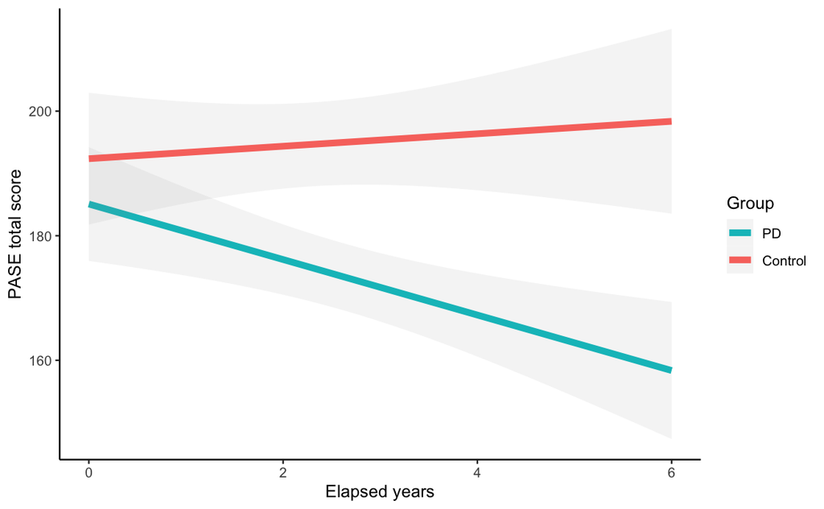

```r
UPDRS_PASE_MOCA_ESS_MSEADL_RBDSQ_SCOPA_HVLT_JLO_LNS_SDMT_GDS %>% dplyr::filter(Elapsed_months_2<=72) %>%
  ggplot(aes(x=Elapsed_months_2/12,y=PASE_Total_score,colour=Group)) + theme_classic() + stat_smooth(se=T,fullrange = T,level =
                                                                                                       0.95,method=lm,alpha=0.1,size=2)+
  xlab("Elapsed years")+ylab("PASE total score")+scale_colour_discrete(name="")+scale_color_manual(values = c("#00BFC4","#F8766D"))
```

We created Fig.1B using following codes.

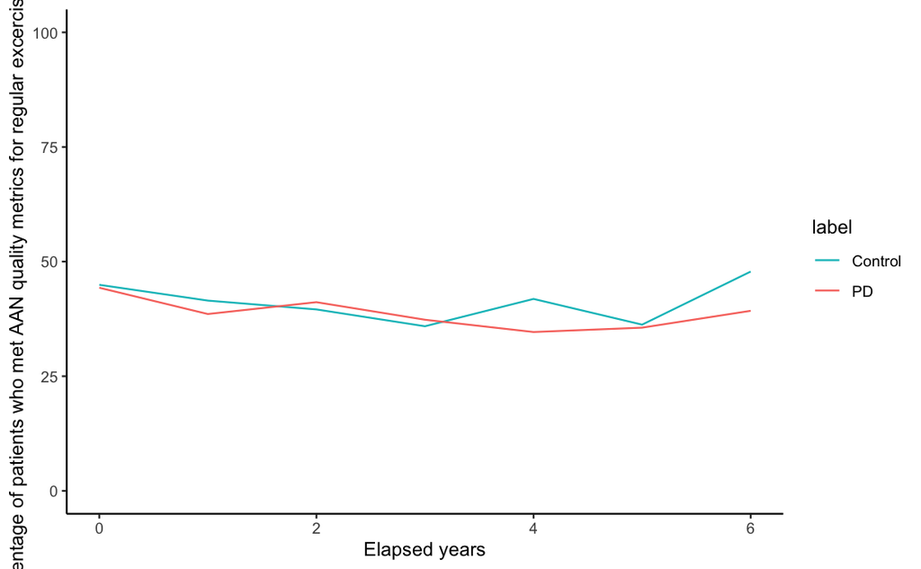

```r
UPDRS_PASE_MOCA_ESS_MSEADL_RBDSQ_SCOPA_HVLT_JLO_LNS_SDMT_GDS %>% dplyr::filter(Group=="Control") %>% dplyr::filter(Elapsed_months_2<=72) %>% group_by(Elapsed_months_2) %>% dplyr::mutate(perc=100*sum(AAN_criteria=="Meet")/sum(is.na(AAN_criteria)==F)) ->f
UPDRS_PASE_MOCA_ESS_MSEADL_RBDSQ_SCOPA_HVLT_JLO_LNS_SDMT_GDS %>% dplyr::filter(Group=="PD") %>% dplyr::filter(Elapsed_months_2<=72) %>% group_by(Elapsed_months_2) %>% dplyr::mutate(perc=100*sum(AAN_criteria=="Meet")/sum(is.na(AAN_criteria)==F))->g
data.frame(label=c(rep("Control",7),rep("PD",7)),prec=c(unique(f$perc),unique(g$perc)),yr=c(seq(0,6),seq(0,6))) %>% ggplot(aes(x=yr,y=prec,colour=label))+geom_line()+theme_classic()+ylim(0,100)+xlab("Elapsed years")+ylab("Percentage of patients who met AAN quality metrics for regular excercise regimen")+scale_color_manual(values = c("#00BFC4","#F8766D"))
```

The first half of results for the section “Clinical characteristics of PD patients” can be obtained with the following code.

```r
summary_trend<-UPDRS_PASE_MOCA_ESS_MSEADL_RBDSQ_SCOPA_HVLT_JLO_LNS_SDMT_GDS %>% dplyr::filter((Elapsed_months_2<=72)&(Group=="PD")) %>%
  dplyr::mutate(Elapsed_months_3=Elapsed_months_2/12) %>% with(lm(PASE_Total_score~Elapsed_months_3)) %>% summary()

summry_spearman<-UPDRS_PASE_MOCA_ESS_MSEADL_RBDSQ_SCOPA_HVLT_JLO_LNS_SDMT_GDS %>% dplyr::filter((Elapsed_months_2<=72)&(Group=="PD")) %>%
  with(cor.test(PASE_Total_score,Elapsed_months_2,method="spearman")) %>% suppressWarnings()

summry_spearmanCI<-UPDRS_PASE_MOCA_ESS_MSEADL_RBDSQ_SCOPA_HVLT_JLO_LNS_SDMT_GDS %>% dplyr::filter((Elapsed_months_2<=72)&(Group=="PD")) %>%
  with(spearmanCI(PASE_Total_score,Elapsed_months_2)) %>% capture.output()
summry_spearmanCI<-summry_spearmanCI[3] %>% str_split(pattern=" ")
summry_spearmanCI[[1]]->summry_spearmanCI
append(summry_spearmanCI[2],summry_spearmanCI[3]) %>% as.numeric()->summry_spearmanCI

paste("During the follow-up period, overall regular physical activity level of PD patients gradually decreased with the PASE total score decreasing by ",as.character(round(summary_trend$coefficients[2,][1],2))," points per year [95% CI,",as.character(round(summary_trend$coefficients[2,][1]-1.96*summary_trend$coefficients[2,][2],2))," to ",as.character(round(summary_trend$coefficients[2,][1]+1.96*summary_trend$coefficients[2,][2],2)),"; Spearman’s rho = ",round(summry_spearman$estimate,2), "(95% CI, ", round(summry_spearmanCI[1],2)," to ",round(summry_spearmanCI[1],2), "), P = ", round(summry_spearman$p.value,3),")]",sep="")
```

```
[1] "During the follow-up period, overall regular physical activity level of PD patients gradually decreased with the PASE total score decreasing by -4.46 points per year [95% CI,-7.28 to -1.63; Spearman’s rho = -0.08(95% CI, -0.14 to -0.14), P = 0.002)]"
```

The second half of results for the section “Clinical characteristics of PD patients” can be obtained with the following code.

```r
summary_trend<-UPDRS_PASE_MOCA_ESS_MSEADL_RBDSQ_SCOPA_HVLT_JLO_LNS_SDMT_GDS %>% dplyr::filter((Elapsed_months_2<=72)&(Group=="Control")) %>%
  dplyr::mutate(Elapsed_months_3=Elapsed_months_2/12) %>% with(lm(PASE_Total_score~Elapsed_months_3)) %>% summary()

summry_spearman<-UPDRS_PASE_MOCA_ESS_MSEADL_RBDSQ_SCOPA_HVLT_JLO_LNS_SDMT_GDS %>% dplyr::filter((Elapsed_months_2<=72)&(Group=="Control")) %>%
  with(cor.test(PASE_Total_score,Elapsed_months_2,method="spearman")) %>% suppressWarnings()

summry_spearmanCI<-UPDRS_PASE_MOCA_ESS_MSEADL_RBDSQ_SCOPA_HVLT_JLO_LNS_SDMT_GDS %>% dplyr::filter((Elapsed_months_2<=72)&(Group=="Control")) %>%
  with(spearmanCI(PASE_Total_score,Elapsed_months_2)) %>% capture.output()
summry_spearmanCI<-summry_spearmanCI[3] %>% str_split(pattern=" ")
summry_spearmanCI[[1]]->summry_spearmanCI
append(summry_spearmanCI[2],summry_spearmanCI[3]) %>% as.numeric()->summry_spearmanCI

paste("no significant change was observed longitudinally in HCs [Spearman’s rho = ",round(summry_spearman$estimate,2), " (95% CI, ", round(summry_spearmanCI[1],2)," to ",round(summry_spearmanCI[1],2), "), P = ", round(summry_spearman$p.value,3),"]",sep="")
```

```
[1] "no significant change was observed longitudinally in HCs [Spearman’s rho = 0.04 (95% CI, -0.03 to -0.03), P = 0.261]"
```

```r
summary_trend<-UPDRS_PASE_MOCA_ESS_MSEADL_RBDSQ_SCOPA_HVLT_JLO_LNS_SDMT_GDS %>% dplyr::filter((Elapsed_months_2<=72)&(Group=="PD")) %>%
  with(cor.test(AE,Elapsed_months_2,method="spearman"))%>% suppressWarnings()

summry_spearmanCI<-UPDRS_PASE_MOCA_ESS_MSEADL_RBDSQ_SCOPA_HVLT_JLO_LNS_SDMT_GDS %>% dplyr::filter((Elapsed_months_2<=72)&(Group=="PD")) %>%
  with(spearmanCI(AE,Elapsed_months_2)) %>% capture.output()
summry_spearmanCI<-summry_spearmanCI[3] %>% str_split(pattern=" ")
summry_spearmanCI[[1]]->summry_spearmanCI
append(summry_spearmanCI[2],summry_spearmanCI[3]) %>% as.numeric()->summry_spearmanCI


summary_trend_NCs<-UPDRS_PASE_MOCA_ESS_MSEADL_RBDSQ_SCOPA_HVLT_JLO_LNS_SDMT_GDS %>% dplyr::filter((Elapsed_months_2<=72)&(Group=="Control")) %>% with(cor.test(AE,Elapsed_months_2,method="spearman"))%>% suppressWarnings()

summry_spearmanCI_NCs<-UPDRS_PASE_MOCA_ESS_MSEADL_RBDSQ_SCOPA_HVLT_JLO_LNS_SDMT_GDS %>% dplyr::filter((Elapsed_months_2<=72)&(Group=="Control")) %>%
  with(spearmanCI(AE,Elapsed_months_2)) %>% capture.output()
summry_spearmanCI_NCs<-summry_spearmanCI_NCs[3] %>% str_split(pattern=" ")
summry_spearmanCI_NCs[[1]]->summry_spearmanCI_NCs
append(summry_spearmanCI_NCs[2],summry_spearmanCI_NCs[3]) %>% as.numeric()->summry_spearmanCI_NCs

paste("Moderate-to-vigorous exercise levels showed a decreasing trend in both PD patients and HCs, but this trend did not reach statistical significance [PD, Spearman’s rho = ",round(summary_trend$estimate,2)," (95% CI, ",round(summry_spearmanCI[1],2)," to ",round(summry_spearmanCI[2],2),"), P = ",round(summary_trend$p.value,2),"; HCs, Spearman’s rho = ",round(summary_trend_NCs$estimate,2)," (95% CI, ",round(summry_spearmanCI_NCs[2],2)," to ",round(summry_spearmanCI[2],2),"), P = ",round(summary_trend_NCs$p.value,2),"].",sep="")
```

```
[1] "Moderate-to-vigorous exercise levels showed a decreasing trend in both PD patients and HCs, but this trend did not reach statistical significance [PD, Spearman’s rho = -0.04 (95% CI, -0.09 to 0.02), P = 0.16; HCs, Spearman’s rho = -0.04 (95% CI, 0.04 to 0.02), P = 0.34]."
```

We created Table2 using the following code.

```r
a<-UPDRS_PASE_MOCA_ESS_MSEADL_RBDSQ_SCOPA_HVLT_JLO_LNS_SDMT_GDS %>% dplyr::filter((Group=="PD")&(Elapsed_months_2<=72)) %>% dplyr::mutate(Elapsed_months_3=Elapsed_months_2/12) %>% dplyr::select(Elapsed_months_3,Age,Sex,Disease_duration_symptom,NHY,LEDD_sum,PASE_Leisure_score,PASE_Household_score,PASE_Work_score,PASE_Total_score,AE,AAN_criteria,sum_UPDRS_part3,sum_Tremor_score,sum_PIGD_score,MOCA_Total_score,HVLT_DELAYED_RECALL_T,JLO_RAW,LNS_RAW,SDMT_correct,SCOPA_total_score,GDS_total_score, ESS_total_score,RBDSQ_total_score,MSEADLG)
colnames(a)<-c("Elapsed years","Age","Sex","Duration from symptom onset","Hoen Yahr stage","Levodopa equivalent dose","PASE leisure score","PASE household score","PASE work score","PASE total score","Aerobic Excercise","AAN criteria","MDS-UPDRS part3 score","MDS-UPDRS tremor subscore","MDS-UPDRS PIGD subscore","MOCA total score","HVLT delayed recall T score","JLO total score","LNS total score","SDMT total score","SCOPA-AUT total score","GDS total score", "ESS total score","RBDSQ total score","MSE percent ADLscore")
a %>% gtsummary::tbl_summary(by = `Elapsed years`,digits = list(all_continuous() ~ 1,all_categorical() ~ 1),type=list(`Hoen Yahr stage`~"continuous",`MSE percent ADLscore`~"continuous",`Duration from symptom onset`~"continuous")) %>% suppressMessages()
```

| **Characteristic** | **0**, N = 237<sup>1</sup> | **1**, N = 223<sup>1</sup> | **2**, N = 226<sup>1</sup> | **3**, N = 209<sup>1</sup> | **4**, N = 191<sup>1</sup> | **5**, N = 153<sup>1</sup> | **6**, N = 118<sup>1</sup> |
| --- | --- | --- | --- | --- | --- | --- | --- |
| Age | 63.0 (56.0, 70.0) | 64.0 (57.0, 71.0) | 65.0 (58.0, 72.8) | 66.0 (59.0, 73.0) | 67.0 (59.5, 74.0) | 68.0 (61.0, 74.0) | 69.0 (62.0, 75.0) |
| Sex |  |  |  |  |  |  |  |
| Female | 73.0 (30.8%) | 71.0 (31.8%) | 73.0 (32.3%) | 65.0 (31.1%) | 56.0 (29.3%) | 46.0 (30.1%) | 33.0 (28.0%) |
| Male | 164.0 (69.2%) | 152.0 (68.2%) | 153.0 (67.7%) | 144.0 (68.9%) | 135.0 (70.7%) | 107.0 (69.9%) | 85.0 (72.0%) |
| Duration from symptom onset | 3.0 (3.0, 5.0) | 4.0 (3.5, 6.0) | 5.0 (5.0, 6.0) | 6.0 (5.0, 7.0) | 7.0 (6.0, 9.0) | 8.0 (7.0, 9.0) | 9.0 (8.0, 10.0) |
| Hoen Yahr stage | 2.0 (1.0, 2.0) | 2.0 (2.0, 2.0) | 2.0 (2.0, 2.0) | 2.0 (2.0, 2.0) | 2.0 (2.0, 2.0) | 2.0 (2.0, 2.0) | 2.0 (2.0, 2.0) |
| Unknown | 0 | 20 | 34 | 29 | 26 | 19 | 15 |
| Levodopa equivalent dose | 100.0 (0.0, 300.0) | 200.0 (100.0, 400.0) | 300.0 (100.0, 450.0) | 300.0 (140.0, 600.0) | 333.0 (160.0, 625.0) | 300.0 (150.0, 700.0) | 400.0 (199.6, 701.3) |
| PASE leisure score | 49.0 (17.8, 92.6) | 48.1 (22.6, 78.1) | 52.9 (17.8, 87.3) | 52.9 (17.6, 91.6) | 42.8 (17.6, 105.4) | 45.5 (17.8, 77.6) | 47.4 (17.6, 79.2) |
| PASE household score | 86.0 (50.0, 121.0) | 85.0 (50.0, 115.5) | 85.0 (50.0, 116.0) | 85.0 (50.0, 116.0) | 85.0 (50.0, 115.0) | 80.0 (50.0, 116.0) | 80.0 (50.0, 106.0) |
| PASE work score | 0.0 (0.0, 48.0) | 0.0 (0.0, 27.0) | 0.0 (0.0, 12.0) | 0.0 (0.0, 9.0) | 0.0 (0.0, 12.0) | 0.0 (0.0, 0.0) | 0.0 (0.0, 0.0) |
| PASE total score | 175.0 (110.5, 250.5) | 159.9 (106.4, 235.0) | 158.2 (106.7, 232.0) | 154.2 (102.6, 227.1) | 156.3 (103.6, 233.2) | 142.2 (87.4, 205.9) | 148.7 (87.6, 201.5) |
| Aerobic Excercise | 0.1 (0.0, 0.8) | 0.1 (0.0, 0.8) | 0.1 (0.0, 0.8) | 0.1 (0.0, 0.8) | 0.1 (0.0, 0.8) | 0.0 (0.0, 0.8) | 0.1 (0.0, 0.6) |
| AAN criteria |  |  |  |  |  |  |  |
| Meet | 105.0 (44.3%) | 86.0 (38.6%) | 93.0 (41.2%) | 78.0 (37.3%) | 75.0 (39.3%) | 53.0 (34.6%) | 42.0 (35.6%) |
| Not | 132.0 (55.7%) | 137.0 (61.4%) | 133.0 (58.8%) | 131.0 (62.7%) | 116.0 (60.7%) | 100.0 (65.4%) | 76.0 (64.4%) |
| MDS-UPDRS part3 score | 25.0 (18.0, 34.0) | 26.0 (20.0, 35.0) | 31.0 (22.0, 38.0) | 32.0 (23.0, 40.0) | 33.0 (27.0, 42.0) | 34.5 (23.2, 45.0) | 38.0 (27.2, 49.0) |
| Unknown | 0 | 20 | 35 | 29 | 26 | 19 | 16 |
| MDS-UPDRS tremor subscore | 6.0 (3.0, 10.0) | 6.0 (3.0, 10.0) | 8.0 (4.0, 11.0) | 7.0 (3.0, 10.0) | 7.0 (3.0, 11.0) | 7.5 (3.0, 11.0) | 7.0 (4.5, 13.5) |
| Unknown | 0 | 20 | 34 | 28 | 26 | 19 | 15 |
| MDS-UPDRS PIGD subscore | 1.0 (1.0, 2.0) | 2.0 (1.0, 2.0) | 2.0 (1.0, 2.0) | 2.0 (1.0, 3.0) | 2.0 (1.0, 4.0) | 2.0 (2.0, 4.8) | 3.0 (2.0, 5.0) |
| Unknown | 0 | 20 | 35 | 29 | 26 | 19 | 16 |
| MOCA total score | 27.0 (25.0, 29.0) | 27.0 (25.0, 29.0) | 27.0 (25.0, 29.0) | 27.0 (25.0, 29.0) | 27.0 (25.0, 29.0) | 27.0 (25.0, 29.0) | 27.0 (25.0, 29.0) |
| Unknown | 0 | 3 | 2 | 1 | 3 | 3 | 1 |
| HVLT delayed recall T score | 45.0 (37.0, 55.0) | 46.0 (38.0, 55.0) | 50.0 (39.0, 56.0) | 51.0 (40.0, 59.0) | 50.0 (37.0, 56.0) | 48.0 (37.0, 56.0) | 45.0 (35.0, 55.0) |
| Unknown | 0 | 1 | 1 | 2 | 2 | 2 | 2 |
| JLO total score | 26.0 (23.5, 28.0) | 28.0 (24.0, 28.0) | 26.0 (24.0, 30.0) | 27.0 (24.0, 30.0) | 26.0 (24.0, 28.0) | 26.0 (22.0, 28.0) | 26.0 (22.0, 28.0) |
| Unknown | 1 | 1 | 4 | 5 | 4 | 3 | 3 |
| LNS total score | 11.0 (9.0, 12.0) | 10.0 (9.0, 12.0) | 10.0 (9.0, 12.0) | 10.0 (8.0, 12.0) | 10.0 (8.0, 12.0) | 10.0 (8.0, 11.5) | 10.0 (8.0, 12.0) |
| Unknown | 0 | 0 | 1 | 1 | 2 | 2 | 2 |
| SDMT total score | 42.0 (35.0, 48.0) | 41.0 (35.0, 48.0) | 42.0 (33.0, 49.0) | 41.0 (33.0, 47.0) | 41.0 (33.8, 48.0) | 38.5 (30.2, 46.8) | 38.0 (28.8, 45.0) |
| Unknown | 0 | 1 | 2 | 0 | 3 | 3 | 2 |
| SCOPA-AUT total score | 13.0 (7.0, 20.0) | 14.0 (8.0, 20.0) | 14.0 (9.0, 22.8) | 13.0 (8.0, 22.0) | 16.0 (10.0, 23.8) | 18.0 (11.0, 26.0) | 18.0 (13.0, 26.0) |
| Unknown | 1 | 0 | 0 | 0 | 1 | 0 | 1 |
| GDS total score | 5.0 (5.0, 6.0) | 5.0 (5.0, 6.0) | 5.0 (5.0, 6.0) | 5.0 (5.0, 6.0) | 5.0 (5.0, 7.0) | 5.0 (5.0, 7.0) | 5.0 (5.0, 7.0) |
| Unknown | 1 | 0 | 0 | 0 | 0 | 0 | 0 |
| ESS total score | 6.0 (4.0, 9.0) | 6.0 (4.0, 9.0) | 6.0 (4.0, 10.0) | 6.0 (4.0, 11.0) | 6.0 (4.0, 10.5) | 7.0 (4.0, 11.0) | 7.0 (5.0, 10.8) |
| Unknown | 0 | 3 | 0 | 0 | 0 | 0 | 0 |
| RBDSQ total score | 5.0 (3.0, 7.0) | 5.0 (3.0, 8.0) | 5.0 (3.0, 8.0) | 5.0 (3.0, 8.0) | 6.0 (4.0, 9.0) | 7.0 (4.0, 9.0) | 7.0 (4.0, 10.0) |
| Unknown | 0 | 0 | 2 | 0 | 1 | 0 | 0 |
| MSE percent ADLscore | 90.0 (85.0, 95.0) | 90.0 (80.0, 90.0) | 90.0 (80.0, 90.0) | 90.0 (80.0, 90.0) | 90.0 (80.0, 90.0) | 80.0 (80.0, 90.0) | 80.0 (80.0, 90.0) |
| Unknown | 1 | 0 | 1 | 0 | 2 | 0 | 0 |

<sup>*1*</sup> Median (IQR); n (%)

We created eTable1 using the following code.

```r
a<-UPDRS_PASE_MOCA_ESS_MSEADL_RBDSQ_SCOPA_HVLT_JLO_LNS_SDMT_GDS %>% dplyr::filter((Group=="PD")&(Elapsed_months_2<=72)) %>% dplyr::mutate(Elapsed_months_3=Elapsed_months_2/12) %>% dplyr::select(PATNO,ORIG_ENTRY,Elapsed_months_3,Age,Sex,Disease_duration_symptom,NHY,LEDD_sum,PASE_Leisure_score,PASE_Household_score,PASE_Work_score,PASE_Total_score,AE,AAN_criteria,sum_UPDRS_part3,sum_Tremor_score,sum_PIGD_score,MOCA_Total_score,HVLT_DELAYED_RECALL_T,JLO_RAW,LNS_RAW,SDMT_correct,SCOPA_total_score,GDS_total_score, ESS_total_score,RBDSQ_total_score,MSEADLG)
colnames(a)<-c("PATNO","Final visit","Elapsed years","Age","Sex","Duration from symptom onset","Hoen Yahr stage","Levodopa equivalent dose","PASE leisure score","PASE household score","PASE work score","PASE total score","Aerobic Excercise","AAN criteria","MDS-UPDRS part3 score","MDS-UPDRS tremor subscore","MDS-UPDRS PIGD subscore","MOCA total score","HVLT delayed recall T score","JLO total score","LNS total score","SDMT total score","SCOPA-AUT total score","GDS total score", "ESS total score","RBDSQ total score","MSE percent ADLscore")

max_follow.up<-c();PATNO<-c();Final.visit<-c()
for (i in unique(a$PATNO)){
  a %>% dplyr::filter(PATNO==i) ->a1;
  max_follow.up<-append(max_follow.up,max(a1$`Elapsed years`));
  PATNO<-append(PATNO,i);difftime(min(a1$`Final visit`),Sys.Date()) %>% as.numeric->b1
  Final.visit<-append(Final.visit,b1)
}

a<-data.frame(PATNO=PATNO,follow.max=max_follow.up,Baseline=Final.visit) %>% as_tibble() %>% dplyr::mutate(follow=if_else(follow.max>=6,"follow up for 6 years","follow up for 5 years or less")) %>% dplyr::select(PATNO,follow,Baseline) %>% dplyr::right_join(a,by="PATNO") %>%dplyr::filter(`Elapsed years`==0)
rm(PATNO,max_follow.up)
a %>% dplyr::select(-c(`Final visit`,PATNO,`Elapsed years`)) %>% gtsummary::tbl_summary(by = follow,digits = all_continuous() ~ 1,type=list(`Hoen Yahr stage`~"continuous",`MSE percent ADLscore`~"continuous",`Duration from symptom onset`~"continuous",`MDS-UPDRS PIGD subscore`~"continuous")) %>% add_p()
```

| **Characteristic** | **follow up for 5 years or less**, N = 119<sup>1</sup> | **follow up for 6 years**, N = 118<sup>1</sup> | **p-value**<sup>2</sup> |
| --- | --- | --- | --- |
| Baseline | -2,732.4 (-2,854.4, -2,563.9) | -3,066.4 (-3,127.4, -2,944.4) | <0.001 |
| Age | 64.0 (56.0, 72.0) | 63.0 (56.0, 69.0) | 0.22 |
| Sex |  |  | 0.35 |
| Female | 40 (34%) | 33 (28%) |  |
| Male | 79 (66%) | 85 (72%) |  |
| Duration from symptom onset | 4.0 (3.0, 5.0) | 3.0 (2.0, 4.0) | 0.025 |
| Hoen Yahr stage | 2.0 (1.5, 2.0) | 2.0 (1.0, 2.0) | 0.42 |
| Levodopa equivalent dose | 100.0 (0.0, 300.0) | 100.0 (0.0, 236.2) | 0.54 |
| PASE leisure score | 48.1 (18.4, 107.6) | 50.4 (17.8, 77.0) | 0.49 |
| PASE household score | 85.0 (50.0, 121.0) | 86.0 (51.2, 116.0) | 0.73 |
| PASE work score | 0.0 (0.0, 24.0) | 0.0 (0.0, 60.0) | 0.92 |
| PASE total score | 183.1 (110.4, 257.2) | 162.6 (111.5, 249.4) | 0.81 |
| Aerobic Excercise | 0.2 (0.0, 0.8) | 0.1 (0.0, 0.8) | 0.89 |
| AAN criteria |  |  | 0.94 |
| Meet | 53 (45%) | 52 (44%) |  |
| Not | 66 (55%) | 66 (56%) |  |
| MDS-UPDRS part3 score | 25.0 (18.0, 34.0) | 26.0 (19.0, 33.8) | 0.89 |
| MDS-UPDRS tremor subscore | 5.0 (2.5, 9.0) | 7.0 (4.0, 10.0) | 0.035 |
| MDS-UPDRS PIGD subscore | 1.0 (1.0, 2.0) | 1.0 (1.0, 2.0) | 0.65 |
| MOCA total score | 27.0 (24.0, 29.0) | 27.0 (25.0, 28.0) | 0.92 |
| HVLT delayed recall T score | 44.0 (36.0, 53.0) | 47.0 (38.0, 55.0) | 0.11 |
| JLO total score | 26.0 (22.0, 28.0) | 28.0 (24.0, 28.0) | 0.20 |
| Unknown | 1 | 0 |  |
| LNS total score | 11.0 (9.0, 12.0) | 11.0 (9.0, 12.0) | 0.71 |
| SDMT total score | 42.0 (35.0, 48.0) | 42.0 (35.0, 48.0) | 0.95 |
| SCOPA-AUT total score | 13.0 (7.0, 19.8) | 13.0 (9.0, 20.0) | 0.67 |
| Unknown | 1 | 0 |  |
| GDS total score | 5.0 (5.0, 6.0) | 5.0 (5.0, 6.0) | 0.53 |
| Unknown | 1 | 0 |  |
| ESS total score | 6.0 (4.0, 10.0) | 5.5 (4.0, 7.0) | 0.24 |
| RBDSQ total score | 5.0 (3.0, 7.0) | 5.0 (3.0, 7.0) | 0.88 |
| MSE percent ADLscore | 90.0 (86.2, 95.0) | 90.0 (81.2, 90.0) | 0.10 |
| Unknown | 1 | 0 |  |

<sup>*1*</sup> Median (IQR); n (%) <sup>*2*</sup> Wilcoxon rank sum test; Pearson's Chi-squared test

At the table above, the difference in baseline dates were expressed as the time from today to the baseline dates, therefore, we change these values to “baseline date”.

```r
a %>% dplyr::filter(follow=="follow up for 5 years or less")->short
short$Baseline %>% quantile() -> short
Sys.Date()+short->short

a %>% dplyr::filter(follow=="follow up for 6 years")->long
long$Baseline %>% quantile() -> long
Sys.Date()+long->long

paste("Baseline dates, ",short[3]," (",short[2],"–",short[4],") (follow up for 6 years) vs. ",long[3]," (",long[2],"–",long[4],") (follow up for 5 years or less)")
```

[output not shown]

## Main result (1): the interaction effect between regular physical activity levels at the baseline and clinical progression.

After the following code, **“interaction_effect_table_baseline_final.csv”** will be obtained, and this csv includes the fist half of the main result. Fig.2A is also created using the following code. Fig.2A is also created using the following code.

```r
###Interaction with baseline_PASE_Total_score, adjusted for Age, LEDD, Disease duration, Sex
UPDRS_PASE_MOCA_ESS_MSEADL_RBDSQ_SCOPA_HVLT_JLO_LNS_SDMT_GDS_PD<-UPDRS_PASE_MOCA_ESS_MSEADL_RBDSQ_SCOPA_HVLT_JLO_LNS_SDMT_GDS %>% filter(Group=="PD")
c<-c()
for(i in unique(UPDRS_PASE_MOCA_ESS_MSEADL_RBDSQ_SCOPA_HVLT_JLO_LNS_SDMT_GDS_PD$PATNO)){
  UPDRS_PASE_MOCA_ESS_MSEADL_RBDSQ_SCOPA_HVLT_JLO_LNS_SDMT_GDS_PD %>% filter(PATNO==i) -> a;
  append(c,rep(a$PASE_Total_score[1],nrow(a)))->c
}
c->baseline_PASE_Total_score
UPDRS_PASE_MOCA_ESS_MSEADL_RBDSQ_SCOPA_HVLT_JLO_LNS_SDMT_GDS_PD<-cbind(UPDRS_PASE_MOCA_ESS_MSEADL_RBDSQ_SCOPA_HVLT_JLO_LNS_SDMT_GDS_PD,baseline_PASE_Total_score) %>% as_tibble()

a<-UPDRS_PASE_MOCA_ESS_MSEADL_RBDSQ_SCOPA_HVLT_JLO_LNS_SDMT_GDS_PD %>% dplyr::select(PATNO,Sex,Elapsed_months_2,baseline_PASE_Total_score,Age,LEDD_sum,sum_UPDRS_part3,sum_Tremor_score,sum_PIGD_score,MOCA_Total_score,HVLT_DELAYED_RECALL_T,JLO_RAW,LNS_RAW,SDMT_correct,SCOPA_total_score,GDS_total_score, ESS_total_score,RBDSQ_total_score,MSEADLG,Disease_duration_symptom)
Partner<-c()
c<-c()
for(i in colnames(a)){
  if((i!="Elapsed_months_2")&(i!="baseline_PASE_Total_score")&(i!="Age")&(i!="PATNO")&(i!="LEDD_sum")&(i!="Disease_duration_symptom")&(i!="Sex")){
    a %>% dplyr::select(i,Elapsed_months_2,baseline_PASE_Total_score,Age,PATNO,LEDD_sum,Disease_duration_symptom,Sex)->a1;
    colnames(a1)<-c("V1","Elapsed_months_2","baseline_PASE_Total_score","Age","PATNO","LEDD_sum","Disease_duration_symptom","Sex");
    a1$V1<-scale(a1$V1,center=T,scale=T);
    a1$baseline_PASE_Total_score<-scale(a1$baseline_PASE_Total_score,center=T,scale=T);
    a1$Age<-scale(a1$Age,center=T,scale=T);
    a1$Elapsed_months_2<-scale(a1$Elapsed_months_2,center=T,scale=T);
    a1$LEDD_sum<-scale(a1$LEDD_sum,center=T,scale=T);
    a1$Disease_duration_symptom<-scale(a1$Disease_duration_symptom,center=T,scale=T);
    with(a1,lmer(V1~Elapsed_months_2*baseline_PASE_Total_score+Age+LEDD_sum+Disease_duration_symptom+Sex+(1+Elapsed_months_2|PATNO),REML=FALSE))->b;
    summary(b)->b.summary;confint(b,method="b",nsim=1000) %>% suppressMessages()->b.confint;
    b.summary$coefficients[8,]->e;b.confint[10,]->f;b.summary$AICtab[1:2]->A.BIC
    with(a1,lmer(V1~Elapsed_months_2+baseline_PASE_Total_score+Age+LEDD_sum+Disease_duration_symptom+Sex+(1+Elapsed_months_2|PATNO),REML=FALSE))->b.null;
    anova(b,b.null)->d;summary(b.null)->d.summary;d.summary$AICtab[1:2]-b.summary$AICtab[1:2]->A.BIC
    c(e[1],e[2],e[3],f[1],f[2],d$`Pr(>Chisq)`[2]*65,A.BIC)->d;
    bind_rows(c,d) %>% suppressMessages()->c;
    append(Partner,i)->Partner
  }}
colnames(c)[6]<-"p.value"
cbind(Partner,c)->interaction_effect_table_baseline_PASE_Total_score
interaction_effect_table_baseline_PASE_Total_score <-interaction_effect_table_baseline_PASE_Total_score %>% mutate(significance=if_else(`p.value`<=0.05,"Significant","Not"))
interaction_effect_table_baseline_PASE_Total_score <-cbind(interaction_effect_table_baseline_PASE_Total_score,class=rep("baseline_PASE_Total_score",nrow(interaction_effect_table_baseline_PASE_Total_score )))


###Interaction with baseline_PASE_Leisure_score, adjusted for Age, LEDD, Disease duration, Sex
c<-c()
for(i in unique(UPDRS_PASE_MOCA_ESS_MSEADL_RBDSQ_SCOPA_HVLT_JLO_LNS_SDMT_GDS_PD$PATNO)){
  UPDRS_PASE_MOCA_ESS_MSEADL_RBDSQ_SCOPA_HVLT_JLO_LNS_SDMT_GDS_PD %>% filter(PATNO==i) -> a;
  append(c,rep(a$PASE_Leisure_score[1],nrow(a)))->c
}
c->baseline_PASE_Leisure_score
UPDRS_PASE_MOCA_ESS_MSEADL_RBDSQ_SCOPA_HVLT_JLO_LNS_SDMT_GDS_PD<-cbind(UPDRS_PASE_MOCA_ESS_MSEADL_RBDSQ_SCOPA_HVLT_JLO_LNS_SDMT_GDS_PD,baseline_PASE_Leisure_score) %>% as_tibble()

a<-UPDRS_PASE_MOCA_ESS_MSEADL_RBDSQ_SCOPA_HVLT_JLO_LNS_SDMT_GDS_PD %>% dplyr::select(PATNO,Sex,Elapsed_months_2,baseline_PASE_Leisure_score,Age,LEDD_sum,sum_UPDRS_part3,sum_Tremor_score,sum_PIGD_score,MOCA_Total_score,HVLT_DELAYED_RECALL_T,JLO_RAW,LNS_RAW,SDMT_correct,SCOPA_total_score,GDS_total_score, ESS_total_score,RBDSQ_total_score,MSEADLG,Disease_duration_symptom)
Partner<-c()
c<-c()
for(i in colnames(a)){
  if((i!="Elapsed_months_2")&(i!="baseline_PASE_Leisure_score")&(i!="Age")&(i!="PATNO")&(i!="LEDD_sum")&(i!="Disease_duration_symptom")&(i!="Sex")){
    a %>% dplyr::select(i,Elapsed_months_2,baseline_PASE_Leisure_score,Age,PATNO,LEDD_sum,Disease_duration_symptom,Sex)->a1;
    colnames(a1)<-c("V1","Elapsed_months_2","baseline_PASE_Leisure_score","Age","PATNO","LEDD_sum","Disease_duration_symptom","Sex");
    a1$V1<-scale(a1$V1,center=T,scale=T);
    a1$baseline_PASE_Leisure_score<-scale(a1$baseline_PASE_Leisure_score,center=T,scale=T);
    a1$Age<-scale(a1$Age,center=T,scale=T);
    a1$Elapsed_months_2<-scale(a1$Elapsed_months_2,center=T,scale=T);
    a1$LEDD_sum<-scale(a1$LEDD_sum,center=T,scale=T);
    a1$Disease_duration_symptom<-scale(a1$Disease_duration_symptom,center=T,scale=T);
    with(a1,lmer(V1~Elapsed_months_2*baseline_PASE_Leisure_score+Age+LEDD_sum+Disease_duration_symptom+Sex+(1+Elapsed_months_2|PATNO),REML=FALSE))->b;
    summary(b)->b.summary;confint(b,method="b",nsim=1000) %>% suppressMessages()->b.confint;
    b.summary$coefficients[8,]->e;b.confint[10,]->f;b.summary$AICtab[1:2]->A.BIC
    with(a1,lmer(V1~Elapsed_months_2+baseline_PASE_Leisure_score+Age+LEDD_sum+Disease_duration_symptom+Sex+(1+Elapsed_months_2|PATNO),REML=FALSE))->b.null;
    anova(b,b.null)->d;summary(b.null)->d.summary;d.summary$AICtab[1:2]-b.summary$AICtab[1:2]->A.BIC
    c(e[1],e[2],e[3],f[1],f[2],d$`Pr(>Chisq)`[2]*65,A.BIC)->d;
    bind_rows(c,d) %>% suppressMessages()->c;
    append(Partner,i)->Partner
  }}
colnames(c)[6]<-"p.value"
cbind(Partner,c)->interaction_effect_table_baseline_PASE_Leisure_score
interaction_effect_table_baseline_PASE_Leisure_score <-interaction_effect_table_baseline_PASE_Leisure_score %>% mutate(significance=if_else(`p.value`<=0.05,"Significant","Not"))
interaction_effect_table_baseline_PASE_Leisure_score <-cbind(interaction_effect_table_baseline_PASE_Leisure_score,class=rep("baseline_PASE_Leisure_score",nrow(interaction_effect_table_baseline_PASE_Leisure_score )))
```

```r
##Interaction with baseline_PASE_Household_score, adjusted for Age, LEDD, Disease duration, Sex
c<-c()
for(i in unique(UPDRS_PASE_MOCA_ESS_MSEADL_RBDSQ_SCOPA_HVLT_JLO_LNS_SDMT_GDS_PD$PATNO)){
  UPDRS_PASE_MOCA_ESS_MSEADL_RBDSQ_SCOPA_HVLT_JLO_LNS_SDMT_GDS_PD %>% filter(PATNO==i) -> a;
  append(c,rep(a$PASE_Household_score[1],nrow(a)))->c
}
c->baseline_PASE_Household_score
UPDRS_PASE_MOCA_ESS_MSEADL_RBDSQ_SCOPA_HVLT_JLO_LNS_SDMT_GDS_PD<-cbind(UPDRS_PASE_MOCA_ESS_MSEADL_RBDSQ_SCOPA_HVLT_JLO_LNS_SDMT_GDS_PD,baseline_PASE_Household_score) %>% as_tibble()

a<-UPDRS_PASE_MOCA_ESS_MSEADL_RBDSQ_SCOPA_HVLT_JLO_LNS_SDMT_GDS_PD %>% dplyr::select(PATNO,Sex,Elapsed_months_2,baseline_PASE_Household_score,Age,LEDD_sum,sum_UPDRS_part3,sum_Tremor_score,sum_PIGD_score,MOCA_Total_score,HVLT_DELAYED_RECALL_T,JLO_RAW,LNS_RAW,SDMT_correct,SCOPA_total_score,GDS_total_score, ESS_total_score,RBDSQ_total_score,MSEADLG,Disease_duration_symptom)
Partner<-c()
c<-c()
for(i in colnames(a)){
  if((i!="Elapsed_months_2")&(i!="baseline_PASE_Household_score")&(i!="Age")&(i!="PATNO")&(i!="LEDD_sum")&(i!="Disease_duration_symptom")&(i!="Sex")){
    a %>% dplyr::select(i,Elapsed_months_2,baseline_PASE_Household_score,Age,PATNO,LEDD_sum,Disease_duration_symptom,Sex)->a1;
    colnames(a1)<-c("V1","Elapsed_months_2","baseline_PASE_Household_score","Age","PATNO","LEDD_sum","Disease_duration_symptom","Sex");
    a1$V1<-scale(a1$V1,center=T,scale=T);
    a1$baseline_PASE_Household_score<-scale(a1$baseline_PASE_Household_score,center=T,scale=T);
    a1$Age<-scale(a1$Age,center=T,scale=T);
    a1$Elapsed_months_2<-scale(a1$Elapsed_months_2,center=T,scale=T);
    a1$LEDD_sum<-scale(a1$LEDD_sum,center=T,scale=T);
    a1$Disease_duration_symptom<-scale(a1$Disease_duration_symptom,center=T,scale=T);
    with(a1,lmer(V1~Elapsed_months_2*baseline_PASE_Household_score+Age+LEDD_sum+Disease_duration_symptom+Sex+(1+Elapsed_months_2|PATNO),REML=FALSE))->b;
    summary(b)->b.summary;confint(b,method="b",nsim=1000) %>% suppressMessages()->b.confint;
    b.summary$coefficients[8,]->e;b.confint[10,]->f;b.summary$AICtab[1:2]->A.BIC
    with(a1,lmer(V1~Elapsed_months_2+baseline_PASE_Household_score+Age+LEDD_sum+Disease_duration_symptom+Sex+(1+Elapsed_months_2|PATNO),REML=FALSE))->b.null;
    anova(b,b.null)->d;summary(b.null)->d.summary;d.summary$AICtab[1:2]-b.summary$AICtab[1:2]->A.BIC
    c(e[1],e[2],e[3],f[1],f[2],d$`Pr(>Chisq)`[2]*65,A.BIC)->d;
    bind_rows(c,d) %>% suppressMessages()->c;
    append(Partner,i)->Partner
  }}
colnames(c)[6]<-"p.value"
cbind(Partner,c)->interaction_effect_table_baseline_PASE_Household_score
interaction_effect_table_baseline_PASE_Household_score <-interaction_effect_table_baseline_PASE_Household_score %>% mutate(significance=if_else(`p.value`<=0.05,"Significant","Not"))
interaction_effect_table_baseline_PASE_Household_score <-cbind(interaction_effect_table_baseline_PASE_Household_score,class=rep("baseline_PASE_Household_score",nrow(interaction_effect_table_baseline_PASE_Household_score )))


###Interaction with baseline_PASE_Work_score, adjusted for Age, LEDD, Disease duration, Sex
c<-c()
for(i in unique(UPDRS_PASE_MOCA_ESS_MSEADL_RBDSQ_SCOPA_HVLT_JLO_LNS_SDMT_GDS_PD$PATNO)){
  UPDRS_PASE_MOCA_ESS_MSEADL_RBDSQ_SCOPA_HVLT_JLO_LNS_SDMT_GDS_PD %>% filter(PATNO==i) -> a;
  append(c,rep(a$PASE_Work_score[1],nrow(a)))->c
}
c->baseline_PASE_Work_score
UPDRS_PASE_MOCA_ESS_MSEADL_RBDSQ_SCOPA_HVLT_JLO_LNS_SDMT_GDS_PD<-cbind(UPDRS_PASE_MOCA_ESS_MSEADL_RBDSQ_SCOPA_HVLT_JLO_LNS_SDMT_GDS_PD,baseline_PASE_Work_score) %>% as_tibble()

a<-UPDRS_PASE_MOCA_ESS_MSEADL_RBDSQ_SCOPA_HVLT_JLO_LNS_SDMT_GDS_PD %>% dplyr::select(PATNO,Sex,Elapsed_months_2,baseline_PASE_Work_score,Age,LEDD_sum,sum_UPDRS_part3,sum_Tremor_score,sum_PIGD_score,MOCA_Total_score,HVLT_DELAYED_RECALL_T,JLO_RAW,LNS_RAW,SDMT_correct,SCOPA_total_score,GDS_total_score, ESS_total_score,RBDSQ_total_score,MSEADLG,Disease_duration_symptom)
Partner<-c()
c<-c()
for(i in colnames(a)){
  if((i!="Elapsed_months_2")&(i!="baseline_PASE_Work_score")&(i!="Age")&(i!="PATNO")&(i!="LEDD_sum")&(i!="Disease_duration_symptom")&(i!="Sex")){
    a %>% dplyr::select(i,Elapsed_months_2,baseline_PASE_Work_score,Age,PATNO,LEDD_sum,Disease_duration_symptom,Sex)->a1;
    colnames(a1)<-c("V1","Elapsed_months_2","baseline_PASE_Work_score","Age","PATNO","LEDD_sum","Disease_duration_symptom","Sex");
    a1$V1<-scale(a1$V1,center=T,scale=T);
    a1$baseline_PASE_Work_score<-scale(a1$baseline_PASE_Work_score,center=T,scale=T);
    a1$Age<-scale(a1$Age,center=T,scale=T);
    a1$Elapsed_months_2<-scale(a1$Elapsed_months_2,center=T,scale=T);
    a1$LEDD_sum<-scale(a1$LEDD_sum,center=T,scale=T);
    a1$Disease_duration_symptom<-scale(a1$Disease_duration_symptom,center=T,scale=T);
    with(a1,lmer(V1~Elapsed_months_2*baseline_PASE_Work_score+Age+LEDD_sum+Disease_duration_symptom+Sex+(1+Elapsed_months_2|PATNO),REML=FALSE))->b;
    summary(b)->b.summary;confint(b,method="b",nsim=1000) %>% suppressMessages()->b.confint;
    b.summary$coefficients[8,]->e;b.confint[10,]->f;b.summary$AICtab[1:2]->A.BIC
    with(a1,lmer(V1~Elapsed_months_2+baseline_PASE_Work_score+Age+LEDD_sum+Disease_duration_symptom+Sex+(1+Elapsed_months_2|PATNO),REML=FALSE))->b.null;
    anova(b,b.null)->d;summary(b.null)->d.summary;d.summary$AICtab[1:2]-b.summary$AICtab[1:2]->A.BIC
    c(e[1],e[2],e[3],f[1],f[2],d$`Pr(>Chisq)`[2]*65,A.BIC)->d;
    bind_rows(c,d) %>% suppressMessages()->c;
    append(Partner,i)->Partner
  }}
colnames(c)[6]<-"p.value"
cbind(Partner,c)->interaction_effect_table_baseline_PASE_Work_score
interaction_effect_table_baseline_PASE_Work_score <-interaction_effect_table_baseline_PASE_Work_score %>% mutate(significance=if_else(`p.value`<=0.05,"Significant","Not"))
interaction_effect_table_baseline_PASE_Work_score <-cbind(interaction_effect_table_baseline_PASE_Work_score,class=rep("baseline_PASE_Work_score",nrow(interaction_effect_table_baseline_PASE_Work_score )))


###Interaction with baseline_AE, adjusted for Age, LEDD, Disease duration, Sex
c<-c()
for(i in unique(UPDRS_PASE_MOCA_ESS_MSEADL_RBDSQ_SCOPA_HVLT_JLO_LNS_SDMT_GDS_PD$PATNO)){
  UPDRS_PASE_MOCA_ESS_MSEADL_RBDSQ_SCOPA_HVLT_JLO_LNS_SDMT_GDS_PD %>% filter(PATNO==i) -> a;
  append(c,rep(a$AE[1],nrow(a)))->c
}
c->baseline_AE
UPDRS_PASE_MOCA_ESS_MSEADL_RBDSQ_SCOPA_HVLT_JLO_LNS_SDMT_GDS_PD<-cbind(UPDRS_PASE_MOCA_ESS_MSEADL_RBDSQ_SCOPA_HVLT_JLO_LNS_SDMT_GDS_PD,baseline_AE) %>% as_tibble()
```

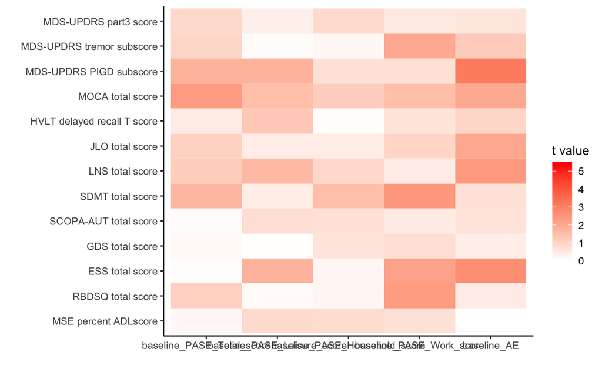

```r
a<-UPDRS_PASE_MOCA_ESS_MSEADL_RBDSQ_SCOPA_HVLT_JLO_LNS_SDMT_GDS_PD %>% dplyr::select(PATNO,Sex,Elapsed_months_2,baseline_AE,Age,LEDD_sum,sum_UPDRS_part3,sum_Tremor_score,sum_PIGD_score,MOCA_Total_score,HVLT_DELAYED_RECALL_T,JLO_RAW,LNS_RAW,SDMT_correct,SCOPA_total_score,GDS_total_score, ESS_total_score,RBDSQ_total_score,MSEADLG,Disease_duration_symptom)
Partner<-c()
c<-c()
for(i in colnames(a)){
  if((i!="Elapsed_months_2")&(i!="baseline_AE")&(i!="Age")&(i!="PATNO")&(i!="LEDD_sum")&(i!="Disease_duration_symptom")&(i!="Sex")){
    a %>% dplyr::select(i,Elapsed_months_2,baseline_AE,Age,PATNO,LEDD_sum,Disease_duration_symptom,Sex)->a1;
    colnames(a1)<-c("V1","Elapsed_months_2","baseline_AE","Age","PATNO","LEDD_sum","Disease_duration_symptom","Sex");
    a1$V1<-scale(a1$V1,center=T,scale=T);
    a1$baseline_AE<-scale(a1$baseline_AE,center=T,scale=T);
    a1$Age<-scale(a1$Age,center=T,scale=T);
    a1$Elapsed_months_2<-scale(a1$Elapsed_months_2,center=T,scale=T);
    a1$LEDD_sum<-scale(a1$LEDD_sum,center=T,scale=T);
    a1$Disease_duration_symptom<-scale(a1$Disease_duration_symptom,center=T,scale=T);
    with(a1,lmer(V1~Elapsed_months_2*baseline_AE+Age+LEDD_sum+Disease_duration_symptom+Sex+(1+Elapsed_months_2|PATNO),REML=FALSE))->b;
    summary(b)->b.summary;confint(b,method="b",nsim=1000) %>% suppressMessages()->b.confint;
    b.summary$coefficients[8,]->e;b.confint[10,]->f;b.summary$AICtab[1:2]->A.BIC
    with(a1,lmer(V1~Elapsed_months_2+baseline_AE+Age+LEDD_sum+Disease_duration_symptom+Sex+(1+Elapsed_months_2|PATNO),REML=FALSE))->b.null;
    anova(b,b.null)->d;summary(b.null)->d.summary;d.summary$AICtab[1:2]-b.summary$AICtab[1:2]->A.BIC
    c(e[1],e[2],e[3],f[1],f[2],d$`Pr(>Chisq)`[2]*65,A.BIC)->d;
    bind_rows(c,d) %>% suppressMessages()->c;
    append(Partner,i)->Partner
  }}
colnames(c)[6]<-"p.value"
cbind(Partner,c)->interaction_effect_table_baseline_AE
interaction_effect_table_baseline_AE <-interaction_effect_table_baseline_AE %>% mutate(significance=if_else(`p.value`<=0.05,"Significant","Not"))
interaction_effect_table_baseline_AE <-cbind(interaction_effect_table_baseline_AE,class=rep("baseline_AE",nrow(interaction_effect_table_baseline_AE)))


#baseline effect
interaction_effect_table_baseline_final <- dplyr::bind_rows(interaction_effect_table_baseline_PASE_Total_score,interaction_effect_table_baseline_PASE_Leisure_score,interaction_effect_table_baseline_PASE_Household_score,interaction_effect_table_baseline_PASE_Work_score,interaction_effect_table_baseline_AE)
interaction_effect_table_baseline_final$Partner_2<-rep(c("MDS-UPDRS part3 score","MDS-UPDRS tremor subscore","MDS-UPDRS PIGD subscore","MOCA total score","HVLT delayed recall T score","JLO total score","LNS total score","SDMT total score","SCOPA-AUT total score","GDS total score", "ESS total score","RBDSQ total score","MSE percent ADLscore"),5)
interaction_effect_table_baseline_final$Partner_2<-factor(interaction_effect_table_baseline_final$Partner_2,levels=rev(c("MDS-UPDRS part3 score","MDS-UPDRS tremor subscore","MDS-UPDRS PIGD subscore","MOCA total score","HVLT delayed recall T score","JLO total score","LNS total score","SDMT total score","SCOPA-AUT total score","GDS total score", "ESS total score","RBDSQ total score","MSE percent ADLscore")))
interaction_effect_table_baseline_final$class<-factor(interaction_effect_table_baseline_final$class,levels=c("baseline_PASE_Total_score","baseline_PASE_Leisure_score","baseline_PASE_Household_score","baseline_PASE_Work_score","baseline_AE"))
interaction_effect_table_baseline_final %>% ggplot(aes(y=`Partner_2`,x=class,fill=abs(`t value`))) + theme_classic()+ geom_tile()+scale_fill_gradient(low="white",high="red",name="t value",limits = c(0, 5.5))+geom_point(aes(shape=significance))+scale_shape_manual(values = c(32,8),labels=c("","significant",""),name="")+ylab("")+xlab("")
```

```r
write_csv(interaction_effect_table_baseline_final,"interaction_effect_table_baseline_final.csv")
```

## Main result (2): the interaction effect between average regular physical activity levels over follow-up periods and clinical progression.

```r
###Interaction with mean_PASE_Total_score, adjusted for Age, LEDD, Disease duration, Sex
c<-c()
for(i in unique(UPDRS_PASE_MOCA_ESS_MSEADL_RBDSQ_SCOPA_HVLT_JLO_LNS_SDMT_GDS_PD$PATNO)){
  UPDRS_PASE_MOCA_ESS_MSEADL_RBDSQ_SCOPA_HVLT_JLO_LNS_SDMT_GDS_PD %>% filter(PATNO==i) -> a;
  if ((nrow(a)>=3))(append(c,rep(mean(a$PASE_Total_score,na.rm = T),nrow(a)))->c)
  else(append(c,rep(NA,nrow(a)))->c)
}
c->mean_PASE_Total_score
UPDRS_PASE_MOCA_ESS_MSEADL_RBDSQ_SCOPA_HVLT_JLO_LNS_SDMT_GDS_PD<-cbind(UPDRS_PASE_MOCA_ESS_MSEADL_RBDSQ_SCOPA_HVLT_JLO_LNS_SDMT_GDS_PD,mean_PASE_Total_score) %>% as_tibble()

a<-UPDRS_PASE_MOCA_ESS_MSEADL_RBDSQ_SCOPA_HVLT_JLO_LNS_SDMT_GDS_PD %>% dplyr::select(PATNO,Sex,Elapsed_months_2,mean_PASE_Total_score,Age,LEDD_sum,sum_UPDRS_part3,sum_Tremor_score,sum_PIGD_score,MOCA_Total_score,HVLT_DELAYED_RECALL_T,JLO_RAW,LNS_RAW,SDMT_correct,SCOPA_total_score,GDS_total_score, ESS_total_score,RBDSQ_total_score,MSEADLG,Disease_duration_symptom)
a$Sex<-as.factor(a$Sex)
Partner<-c()
c<-c()
for(i in colnames(a)){
  if((i!="Elapsed_months_2")&(i!="mean_PASE_Total_score")&(i!="Age")&(i!="PATNO")&(i!="LEDD_sum")&(i!="Disease_duration_symptom")&(i!="Sex")){
    a %>% dplyr::select(i,Elapsed_months_2,mean_PASE_Total_score,Age,PATNO,LEDD_sum,Disease_duration_symptom,Sex)->a1;
    colnames(a1)<-c("V1","Elapsed_months_2","mean_PASE_Total_score","Age","PATNO","LEDD_sum","Disease_duration_symptom","Sex");
    a1$V1<-scale(a1$V1,center=T,scale=T);
    a1$mean_PASE_Total_score<-scale(a1$mean_PASE_Total_score,center=T,scale=T);
    a1$Age<-scale(a1$Age,center=T,scale=T);
    a1$Elapsed_months_2<-scale(a1$Elapsed_months_2,center=T,scale=T);
    a1$LEDD_sum<-scale(a1$LEDD_sum,center=T,scale=T);
    a1$Disease_duration_symptom<-scale(a1$Disease_duration_symptom,center=T,scale=T);
    with(a1,lmer(V1~Elapsed_months_2*mean_PASE_Total_score+Age+LEDD_sum+Disease_duration_symptom+Sex+(1+Elapsed_months_2|PATNO),REML=FALSE))->b;
    summary(b)->b.summary;confint(b,method="b",nsim=1000) %>% suppressMessages()->b.confint;
    b.summary$coefficients[8,]->e;b.confint[10,]->f;b.summary$AICtab[1:2]->A.BIC
    with(a1,lmer(V1~Elapsed_months_2+mean_PASE_Total_score+Age+LEDD_sum+Disease_duration_symptom+Sex+(1+Elapsed_months_2|PATNO),REML=FALSE))->b.null;
    anova(b,b.null)->d;summary(b.null)->d.summary;d.summary$AICtab[1:2]-b.summary$AICtab[1:2]->A.BIC
    c(e[1],e[2],e[3],f[1],f[2],d$`Pr(>Chisq)`[2]*39,A.BIC)->d;
    bind_rows(c,d) %>% suppressMessages()->c;
    append(Partner,i)->Partner
  }}
colnames(c)[6]<-"p.value"
cbind(Partner,c)->interaction_effect_table_mean_PASE_Total_score
interaction_effect_table_mean_PASE_Total_score <-interaction_effect_table_mean_PASE_Total_score %>% mutate(significance=if_else(`p.value`<=0.05,"Significant","Not"))
interaction_effect_table_mean_PASE_Total_score <-cbind(interaction_effect_table_mean_PASE_Total_score,class=rep("mean_PASE_Total_score",nrow(interaction_effect_table_mean_PASE_Total_score)))


###Interaction with mean_PASE_Leisure_score, adjusted for Age, LEDD, Disease duration, Sex
c<-c()
for(i in unique(UPDRS_PASE_MOCA_ESS_MSEADL_RBDSQ_SCOPA_HVLT_JLO_LNS_SDMT_GDS_PD$PATNO)){
  UPDRS_PASE_MOCA_ESS_MSEADL_RBDSQ_SCOPA_HVLT_JLO_LNS_SDMT_GDS_PD %>% filter(PATNO==i) -> a;
  if ((nrow(a)>=3))(append(c,rep(mean(a$PASE_Leisure_score,na.rm = T),nrow(a)))->c)
  else(append(c,rep(NA,nrow(a)))->c)
}
c->mean_PASE_Leisure_score
UPDRS_PASE_MOCA_ESS_MSEADL_RBDSQ_SCOPA_HVLT_JLO_LNS_SDMT_GDS_PD<-cbind(UPDRS_PASE_MOCA_ESS_MSEADL_RBDSQ_SCOPA_HVLT_JLO_LNS_SDMT_GDS_PD,mean_PASE_Leisure_score) %>% as_tibble()

a<-UPDRS_PASE_MOCA_ESS_MSEADL_RBDSQ_SCOPA_HVLT_JLO_LNS_SDMT_GDS_PD %>% dplyr::select(PATNO,Sex,Elapsed_months_2,mean_PASE_Leisure_score,Age,LEDD_sum,sum_UPDRS_part3,sum_Tremor_score,sum_PIGD_score,MOCA_Total_score,HVLT_DELAYED_RECALL_T,JLO_RAW,LNS_RAW,SDMT_correct,SCOPA_total_score,GDS_total_score, ESS_total_score,RBDSQ_total_score,MSEADLG,Disease_duration_symptom)
a$Sex<-as.factor(a$Sex)
Partner<-c()
c<-c()
for(i in colnames(a)){
  if((i!="Elapsed_months_2")&(i!="mean_PASE_Leisure_score")&(i!="Age")&(i!="PATNO")&(i!="LEDD_sum")&(i!="Disease_duration_symptom")&(i!="Sex")){
    a %>% dplyr::select(i,Elapsed_months_2,mean_PASE_Leisure_score,Age,PATNO,LEDD_sum,Disease_duration_symptom,Sex)->a1;
    colnames(a1)<-c("V1","Elapsed_months_2","mean_PASE_Leisure_score","Age","PATNO","LEDD_sum","Disease_duration_symptom","Sex");
    a1$V1<-scale(a1$V1,center=T,scale=T);
    a1$mean_PASE_Leisure_score<-scale(a1$mean_PASE_Leisure_score,center=T,scale=T);
    a1$Age<-scale(a1$Age,center=T,scale=T);
    a1$Elapsed_months_2<-scale(a1$Elapsed_months_2,center=T,scale=T);
    a1$LEDD_sum<-scale(a1$LEDD_sum,center=T,scale=T);
    a1$Disease_duration_symptom<-scale(a1$Disease_duration_symptom,center=T,scale=T);
    with(a1,lmer(V1~Elapsed_months_2*mean_PASE_Leisure_score+Age+LEDD_sum+Disease_duration_symptom+Sex+(1+Elapsed_months_2|PATNO),REML=FALSE))->b;
    summary(b)->b.summary;confint(b,method="b",nsim=1000) %>% suppressMessages()->b.confint;
    b.summary$coefficients[8,]->e;b.confint[10,]->f;b.summary$AICtab[1:2]->A.BIC
    with(a1,lmer(V1~Elapsed_months_2+mean_PASE_Leisure_score+Age+LEDD_sum+Disease_duration_symptom+Sex+(1+Elapsed_months_2|PATNO),REML=FALSE))->b.null;
    anova(b,b.null)->d;summary(b.null)->d.summary;d.summary$AICtab[1:2]-b.summary$AICtab[1:2]->A.BIC
    c(e[1],e[2],e[3],f[1],f[2],d$`Pr(>Chisq)`[2]*65,A.BIC)->d;
    bind_rows(c,d) %>% suppressMessages()->c;
    append(Partner,i)->Partner
  }}
colnames(c)[6]<-"p.value"
cbind(Partner,c)->interaction_effect_table_mean_PASE_Leisure_score
interaction_effect_table_mean_PASE_Leisure_score <-interaction_effect_table_mean_PASE_Leisure_score %>% mutate(significance=if_else(`p.value`<=0.05,"Significant","Not"))
interaction_effect_table_mean_PASE_Leisure_score <-cbind(interaction_effect_table_mean_PASE_Leisure_score,class=rep("mean_PASE_Leisure_score",nrow(interaction_effect_table_mean_PASE_Leisure_score)))


###Interaction with mean_PASE_Household_score, adjusted for Age, LEDD, Disease duration, Sex
c<-c()
for(i in unique(UPDRS_PASE_MOCA_ESS_MSEADL_RBDSQ_SCOPA_HVLT_JLO_LNS_SDMT_GDS_PD$PATNO)){
  UPDRS_PASE_MOCA_ESS_MSEADL_RBDSQ_SCOPA_HVLT_JLO_LNS_SDMT_GDS_PD %>% filter(PATNO==i) -> a;
  if ((nrow(a)>=3))(append(c,rep(mean(a$PASE_Household_score,na.rm = T),nrow(a)))->c)
  else(append(c,rep(NA,nrow(a)))->c)
}
c->mean_PASE_Household_score
UPDRS_PASE_MOCA_ESS_MSEADL_RBDSQ_SCOPA_HVLT_JLO_LNS_SDMT_GDS_PD<-cbind(UPDRS_PASE_MOCA_ESS_MSEADL_RBDSQ_SCOPA_HVLT_JLO_LNS_SDMT_GDS_PD,mean_PASE_Household_score) %>% as_tibble()
```

```r
a<-UPDRS_PASE_MOCA_ESS_MSEADL_RBDSQ_SCOPA_HVLT_JLO_LNS_SDMT_GDS_PD %>% dplyr::select(PATNO,Sex,Elapsed_months_2,mean_PASE_Household_score,Age,LEDD_sum,sum_UPDRS_part3,sum_Tremor_score,sum_PIGD_score,MOCA_Total_score,HVLT_DELAYED_RECALL_T,JLO_RAW,LNS_RAW,SDMT_correct,SCOPA_total_score,GDS_total_score, ESS_total_score,RBDSQ_total_score,MSEADLG,Disease_duration_symptom)
a$Sex<-as.factor(a$Sex)
Partner<-c()
c<-c()
for(i in colnames(a)){
  if((i!="Elapsed_months_2")&(i!="mean_PASE_Household_score")&(i!="Age")&(i!="PATNO")&(i!="LEDD_sum")&(i!="Disease_duration_symptom")&(i!="Sex")){
    a %>% dplyr::select(i,Elapsed_months_2,mean_PASE_Household_score,Age,PATNO,LEDD_sum,Disease_duration_symptom,Sex)->a1;
    colnames(a1)<-c("V1","Elapsed_months_2","mean_PASE_Household_score","Age","PATNO","LEDD_sum","Disease_duration_symptom","Sex");
    a1$V1<-scale(a1$V1,center=T,scale=T);
    a1$mean_PASE_Household_score<-scale(a1$mean_PASE_Household_score,center=T,scale=T);
    a1$Age<-scale(a1$Age,center=T,scale=T);
    a1$Elapsed_months_2<-scale(a1$Elapsed_months_2,center=T,scale=T);
    a1$LEDD_sum<-scale(a1$LEDD_sum,center=T,scale=T);
    a1$Disease_duration_symptom<-scale(a1$Disease_duration_symptom,center=T,scale=T);
    with(a1,lmer(V1~Elapsed_months_2*mean_PASE_Household_score+Age+LEDD_sum+Disease_duration_symptom+Sex+(1+Elapsed_months_2|PATNO),REML=FALSE))->b;
    summary(b)->b.summary;confint(b,method="b",nsim=1000) %>% suppressMessages()->b.confint;
    b.summary$coefficients[8,]->e;b.confint[10,]->f;b.summary$AICtab[1:2]->A.BIC
    with(a1,lmer(V1~Elapsed_months_2+mean_PASE_Household_score+Age+LEDD_sum+Disease_duration_symptom+Sex+(1+Elapsed_months_2|PATNO),REML=FALSE))->b.null;
    anova(b,b.null)->d;summary(b.null)->d.summary;d.summary$AICtab[1:2]-b.summary$AICtab[1:2]->A.BIC
    c(e[1],e[2],e[3],f[1],f[2],d$`Pr(>Chisq)`[2]*39,A.BIC)->d;
    bind_rows(c,d) %>% suppressMessages()->c;
    append(Partner,i)->Partner
  }}
colnames(c)[6]<-"p.value"
cbind(Partner,c)->interaction_effect_table_mean_PASE_Household_score
interaction_effect_table_mean_PASE_Household_score <-interaction_effect_table_mean_PASE_Household_score %>% mutate(significance=if_else(`p.value`<=0.05,"Significant","Not"))
interaction_effect_table_mean_PASE_Household_score <-cbind(interaction_effect_table_mean_PASE_Household_score,class=rep("mean_PASE_Household_score",nrow(interaction_effect_table_mean_PASE_Household_score)))




###Interaction with mean_PASE_Work_score, adjusted for Age, LEDD, Disease duration, Sex
c<-c()
for(i in unique(UPDRS_PASE_MOCA_ESS_MSEADL_RBDSQ_SCOPA_HVLT_JLO_LNS_SDMT_GDS_PD$PATNO)){
  UPDRS_PASE_MOCA_ESS_MSEADL_RBDSQ_SCOPA_HVLT_JLO_LNS_SDMT_GDS_PD %>% filter(PATNO==i) -> a;
  if ((nrow(a)>=3))(append(c,rep(mean(a$PASE_Work_score,na.rm = T),nrow(a)))->c)
  else(append(c,rep(NA,nrow(a)))->c)
}
c->mean_PASE_Work_score
UPDRS_PASE_MOCA_ESS_MSEADL_RBDSQ_SCOPA_HVLT_JLO_LNS_SDMT_GDS_PD<-cbind(UPDRS_PASE_MOCA_ESS_MSEADL_RBDSQ_SCOPA_HVLT_JLO_LNS_SDMT_GDS_PD,mean_PASE_Work_score) %>% as_tibble()

a<-UPDRS_PASE_MOCA_ESS_MSEADL_RBDSQ_SCOPA_HVLT_JLO_LNS_SDMT_GDS_PD %>% dplyr::select(PATNO,Sex,Elapsed_months_2,mean_PASE_Work_score,Age,LEDD_sum,sum_UPDRS_part3,sum_Tremor_score,sum_PIGD_score,MOCA_Total_score,HVLT_DELAYED_RECALL_T,JLO_RAW,LNS_RAW,SDMT_correct,SCOPA_total_score,GDS_total_score, ESS_total_score,RBDSQ_total_score,MSEADLG,Disease_duration_symptom)
a$Sex<-as.factor(a$Sex)
Partner<-c()
c<-c()
for(i in colnames(a)){
  if((i!="Elapsed_months_2")&(i!="mean_PASE_Work_score")&(i!="Age")&(i!="PATNO")&(i!="LEDD_sum")&(i!="Disease_duration_symptom")&(i!="Sex")){
    a %>% dplyr::select(i,Elapsed_months_2,mean_PASE_Work_score,Age,PATNO,LEDD_sum,Disease_duration_symptom,Sex)->a1;
    colnames(a1)<-c("V1","Elapsed_months_2","mean_PASE_Work_score","Age","PATNO","LEDD_sum","Disease_duration_symptom","Sex");
    a1$V1<-scale(a1$V1,center=T,scale=T);
    a1$mean_PASE_Work_score<-scale(a1$mean_PASE_Work_score,center=T,scale=T);
    a1$Age<-scale(a1$Age,center=T,scale=T);
    a1$Elapsed_months_2<-scale(a1$Elapsed_months_2,center=T,scale=T);
    a1$LEDD_sum<-scale(a1$LEDD_sum,center=T,scale=T);
    a1$Disease_duration_symptom<-scale(a1$Disease_duration_symptom,center=T,scale=T);
    with(a1,lmer(V1~Elapsed_months_2*mean_PASE_Work_score+Age+LEDD_sum+Disease_duration_symptom+Sex+(1+Elapsed_months_2|PATNO),REML=FALSE))->b;
    summary(b)->b.summary;confint(b,method="b",nsim=1000) %>% suppressMessages()->b.confint;
    b.summary$coefficients[8,]->e;b.confint[10,]->f;b.summary$AICtab[1:2]->A.BIC
    with(a1,lmer(V1~Elapsed_months_2+mean_PASE_Work_score+Age+LEDD_sum+Disease_duration_symptom+Sex+(1+Elapsed_months_2|PATNO),REML=FALSE))->b.null;
    anova(b,b.null)->d;summary(b.null)->d.summary;d.summary$AICtab[1:2]-b.summary$AICtab[1:2]->A.BIC
    c(e[1],e[2],e[3],f[1],f[2],d$`Pr(>Chisq)`[2]*65,A.BIC)->d;
    bind_rows(c,d) %>% suppressMessages()->c;
    append(Partner,i)->Partner
  }}
colnames(c)[6]<-"p.value"
cbind(Partner,c)->interaction_effect_table_mean_PASE_Work_score
interaction_effect_table_mean_PASE_Work_score <-interaction_effect_table_mean_PASE_Work_score %>% mutate(significance=if_else(`p.value`<=0.05,"Significant","Not"))
interaction_effect_table_mean_PASE_Work_score <-cbind(interaction_effect_table_mean_PASE_Work_score,class=rep("mean_PASE_Work_score",nrow(interaction_effect_table_mean_PASE_Work_score)))


###Interaction with mean_AE, adjusted for Age, LEDD, Disease duration, Sex
c<-c()
for(i in unique(UPDRS_PASE_MOCA_ESS_MSEADL_RBDSQ_SCOPA_HVLT_JLO_LNS_SDMT_GDS_PD$PATNO)){
  UPDRS_PASE_MOCA_ESS_MSEADL_RBDSQ_SCOPA_HVLT_JLO_LNS_SDMT_GDS_PD %>% filter(PATNO==i) -> a;
  if ((nrow(a)>=3))(append(c,rep(mean(a$AE,na.rm = T),nrow(a)))->c)
  else(append(c,rep(NA,nrow(a)))->c)
}
c->mean_AE
UPDRS_PASE_MOCA_ESS_MSEADL_RBDSQ_SCOPA_HVLT_JLO_LNS_SDMT_GDS_PD<-cbind(UPDRS_PASE_MOCA_ESS_MSEADL_RBDSQ_SCOPA_HVLT_JLO_LNS_SDMT_GDS_PD,mean_AE) %>% as_tibble()

a<-UPDRS_PASE_MOCA_ESS_MSEADL_RBDSQ_SCOPA_HVLT_JLO_LNS_SDMT_GDS_PD %>% dplyr::select(PATNO,Sex,Elapsed_months_2,mean_AE,Age,LEDD_sum,sum_UPDRS_part3,sum_Tremor_score,sum_PIGD_score,MOCA_Total_score,HVLT_DELAYED_RECALL_T,JLO_RAW,LNS_RAW,SDMT_correct,SCOPA_total_score,GDS_total_score, ESS_total_score,RBDSQ_total_score,MSEADLG,Disease_duration_symptom)
a$Sex<-as.factor(a$Sex)
Partner<-c()
c<-c()
for(i in colnames(a)){
  if((i!="Elapsed_months_2")&(i!="mean_AE")&(i!="Age")&(i!="PATNO")&(i!="LEDD_sum")&(i!="Disease_duration_symptom")&(i!="Sex")){
    a %>% dplyr::select(i,Elapsed_months_2,mean_AE,Age,PATNO,LEDD_sum,Disease_duration_symptom,Sex)->a1;
    colnames(a1)<-c("V1","Elapsed_months_2","mean_AE","Age","PATNO","LEDD_sum","Disease_duration_symptom","Sex");
    a1$V1<-scale(a1$V1,center=T,scale=T);
    a1$mean_AE<-scale(a1$mean_AE,center=T,scale=T);
    a1$Age<-scale(a1$Age,center=T,scale=T);
    a1$Elapsed_months_2<-scale(a1$Elapsed_months_2,center=T,scale=T);
    a1$LEDD_sum<-scale(a1$LEDD_sum,center=T,scale=T);
    a1$Disease_duration_symptom<-scale(a1$Disease_duration_symptom,center=T,scale=T);
    with(a1,lmer(V1~Elapsed_months_2*mean_AE+Age+LEDD_sum+Disease_duration_symptom+Sex+(1+Elapsed_months_2|PATNO),REML=FALSE))->b;
    summary(b)->b.summary;confint(b,method="b",nsim=1000) %>% suppressMessages()->b.confint;
    b.summary$coefficients[8,]->e;b.confint[10,]->f;b.summary$AICtab[1:2]->A.BIC
    with(a1,lmer(V1~Elapsed_months_2+mean_AE+Age+LEDD_sum+Disease_duration_symptom+Sex+(1+Elapsed_months_2|PATNO),REML=FALSE))->b.null;
    anova(b,b.null)->d;summary(b.null)->d.summary;d.summary$AICtab[1:2]-b.summary$AICtab[1:2]->A.BIC
    c(e[1],e[2],e[3],f[1],f[2],d$`Pr(>Chisq)`[2]*65,A.BIC)->d;
    bind_rows(c,d) %>% suppressMessages()->c;
    append(Partner,i)->Partner
  }}
colnames(c)[6]<-"p.value"
cbind(Partner,c)->interaction_effect_table_mean_AE
interaction_effect_table_mean_AE <-interaction_effect_table_mean_AE %>% mutate(significance=if_else(`p.value`<=0.05,"Significant","Not"))
interaction_effect_table_mean_AE <-cbind(interaction_effect_table_mean_AE,class=rep("mean_AE",nrow(interaction_effect_table_mean_AE)))
```

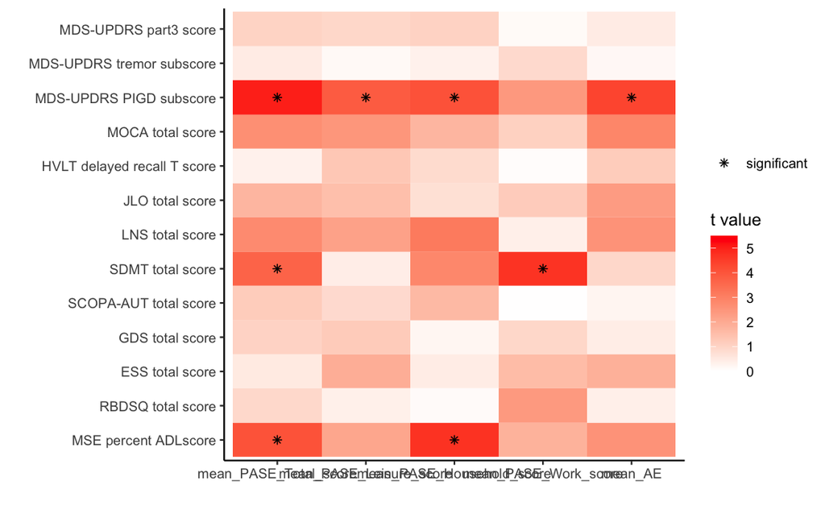

```r
#mean effect
interaction_effect_table_mean_final <- dplyr::bind_rows(interaction_effect_table_mean_PASE_Total_score,interaction_effect_table_mean_PASE_Leisure_score,interaction_effect_table_mean_PASE_Household_score,interaction_effect_table_mean_PASE_Work_score,interaction_effect_table_mean_AE)
interaction_effect_table_mean_final$Partner_2<-rep(c("MDS-UPDRS part3 score","MDS-UPDRS tremor subscore","MDS-UPDRS PIGD subscore","MOCA total score","HVLT delayed recall T score","JLO total score","LNS total score","SDMT total score","SCOPA-AUT total score","GDS total score", "ESS total score","RBDSQ total score","MSE percent ADLscore"),5)
interaction_effect_table_mean_final$Partner_2<-factor(interaction_effect_table_mean_final$Partner_2,levels=rev(c("MDS-UPDRS part3 score","MDS-UPDRS tremor subscore","MDS-UPDRS PIGD subscore","MOCA total score","HVLT delayed recall T score","JLO total score","LNS total score","SDMT total score","SCOPA-AUT total score","GDS total score", "ESS total score","RBDSQ total score","MSE percent ADLscore")))
interaction_effect_table_mean_final$class<-factor(interaction_effect_table_mean_final$class,levels=c("mean_PASE_Total_score","mean_PASE_Leisure_score","mean_PASE_Household_score","mean_PASE_Work_score","mean_AE"))
interaction_effect_table_mean_final %>% ggplot(aes(y=`Partner_2`,x=class,fill=abs(`t value`))) + theme_classic()+ geom_tile()+scale_fill_gradient(low="white",high="red",name="t value",limits = c(0, 5.5))+geom_point(aes(shape=significance))+scale_shape_manual(values = c(32,8),labels=c("","significant",""),name="")+ylab("")+xlab("")
```

```r
write_csv(interaction_effect_table_mean_final,"interaction_effect_table_mean_final.csv")
```

## Sensitivity analysis (1): Propensity score matching

The following codes descibes how the propensity score mathing was performed in this study. After this code, the following csvs are obtained: **"“interaction_effect_table_mean_PASE_Total_score_categorize.csv”“**,** ”“interaction_effect_table_mean_PASE_Household_score_categorize.csv”“**,** ”“interaction_effect_table_mean_PASE_Work_score_categorize_2.csv”“**,** ”“interaction_effect_table_mean_PASE_Work_score_categorize.csv”“**,** ”“interaction_effect_table_mean_AE_categorize.csv”"**.

```r
d<-UPDRS_PASE_MOCA_ESS_MSEADL_RBDSQ_SCOPA_HVLT_JLO_LNS_SDMT_GDS_PD %>% filter(is.na(mean_PASE_Total_score)==F) %>% filter(Elapsed_months_2==0)
c<-c()
for(i in unique(UPDRS_PASE_MOCA_ESS_MSEADL_RBDSQ_SCOPA_HVLT_JLO_LNS_SDMT_GDS_PD$PATNO)){
  UPDRS_PASE_MOCA_ESS_MSEADL_RBDSQ_SCOPA_HVLT_JLO_LNS_SDMT_GDS_PD %>% filter(PATNO==i) -> a;
  if ((nrow(a)>=3)){
    if(mean(a$PASE_Total_score,na.rm = T)>=quantile(d$mean_PASE_Total_score,na.rm=T,0.75))(append(c,rep("50-100",nrow(a)))->c)else{
      if(mean(a$PASE_Total_score,na.rm = T)>=quantile(d$mean_PASE_Total_score,na.rm=T,0.5))(append(c,rep("50-100",nrow(a)))->c)else{
        if(mean(a$PASE_Total_score,na.rm = T)>=quantile(d$mean_PASE_Total_score,na.rm=T,0.25))(append(c,rep("0-50",nrow(a)))->c)else(append(c,rep("0-50",nrow(a)))->c)}}}
  else(append(c,rep(NA,nrow(a)))->c)
}
c->mean_PASE_Total_score_binary

d<-cbind(UPDRS_PASE_MOCA_ESS_MSEADL_RBDSQ_SCOPA_HVLT_JLO_LNS_SDMT_GDS_PD,mean_PASE_Total_score_binary)

d %>% filter(Elapsed_months_2==0) %>% filter(is.na(sum_UPDRS_part3)==F) %>% filter(is.na(mean_PASE_Total_score_binary)==F) ->d1
d1$mean_PASE_Total_score_binary<-as.factor(d1$mean_PASE_Total_score_binary)
d1$Sex<-as.factor(d1$Sex)
d1 %>% dplyr::select(PATNO,mean_PASE_Total_score_binary,Age,Sex,MOCA_Total_score,Disease_duration_symptom,sum_UPDRS_part3,sum_PIGD_score,LEDD_sum,MSEADLG,GDS_total_score,LNS_RAW,sum_Tremor_score,SDMT_correct,NHY,HVLT_DELAYED_RECALL_T,JLO_RAW,SCOPA_total_score) %>% na.omit() -> d1
MatchIt::matchit(mean_PASE_Total_score_binary ~ Age + Sex + MOCA_Total_score + Disease_duration_symptom + sum_UPDRS_part3 + sum_PIGD_score +LEDD_sum+MSEADLG+GDS_total_score+LNS_RAW+sum_Tremor_score+SDMT_correct+NHY+HVLT_DELAYED_RECALL_T+JLO_RAW+SCOPA_total_score, data=d1,  distance="logit", method = "nearest",replace=FALSE) %>% suppressMessages()->match.obj
d1$PS<-match.obj$distance
logitPS<-log(1/d1$PS-1)

MatchIt::matchit(mean_PASE_Total_score_binary ~ Age + Sex + MOCA_Total_score + Disease_duration_symptom + sum_UPDRS_part3 + sum_PIGD_score+LEDD_sum+MSEADLG+GDS_total_score+LNS_RAW+sum_Tremor_score+SDMT_correct+NHY+HVLT_DELAYED_RECALL_T+JLO_RAW+SCOPA_total_score, data=d1, distance="logit", method = "nearest",replace=FALSE,caliper =  0.25*sd(logitPS))->match.obj
d2<-match.data(match.obj)
d3 <- d %>% filter(Elapsed_months_2==0) %>% filter(is.element(PATNO,d2$PATNO))

Match_aft_SMD<-CreateTableOne(strata="mean_PASE_Total_score_binary",var=c("Age","Sex","Disease_duration_symptom","NHY","LEDD_sum","sum_UPDRS_part3","sum_Tremor_score","sum_PIGD_score","MOCA_Total_score","HVLT_DELAYED_RECALL_T","JLO_RAW","LNS_RAW","SDMT_correct","SCOPA_total_score","GDS_total_score", "ESS_total_score","RBDSQ_total_score","MSEADLG"),test=F,smd=T,data=d3) %>% print(smd=T)
```

```
                                      Stratified by mean_PASE_Total_score_binary
                                       0-50            50-100          SMD
  n                                        86              86
  Age (mean (SD))                       63.67 (8.55)    63.01 (9.08)    0.075
  Sex = Male (%)                           60 (69.8)       60 (69.8)   <0.001
  Disease_duration_symptom (mean (SD))   3.79 (2.06)     3.64 (1.61)    0.082
  NHY (mean (SD))                        1.77 (0.45)     1.79 (0.56)    0.046
  LEDD_sum (mean (SD))                 198.83 (289.89) 195.06 (304.56)  0.013
  sum_UPDRS_part3 (mean (SD))           26.88 (10.28)   26.44 (12.04)   0.039
  sum_Tremor_score (mean (SD))           7.01 (4.67)     6.64 (4.21)    0.084
  sum_PIGD_score (mean (SD))             1.58 (1.20)     1.57 (1.45)    0.009
  MOCA_Total_score (mean (SD))          26.31 (2.65)    26.42 (2.48)    0.041
  HVLT_DELAYED_RECALL_T (mean (SD))     45.28 (12.89)   44.99 (9.59)    0.026
  JLO_RAW (mean (SD))                   25.86 (4.62)    25.56 (4.22)    0.068
  LNS_RAW (mean (SD))                   10.91 (2.73)    10.73 (2.74)    0.064
  SDMT_correct (mean (SD))              41.24 (10.35)   40.65 (8.86)    0.062
  SCOPA_total_score (mean (SD))         14.28 (9.69)    14.36 (10.33)   0.008
  GDS_total_score (mean (SD))            5.38 (1.38)     5.51 (1.45)    0.090
  ESS_total_score (mean (SD))            6.31 (3.96)     5.94 (3.81)    0.096
  RBDSQ_total_score (mean (SD))          5.45 (3.20)     5.41 (2.69)    0.016
  MSEADLG (mean (SD))                   89.13 (6.24)    89.53 (7.66)    0.058
```

```r
Match_aft_SMD<-Match_aft_SMD %>% as_tibble() %>% cbind(label=rownames(Match_aft_SMD)) %>% as_tibble() ;Match_aft_SMD<-Match_aft_SMD[-1,];Match_aft_SMD$SMD<-as.numeric(Match_aft_SMD$SMD) %>% suppressWarnings()

d %>% filter(Elapsed_months_2==0) %>% filter(is.na(sum_UPDRS_part3)==F) %>% filter(is.na(mean_PASE_Total_score_binary)==F) ->d1
Match_bef_SMD<-CreateTableOne(strata="mean_PASE_Total_score_binary",var=c("Age","Sex","Disease_duration_symptom","NHY","LEDD_sum","sum_UPDRS_part3","sum_Tremor_score","sum_PIGD_score","MOCA_Total_score","HVLT_DELAYED_RECALL_T","JLO_RAW","LNS_RAW","SDMT_correct","SCOPA_total_score","GDS_total_score", "ESS_total_score","RBDSQ_total_score","MSEADLG"),test=F,smd=T,data=d1) %>% print(smd=T)
```

```
                                      Stratified by mean_PASE_Total_score_binary
                                       0-50            50-100          SMD
  n                                       118             119
  Age (mean (SD))                       65.66 (9.24)    60.32 (10.06)   0.553
  Sex = Male (%)                           78 (66.1)       86 (72.3)    0.134
  Disease_duration_symptom (mean (SD))   3.86 (2.55)     3.67 (1.73)    0.084
  NHY (mean (SD))                        1.77 (0.46)     1.78 (0.52)    0.021
  LEDD_sum (mean (SD))                 242.26 (403.06) 199.21 (296.27)  0.122
  sum_UPDRS_part3 (mean (SD))           27.93 (10.64)   25.01 (11.79)   0.260
  sum_Tremor_score (mean (SD))           6.82 (4.61)     6.39 (4.33)    0.097
  sum_PIGD_score (mean (SD))             1.80 (1.55)     1.47 (1.35)    0.225
  MOCA_Total_score (mean (SD))          25.85 (2.85)    26.73 (2.47)    0.331
  HVLT_DELAYED_RECALL_T (mean (SD))     43.87 (13.17)   46.50 (9.69)    0.228
  JLO_RAW (mean (SD))                   25.08 (5.06)    25.87 (4.07)    0.172
  LNS_RAW (mean (SD))                   10.71 (2.76)    10.69 (2.54)    0.009
  SDMT_correct (mean (SD))              39.42 (10.90)   42.62 (9.35)    0.316
  SCOPA_total_score (mean (SD))         15.47 (9.22)    13.54 (9.70)    0.204
  GDS_total_score (mean (SD))            5.39 (1.47)     5.48 (1.43)    0.059
  ESS_total_score (mean (SD))            6.62 (3.96)     6.09 (4.01)    0.132
  RBDSQ_total_score (mean (SD))          5.23 (3.11)     5.50 (2.77)    0.091
  MSEADLG (mean (SD))                   88.12 (7.15)    90.04 (7.26)    0.267
```

```
 警告:  Removed 1 rows containing missing values (geom_point).
```

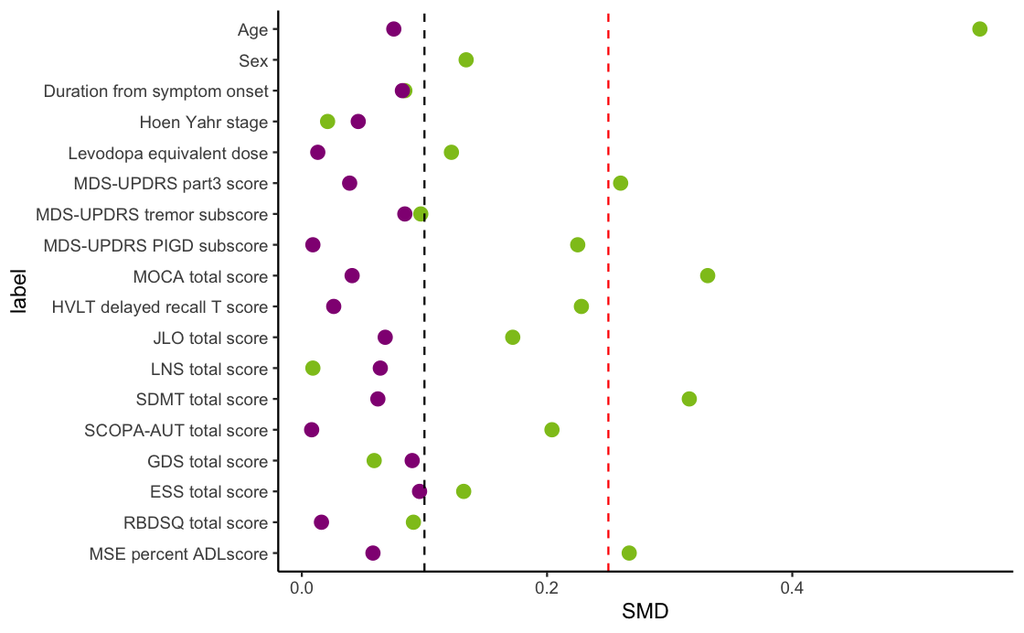

```r
Match_bef_SMD<-Match_bef_SMD %>% as_tibble() %>% cbind(label=rownames(Match_bef_SMD)) %>% as_tibble() ;Match_bef_SMD<-Match_bef_SMD[-1,];Match_bef_SMD$SMD<-as.numeric(Match_bef_SMD$SMD)
Match_SMD<-data.frame(label=Match_aft_SMD$label,BEF=Match_bef_SMD$SMD,AF=Match_aft_SMD$SMD);rm(Match_aft_SMD,Match_bef_SMD)
Match_SMD$label<-c("Age","Sex","Duration from symptom onset","Hoen Yahr stage","Levodopa equivalent dose","MDS-UPDRS part3 score","MDS-UPDRS tremor subscore","MDS-UPDRS PIGD subscore","MOCA total score","HVLT delayed recall T score","JLO total score","LNS total score","SDMT total score","SCOPA-AUT total score","GDS total score", "ESS total score","RBDSQ total score","MSE percent ADLscore")
Match_SMD$label<-factor(Match_SMD$label,level=rev(Match_SMD$label))
Match_SMD %>% tidyr::gather(key=PSM,value=SMD,BEF,AF) %>% ggplot(aes(x=SMD,y=label,colour=PSM)) + theme_classic() + geom_point(size=3) +scale_colour_discrete(name="",labels=c("After PSM","Before PSM"))+geom_vline(xintercept = 0.1,linetype="dashed", color = "black")  +geom_vline(xintercept = 0.25,linetype="dashed", color = "red") + scale_color_manual(values = c("#920783","#8FC31F"))+ theme(legend.position = "none")
```

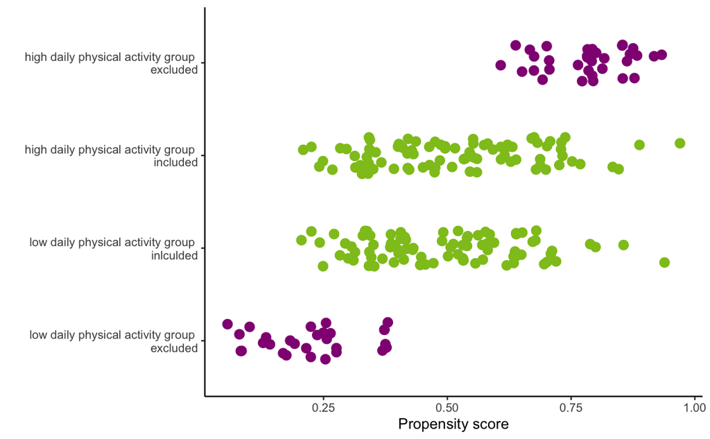

```r
Match_info <- data.frame(Match=match.obj$weights,Dichotomized=match.obj$treat,PS=match.obj$distance) %>% dplyr::mutate(Group=if_else(((Match==0)&(Dichotomized==1)),"above_discarded",if_else(((Match==0)&(Dichotomized==0)),"below_discarded",if_else(((Match==1)&(Dichotomized==1)),"above_adopted","below_adopted"))))  %>% as_tibble()
Match_info$Group<-factor(Match_info$Group,levels=c("below_discarded","below_adopted","above_adopted","above_discarded"))
Match_info$Match<-factor(Match_info$Match,levels=rev(unique(Match_info$Match)))
Match_info  %>% ggplot(aes(x=PS,y=Group,colour=Match)) + theme_classic() + geom_jitter(size=3,width=0.0,height=0.2)+scale_colour_discrete(name="",labels=c("After PSM","Before PSM"))+xlab("Propensity score")+scale_y_discrete(label=c("low daily physical activity group \n excluded","low daily physical activity group \n inlculded","high daily physical activity group \n included","high daily physical activity group \n excluded"))+ylab("")+ scale_color_manual(values = c("#920783","#8FC31F"),name="",label=c("",""))+ theme(legend.position = "none")
```

```r
d3<-d3 %>% dplyr::select(mean_PASE_Total_score_binary,Age,Sex,Disease_duration_symptom,NHY,LEDD_sum,sum_UPDRS_part3,sum_Tremor_score,sum_PIGD_score,MOCA_Total_score,HVLT_DELAYED_RECALL_T,JLO_RAW,LNS_RAW,SDMT_correct,SCOPA_total_score,GDS_total_score, ESS_total_score,RBDSQ_total_score,MSEADLG)
colnames(d3)<-c("mean PASE","Age","Sex","Duration from symptom onset","Hoen Yahr stage","Levodopa equivalent dose","MDS-UPDRS part3 score","MDS-UPDRS tremor subscore","MDS-UPDRS PIGD subscore","MOCA total score","HVLT delayed recall T score","JLO total score","LNS total score","SDMT total score","SCOPA-AUT total score","GDS total score", "ESS total score","RBDSQ total score","MSE percent ADLscore")
d3 %>% tbl_summary(by =`mean PASE`,digits=list(all_continuous()~1,all_categorical()~1),type=list(`MDS-UPDRS PIGD subscore`~"continuous",`MSE percent ADLscore`~"continuous",`JLO total score`~"continuous",`Hoen Yahr stage`~"continuous",`Duration from symptom onset`~"continuous")) %>% add_p()
```

| **Characteristic** | **0-50**, N = 86<sup>1</sup> | **50-100**, N = 86<sup>1</sup> | **p-value**<sup>2</sup> |
| --- | --- | --- | --- |
| Age | 64.5 (59.2, 70.0) | 63.0 (57.0, 70.0) | 0.59 |
| Sex |  |  | >0.99 |
| Female | 26.0 (30.2%) | 26.0 (30.2%) |  |
| Male | 60.0 (69.8%) | 60.0 (69.8%) |  |
| Duration from symptom onset | 3.5 (3.0, 4.8) | 3.0 (2.2, 5.0) | 0.92 |
| Hoen Yahr stage | 2.0 (2.0, 2.0) | 2.0 (1.0, 2.0) | 0.90 |
| Levodopa equivalent dose | 100.0 (0.0, 300.0) | 100.0 (0.0, 224.1) | 0.78 |
| MDS-UPDRS part3 score | 27.0 (20.5, 33.0) | 23.0 (18.0, 36.0) | 0.43 |
| MDS-UPDRS tremor subscore | 7.5 (3.0, 10.8) | 6.0 (4.0, 9.0) | 0.56 |
| MDS-UPDRS PIGD subscore | 1.5 (1.0, 2.0) | 1.0 (1.0, 2.0) | 0.49 |
| MOCA total score | 27.0 (25.0, 29.0) | 27.0 (25.0, 28.0) | 0.92 |
| HVLT delayed recall T score | 47.0 (36.0, 57.5) | 45.0 (38.0, 52.8) | 0.67 |
| JLO total score | 28.0 (24.0, 28.0) | 26.0 (22.0, 30.0) | 0.47 |
| LNS total score | 11.0 (9.0, 12.0) | 11.0 (9.0, 12.8) | 0.72 |
| SDMT total score | 42.0 (36.2, 48.0) | 40.5 (35.0, 48.0) | 0.29 |
| SCOPA-AUT total score | 12.0 (7.2, 20.0) | 13.5 (7.0, 18.8) | 0.94 |
| GDS total score | 5.0 (5.0, 6.0) | 5.0 (5.0, 6.0) | 0.75 |
| ESS total score | 6.0 (4.0, 8.8) | 6.0 (3.0, 7.0) | 0.67 |
| RBDSQ total score | 4.0 (3.0, 7.8) | 5.0 (4.0, 7.0) | 0.60 |
| MSE percent ADLscore | 90.0 (90.0, 90.0) | 90.0 (85.0, 95.0) | 0.52 |

<sup>*1*</sup> Median (IQR); n (%) <sup>*2*</sup> Wilcoxon rank sum test; Pearson's Chi-squared test

```
 警告:  Removed 101 rows containing non-finite values (stat_smooth).
```

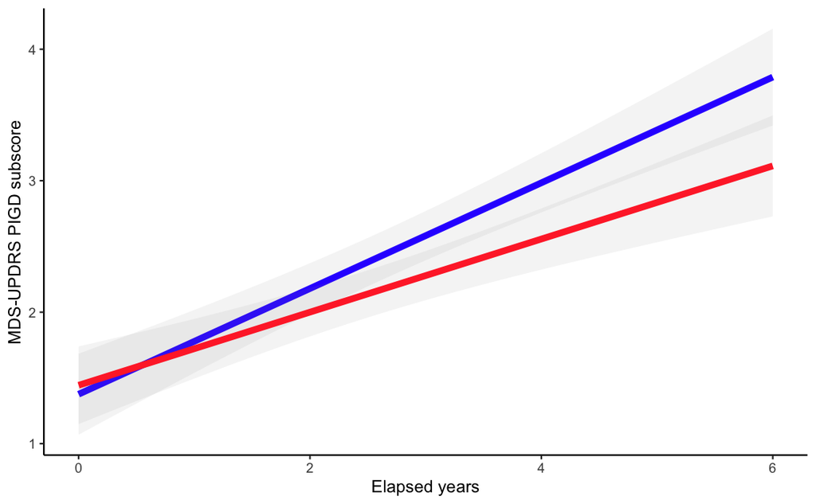

```r
d %>% filter(is.element(PATNO,d2$PATNO))->d4
d4 %>% filter(is.na(mean_PASE_Total_score_binary)==F) %>% ggplot(aes(x=Elapsed_months_2/12,y=sum_PIGD_score,colour=mean_PASE_Total_score_binary))+theme_classic()+stat_smooth(se=T,fullrange = F,level = 0.95,method=lm,alpha=0.1,size=2)+ylab("MDS-UPDRS PIGD subscore")+xlab("Elapsed years")+scale_colour_discrete(labels=c("Below","Above"),name=expression(atop("Average PASE","total score")))+xlim(c(0,6))+scale_color_manual(values = c("#3232FF","#FF3232"))+ theme(legend.position = "none")
```

```
 警告:  Removed 4 rows containing non-finite values (stat_smooth).
```

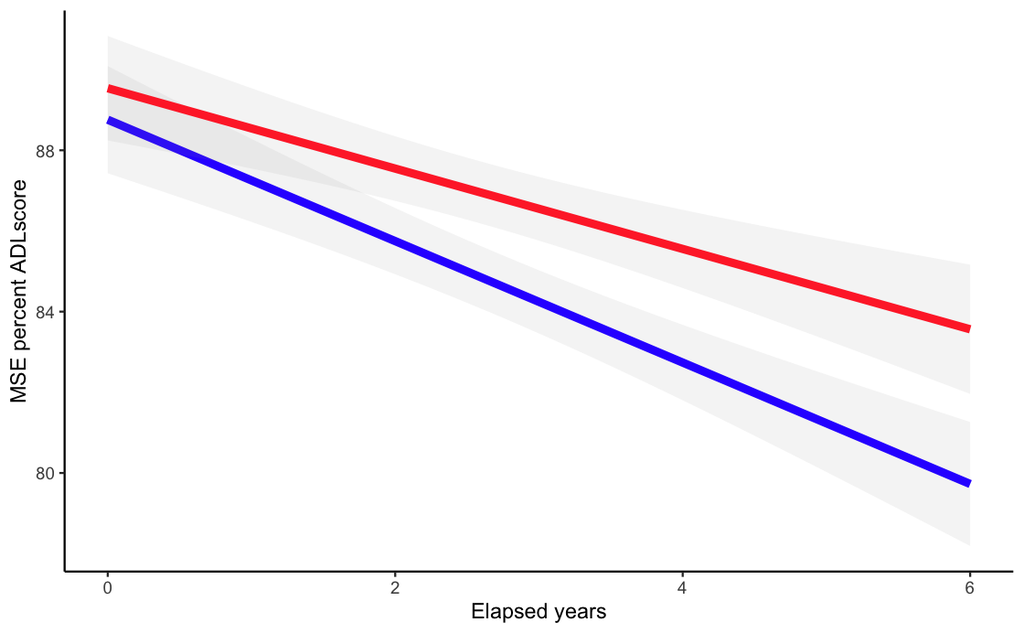

```r
d4 %>% filter(is.na(mean_PASE_Total_score_binary)==F) %>% ggplot(aes(x=Elapsed_months_2/12,y=MSEADLG,colour=mean_PASE_Total_score_binary))+theme_classic()+stat_smooth(se=T,fullrange = T,level = 0.95,method=lm,alpha=0.1,size=2)+ylab("MSE percent ADLscore")+xlab("Elapsed years")+scale_colour_discrete(labels=c("Below","Above"),name=expression(atop("Average PASE","total score")))+xlim(c(0,6))+scale_color_manual(values = c("#3232FF","#FF3232"))+ theme(legend.position = "none")
```

```
 警告:  Removed 5 rows containing non-finite values (stat_smooth).
```

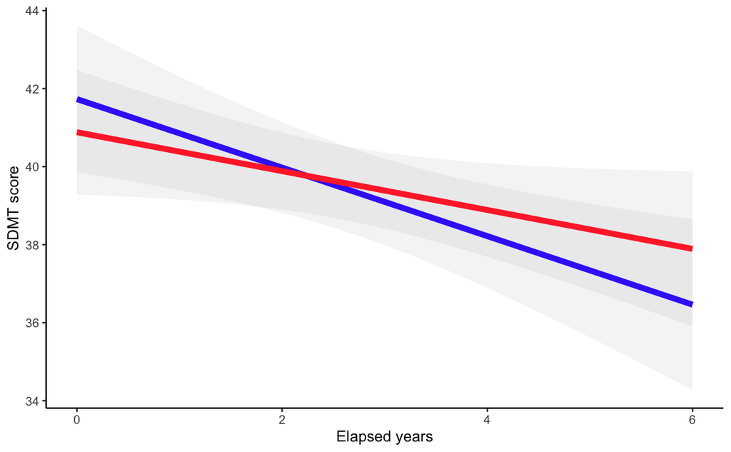

```r
d4 %>% filter(is.na(mean_PASE_Total_score_binary)==F) %>% ggplot(aes(x=Elapsed_months_2/12,y=SDMT_correct,colour=mean_PASE_Total_score_binary))+theme_classic()+stat_smooth(se=T,fullrange = T,level = 0.95,method=lm,alpha=0.1,size=2)+ylab("SDMT score")+xlab("Elapsed years")+scale_colour_discrete(labels=c("Below","Above"),name=expression(atop("Average PASE","total score")))+xlim(c(0,6))+scale_color_manual(values = c("#3232FF","#FF3232"))+ theme(legend.position = "none")
```

```r
a<-d4 %>% dplyr::select(Elapsed_months_2,Age,sum_PIGD_score,MSEADLG,mean_PASE_Total_score_binary,SDMT_correct,PATNO,Sex,LEDD_sum,Disease_duration_symptom)
c<-c()
p.value<-c()
Partner<-c()
Quantile<-c()
confint_sum<-c()
a$mean_PASE_Total_score_binary<-as.factor(a$mean_PASE_Total_score_binary)
for(i in colnames(a)){
  if((i!="Elapsed_months_2")&(i!="mean_PASE_Total_score_binary")&(i!="Age")&(i!="PATNO")&(i!="Sex")&(i!="LEDD_sum")&(i!="Disease_duration_symptom")){
    a %>% dplyr::select(i,Elapsed_months_2,mean_PASE_Total_score_binary,Age,PATNO,Sex,LEDD_sum,Disease_duration_symptom)->a1;
    colnames(a1)<-c("V1","Elapsed_months_2","mean_PASE_Total_score_categorize","Age","PATNO","Sex","LEDD_sum","Disease_duration_symptom");
    a1$V1<-scale(a1$V1,center=T,scale=T);
    a1$Age<-scale(a1$Age,center=T,scale=T);
    a1$Elapsed_months_2<-scale(a1$Elapsed_months_2,center=T,scale=T);
    a1$LEDD_sum<-scale(a1$LEDD_sum,center=T,scale=T);
    a1$Disease_duration_symptom<-scale(a1$Disease_duration_symptom,center=T,scale=T);
    with(a1,lmer(V1~Elapsed_months_2*mean_PASE_Total_score_categorize+Age+LEDD_sum+Disease_duration_symptom+Sex+(1+Elapsed_months_2|PATNO),REML=FALSE))->b;
    summary(b)->b.summary;confint(b,method="b",nsim=1000) %>% suppressMessages()->b.confint;
    b.summary$coefficients[8,]->d;
    bind_rows(c,d) %>% suppressMessages()->c;
    with(a1,lmer(V1~Elapsed_months_2+mean_PASE_Total_score_categorize+Age+LEDD_sum+Disease_duration_symptom+Sex+(1+Elapsed_months_2|PATNO),REML=FALSE))->b.null;
    anova(b,b.null)->d
    append(p.value,d$`Pr(>Chisq)`[2])->p.value;
    append(Partner,i)->Partner;
    confint_sum<-bind_rows(confint_sum,b.confint[10,]) %>% as_tibble()
  }}
cbind(Partner,confint_sum,p.value) %>% cbind(c)->interaction_effect_table_mean_PASE_Total_score_categorize
write_csv(interaction_effect_table_mean_PASE_Total_score_categorize,"interaction_effect_table_mean_PASE_Total_score_categorize.csv")
```

```r
d<-UPDRS_PASE_MOCA_ESS_MSEADL_RBDSQ_SCOPA_HVLT_JLO_LNS_SDMT_GDS_PD %>% filter(is.na(mean_PASE_Total_score)==F) %>% filter(Elapsed_months_2==0)

c<-c()
for(i in unique(UPDRS_PASE_MOCA_ESS_MSEADL_RBDSQ_SCOPA_HVLT_JLO_LNS_SDMT_GDS_PD$PATNO)){
  UPDRS_PASE_MOCA_ESS_MSEADL_RBDSQ_SCOPA_HVLT_JLO_LNS_SDMT_GDS_PD %>% filter(PATNO==i) -> a;
  if ((nrow(a)>=3)){
    if(mean(a$AE,na.rm = T)>=quantile(d$mean_AE,na.rm=T,0.75))(append(c,rep("50-100",nrow(a)))->c)else{
      if(mean(a$AE,na.rm = T)>=quantile(d$mean_AE,na.rm=T,0.5))(append(c,rep("50-100",nrow(a)))->c)else{
        if(mean(a$AE,na.rm = T)>=quantile(d$mean_AE,na.rm=T,0.25))(append(c,rep("0-50",nrow(a)))->c)else(append(c,rep("0-50",nrow(a)))->c)}}}
  else(append(c,rep(NA,nrow(a)))->c)
}
c->mean_AE_binary


d<-cbind(UPDRS_PASE_MOCA_ESS_MSEADL_RBDSQ_SCOPA_HVLT_JLO_LNS_SDMT_GDS_PD,mean_AE_binary)

d %>% filter(Elapsed_months_2==0) %>% filter(is.na(sum_UPDRS_part3)==F) %>% filter(is.na(mean_AE_binary)==F) ->d1
d1$mean_AE_binary<-as.factor(d1$mean_AE_binary)
d1$Sex<-as.factor(d1$Sex)
d1 %>% dplyr::select(PATNO,mean_AE_binary,Age,Sex,MOCA_Total_score,Disease_duration_symptom,sum_UPDRS_part3,sum_PIGD_score,LEDD_sum,MSEADLG,GDS_total_score,LNS_RAW,sum_Tremor_score,SDMT_correct,NHY,HVLT_DELAYED_RECALL_T,JLO_RAW,SCOPA_total_score) %>% na.omit() -> d1
MatchIt::matchit(mean_AE_binary ~ Age + Sex + MOCA_Total_score + Disease_duration_symptom + sum_UPDRS_part3 + sum_PIGD_score +LEDD_sum+MSEADLG+GDS_total_score+LNS_RAW+sum_Tremor_score+SDMT_correct+NHY+HVLT_DELAYED_RECALL_T+JLO_RAW+SCOPA_total_score, data=d1,  distance="logit", method = "nearest",replace=FALSE) %>% suppressMessages()->match.obj
d1$PS<-match.obj$distance
logitPS<-log(1/d1$PS-1)

MatchIt::matchit(mean_AE_binary ~ Age + Sex + MOCA_Total_score + Disease_duration_symptom + sum_UPDRS_part3 + sum_PIGD_score+LEDD_sum+MSEADLG+GDS_total_score+LNS_RAW+sum_Tremor_score+SDMT_correct+NHY+HVLT_DELAYED_RECALL_T+JLO_RAW+SCOPA_total_score, data=d1, distance="logit", method = "nearest",replace=FALSE,caliper =  0.25*sd(logitPS))->match.obj
d2<-match.data(match.obj)
d3 <- d %>% filter(Elapsed_months_2==0) %>% filter(is.element(PATNO,d2$PATNO))

Match_aft_SMD<-CreateTableOne(strata="mean_AE_binary",var=c("Age","Sex","Disease_duration_symptom","NHY","LEDD_sum","sum_UPDRS_part3","sum_Tremor_score","sum_PIGD_score","MOCA_Total_score","HVLT_DELAYED_RECALL_T","JLO_RAW","LNS_RAW","SDMT_correct","SCOPA_total_score","GDS_total_score", "ESS_total_score","RBDSQ_total_score","MSEADLG"),test=F,smd=T,data=d3) %>% print(smd=T)
```

```
                                      Stratified by mean_AE_binary
                                       0-50            50-100          SMD
  n                                        89              89
  Age (mean (SD))                       63.51 (10.23)   62.87 (10.32)   0.062
  Sex = Male (%)                           60 (67.4)       57 (64.0)    0.071
  Disease_duration_symptom (mean (SD))   3.78 (2.61)     3.84 (2.04)    0.029
  NHY (mean (SD))                        1.76 (0.48)     1.82 (0.51)    0.113
  LEDD_sum (mean (SD))                 185.16 (212.34) 191.93 (282.49)  0.027
  sum_UPDRS_part3 (mean (SD))           26.66 (11.37)   26.26 (11.28)   0.036
  sum_Tremor_score (mean (SD))           6.71 (4.50)     6.48 (4.59)    0.049
  sum_PIGD_score (mean (SD))             1.63 (1.46)     1.60 (1.47)    0.023
  MOCA_Total_score (mean (SD))          26.18 (2.91)    26.40 (2.61)    0.081
  HVLT_DELAYED_RECALL_T (mean (SD))     44.97 (11.14)   46.22 (11.42)   0.112
  JLO_RAW (mean (SD))                   25.39 (4.39)    25.30 (4.56)    0.020
  LNS_RAW (mean (SD))                   10.61 (2.57)    10.49 (2.72)    0.042
  SDMT_correct (mean (SD))              40.60 (10.52)   41.18 (9.96)    0.057
  SCOPA_total_score (mean (SD))         14.88 (9.29)    14.34 (8.49)    0.061
  GDS_total_score (mean (SD))            5.46 (1.29)     5.47 (1.55)    0.008
  ESS_total_score (mean (SD))            6.19 (3.52)     6.17 (4.20)    0.006
  RBDSQ_total_score (mean (SD))          5.54 (3.03)     5.35 (2.88)    0.065
  MSEADLG (mean (SD))                   88.76 (7.51)    89.21 (7.38)    0.060
```

```r
Match_aft_SMD<-Match_aft_SMD %>% as_tibble() %>% cbind(label=rownames(Match_aft_SMD)) %>% as_tibble() ;Match_aft_SMD<-Match_aft_SMD[-1,];Match_aft_SMD$SMD<-as.numeric(Match_aft_SMD$SMD) %>% suppressMessages()
d %>% filter(Elapsed_months_2==0) %>% filter(is.na(sum_UPDRS_part3)==F) %>% filter(is.na(mean_AE_binary)==F) ->d1
Match_bef_SMD<-CreateTableOne(strata="mean_AE_binary",var=c("Age","Sex","Disease_duration_symptom","NHY","LEDD_sum","sum_UPDRS_part3","sum_Tremor_score","sum_PIGD_score","MOCA_Total_score","HVLT_DELAYED_RECALL_T","JLO_RAW","LNS_RAW","SDMT_correct","SCOPA_total_score","GDS_total_score", "ESS_total_score","RBDSQ_total_score","MSEADLG"),test=F,smd=T,data=d1) %>% print(smd=T)
```

```
                                      Stratified by mean_AE_binary
                                       0-50            50-100          SMD
  n                                       118             119
  Age (mean (SD))                       64.63 (9.60)    61.34 (10.17)   0.332
  Sex = Male (%)                           83 (70.3)       81 (68.1)    0.049
  Disease_duration_symptom (mean (SD))   3.69 (2.38)     3.83 (1.95)    0.063
  NHY (mean (SD))                        1.79 (0.47)     1.76 (0.52)    0.048
  LEDD_sum (mean (SD))                 262.76 (426.49) 178.88 (256.72)  0.238
  sum_UPDRS_part3 (mean (SD))           27.31 (11.21)   25.62 (11.38)   0.150
  sum_Tremor_score (mean (SD))           6.56 (4.41)     6.65 (4.54)    0.020
  sum_PIGD_score (mean (SD))             1.75 (1.54)     1.52 (1.37)    0.154
  MOCA_Total_score (mean (SD))          25.97 (2.88)    26.61 (2.48)    0.235
  HVLT_DELAYED_RECALL_T (mean (SD))     44.91 (11.90)   45.48 (11.35)   0.049
  JLO_RAW (mean (SD))                   25.11 (4.87)    25.83 (4.30)    0.157
  LNS_RAW (mean (SD))                   10.86 (2.66)    10.55 (2.63)    0.117
  SDMT_correct (mean (SD))              39.33 (10.47)   42.71 (9.80)    0.333
  SCOPA_total_score (mean (SD))         15.44 (9.73)    13.56 (9.20)    0.199
  GDS_total_score (mean (SD))            5.60 (1.43)     5.27 (1.45)    0.229
  ESS_total_score (mean (SD))            6.64 (3.88)     6.08 (4.09)    0.141
  RBDSQ_total_score (mean (SD))          5.39 (3.07)     5.34 (2.83)    0.018
  MSEADLG (mean (SD))                   88.33 (7.43)    89.83 (7.04)    0.207
```

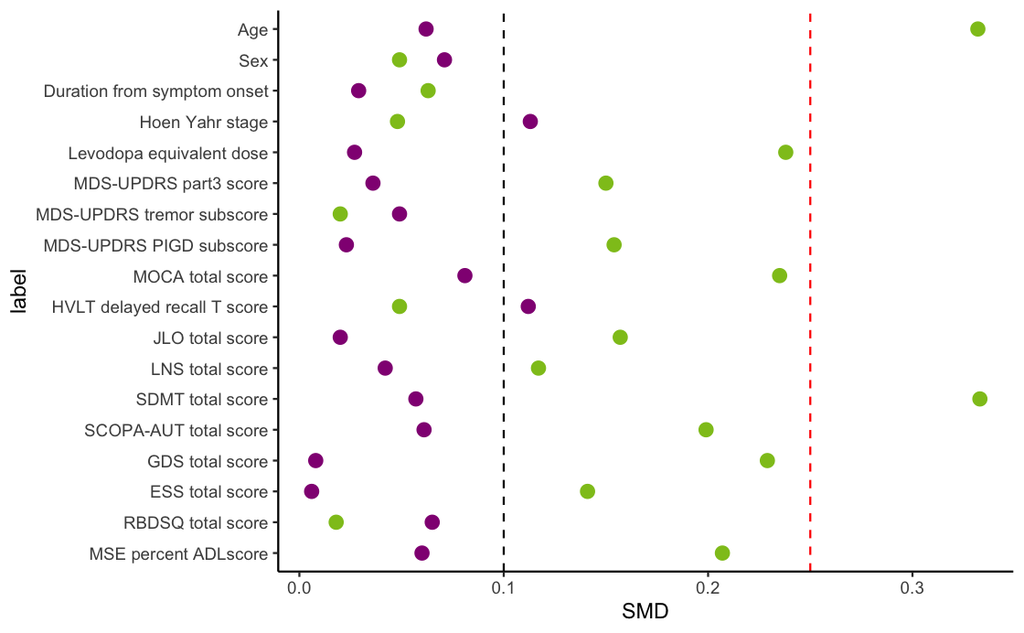

```r
Match_bef_SMD<-Match_bef_SMD %>% as_tibble() %>% cbind(label=rownames(Match_bef_SMD)) %>% as_tibble() ;Match_bef_SMD<-Match_bef_SMD[-1,];Match_bef_SMD$SMD<-as.numeric(Match_bef_SMD$SMD)
Match_SMD<-data.frame(label=Match_aft_SMD$label,BEF=Match_bef_SMD$SMD,AF=Match_aft_SMD$SMD);rm(Match_aft_SMD,Match_bef_SMD)
Match_SMD$label<-c("Age","Sex","Duration from symptom onset","Hoen Yahr stage","Levodopa equivalent dose","MDS-UPDRS part3 score","MDS-UPDRS tremor subscore","MDS-UPDRS PIGD subscore","MOCA total score","HVLT delayed recall T score","JLO total score","LNS total score","SDMT total score","SCOPA-AUT total score","GDS total score", "ESS total score","RBDSQ total score","MSE percent ADLscore")
Match_SMD$label<-factor(Match_SMD$label,level=rev(Match_SMD$label))
Match_SMD %>% tidyr::gather(key=PSM,value=SMD,BEF,AF) %>% ggplot(aes(x=SMD,y=label,colour=PSM)) + theme_classic() + geom_point(size=3) +scale_colour_discrete(name="",labels=c("After PSM","Before PSM"))+geom_vline(xintercept = 0.1,linetype="dashed", color = "black")  +geom_vline(xintercept = 0.25,linetype="dashed", color = "red") + scale_color_manual(values = c("#920783","#8FC31F"))+ theme(legend.position = "none")
```

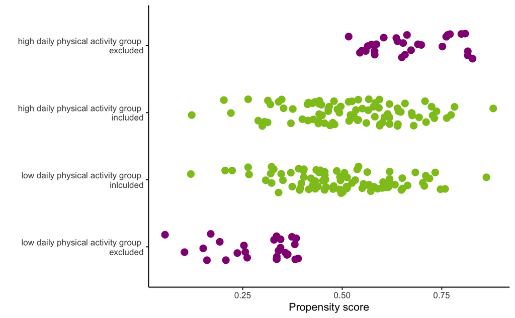

```r
Match_info <- data.frame(Match=match.obj$weights,Dichotomized=match.obj$treat,PS=match.obj$distance) %>% dplyr::mutate(Group=if_else(((Match==0)&(Dichotomized==1)),"above_discarded",if_else(((Match==0)&(Dichotomized==0)),"below_discarded",if_else(((Match==1)&(Dichotomized==1)),"above_adopted","below_adopted"))))  %>% as_tibble()
Match_info$Group<-factor(Match_info$Group,levels=c("below_discarded","below_adopted","above_adopted","above_discarded"))
Match_info$Match<-factor(Match_info$Match,levels=rev(unique(Match_info$Match)))
Match_info  %>% ggplot(aes(x=PS,y=Group,colour=Match)) + theme_classic() + geom_jitter(size=3,width=0.0,height=0.2)+scale_colour_discrete(name="",labels=c("After PSM","Before PSM"))+xlab("Propensity score")+scale_y_discrete(label=c("low daily physical activity group \n excluded","low daily physical activity group \n inlculded","high daily physical activity group \n included","high daily physical activity group \n excluded"))+ylab("")+ scale_color_manual(values = c("#920783","#8FC31F"),name="",label=c("",""))+ theme(legend.position = "none")
```

```r
d3<-d3 %>% dplyr::select(mean_AE_binary,Age,Sex,Disease_duration_symptom,NHY,LEDD_sum,sum_UPDRS_part3,sum_Tremor_score,sum_PIGD_score,MOCA_Total_score,HVLT_DELAYED_RECALL_T,JLO_RAW,LNS_RAW,SDMT_correct,SCOPA_total_score,GDS_total_score, ESS_total_score,RBDSQ_total_score,MSEADLG)
colnames(d3)<-c("mean PASE","Age","Sex","Duration from symptom onset","Hoen Yahr stage","Levodopa equivalent dose","MDS-UPDRS part3 score","MDS-UPDRS tremor subscore","MDS-UPDRS PIGD subscore","MOCA total score","HVLT delayed recall T score","JLO total score","LNS total score","SDMT total score","SCOPA-AUT total score","GDS total score", "ESS total score","RBDSQ total score","MSE percent ADLscore")
d3 %>% tbl_summary(by =`mean PASE`,type=list(`MDS-UPDRS PIGD subscore`~"continuous",`MSE percent ADLscore`~"continuous",`JLO total score`~"continuous",`Hoen Yahr stage`~"continuous",`Duration from symptom onset`~"continuous")) %>% add_p()
```

| **Characteristic** | **0-50**, N = 89<sup>1</sup> | **50-100**, N = 89<sup>1</sup> | **p-value**<sup>2</sup> |
| --- | --- | --- | --- |
| Age | 65 (56, 71) | 63 (55, 71) | 0.56 |
| Sex |  |  | 0.64 |
| Female | 29 (33%) | 32 (36%) |  |
| Male | 60 (67%) | 57 (64%) |  |
| Duration from symptom onset | 3.00 (2.00, 5.00) | 3.00 (3.00, 5.00) | 0.46 |
| Hoen Yahr stage | 2.00 (1.00, 2.00) | 2.00 (2.00, 2.00) | 0.49 |
| Levodopa equivalent dose | 150 (0, 300) | 100 (0, 262) | 0.35 |
| MDS-UPDRS part3 score | 26 (19, 33) | 24 (18, 34) | 0.69 |
| MDS-UPDRS tremor subscore | 6.0 (3.0, 10.0) | 7.0 (3.0, 10.0) | 0.73 |
| MDS-UPDRS PIGD subscore | 1.00 (1.00, 2.00) | 1.00 (1.00, 2.00) | 0.90 |
| MOCA total score | 26.00 (25.00, 29.00) | 27.00 (25.00, 28.00) | 0.74 |
| HVLT delayed recall T score | 45 (37, 53) | 48 (38, 55) | 0.39 |
| JLO total score | 26.0 (24.0, 28.0) | 26.0 (22.0, 28.0) | 0.94 |
| LNS total score | 11.00 (9.00, 12.00) | 10.00 (9.00, 12.00) | 0.62 |
| SDMT total score | 42 (35, 48) | 42 (36, 48) | 0.64 |
| SCOPA-AUT total score | 13 (9, 20) | 14 (7, 21) | 0.85 |
| GDS total score | 5.00 (5.00, 6.00) | 5.00 (5.00, 6.00) | 0.56 |
| ESS total score | 6.0 (4.0, 8.0) | 6.0 (3.0, 9.0) | 0.70 |
| RBDSQ total score | 5.00 (3.00, 7.00) | 5.00 (3.00, 7.00) | 0.79 |
| MSE percent ADLscore | 90 (80, 90) | 90 (85, 95) | 0.64 |

<sup>*1*</sup> Median (IQR); n (%) <sup>*2*</sup> Wilcoxon rank sum test; Pearson's Chi-squared test

```
 警告:  Removed 105 rows containing non-finite values (stat_smooth).
```

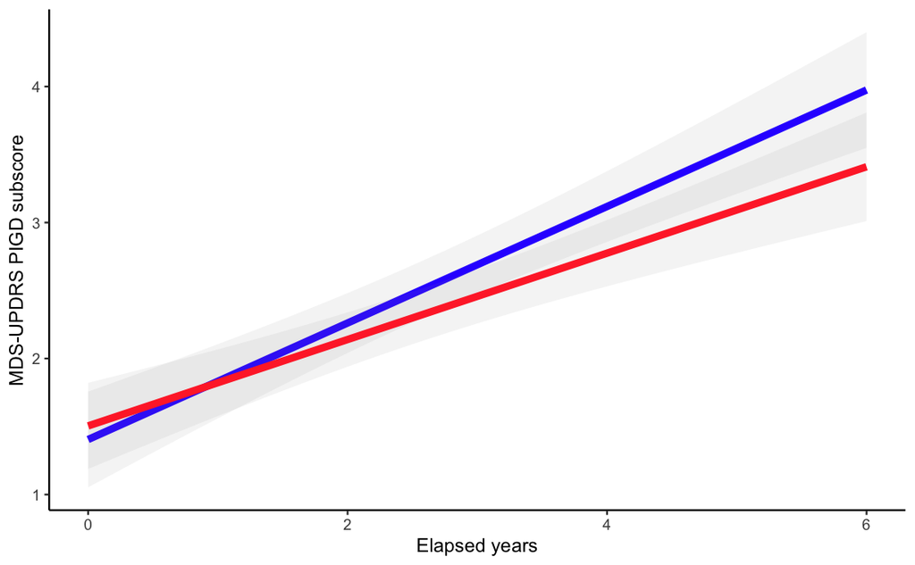

```r
d %>% filter(is.element(PATNO,d2$PATNO))->d4
d4 %>% filter(is.na(mean_AE_binary)==F) %>% ggplot(aes(x=Elapsed_months_2/12,y=sum_PIGD_score,colour=mean_AE_binary))+theme_classic()+stat_smooth(se=T,fullrange = F,level = 0.95,method=lm,alpha=0.1,size=2)+ylab("MDS-UPDRS PIGD subscore")+xlab("Elapsed years")+scale_colour_discrete(labels=c("Below","Above"),name=expression(atop("Average PASE","total score")))+xlim(c(0,6))+scale_color_manual(values = c("#3232FF","#FF3232"))+ theme(legend.position = "none")
```

```r
a<-d4 %>% dplyr::select(Elapsed_months_2,Age,sum_PIGD_score,MSEADLG,mean_AE_binary,SDMT_correct,PATNO,Sex,LEDD_sum,Disease_duration_symptom)
c<-c()
p.value<-c()
Partner<-c()
Quantile<-c()
confint_sum<-c()
a$mean_AE_binary<-as.factor(a$mean_AE_binary)
for(i in colnames(a)){
  if((i!="Elapsed_months_2")&(i!="mean_AE_binary")&(i!="Age")&(i!="PATNO")&(i!="Sex")&(i!="LEDD_sum")&(i!="Disease_duration_symptom")){
    a %>% dplyr::select(i,Elapsed_months_2,mean_AE_binary,Age,PATNO,Sex,LEDD_sum,Disease_duration_symptom)->a1;
    colnames(a1)<-c("V1","Elapsed_months_2","mean_AE_categorize","Age","PATNO","Sex","LEDD_sum","Disease_duration_symptom");
    a1$V1<-scale(a1$V1,center=T,scale=T);
    a1$Age<-scale(a1$Age,center=T,scale=T);
    a1$Elapsed_months_2<-scale(a1$Elapsed_months_2,center=T,scale=T);
    a1$LEDD_sum<-scale(a1$LEDD_sum,center=T,scale=T);
    a1$Disease_duration_symptom<-scale(a1$Disease_duration_symptom,center=T,scale=T);
    with(a1,lmer(V1~Elapsed_months_2*mean_AE_categorize+Age+LEDD_sum+Disease_duration_symptom+Sex+(1+Elapsed_months_2|PATNO),REML=FALSE))->b;
    summary(b)->b.summary;confint(b,method="b",nsim=1000) %>% suppressMessages()->b.confint;
    b.summary$coefficients[8,]->d;
    bind_rows(c,d) %>% suppressMessages()->c;
    with(a1,lmer(V1~Elapsed_months_2+mean_AE_categorize+Age+LEDD_sum+Disease_duration_symptom+Sex+(1+Elapsed_months_2|PATNO),REML=FALSE))->b.null;
    anova(b,b.null)->d
    append(p.value,d$`Pr(>Chisq)`[2])->p.value;
    append(Partner,i)->Partner;
    confint_sum<-bind_rows(confint_sum,b.confint[10,]) %>% as_tibble()
  }}
cbind(Partner,confint_sum,p.value) %>% cbind(c)->interaction_effect_table_mean_AE_categorize
write_csv(interaction_effect_table_mean_AE_categorize,"interaction_effect_table_mean_AE_categorize.csv")
```

```r
##Work_median
d<-UPDRS_PASE_MOCA_ESS_MSEADL_RBDSQ_SCOPA_HVLT_JLO_LNS_SDMT_GDS_PD %>% filter(is.na(mean_PASE_Total_score)==F) %>% filter(Elapsed_months_2==0)

c<-c()
for(i in unique(UPDRS_PASE_MOCA_ESS_MSEADL_RBDSQ_SCOPA_HVLT_JLO_LNS_SDMT_GDS_PD$PATNO)){
  UPDRS_PASE_MOCA_ESS_MSEADL_RBDSQ_SCOPA_HVLT_JLO_LNS_SDMT_GDS_PD %>% filter(PATNO==i) -> a;
  if ((nrow(a)>=3)){
    if(mean(a$PASE_Work_score,na.rm = T)>=quantile(d$mean_PASE_Work_score,na.rm=T,0.75))(append(c,rep("50-100",nrow(a)))->c)else{
      if(mean(a$PASE_Work_score,na.rm = T)>=quantile(d$mean_PASE_Work_score,na.rm=T,0.5))(append(c,rep("50-100",nrow(a)))->c)else{
        if(mean(a$PASE_Work_score,na.rm = T)>=quantile(d$mean_PASE_Work_score,na.rm=T,0.25))(append(c,rep("0-50",nrow(a)))->c)else(append(c,rep("0-50",nrow(a)))->c)}}}
  else(append(c,rep(NA,nrow(a)))->c)
}
c->mean_PASE_Work_score_binary

d<-cbind(UPDRS_PASE_MOCA_ESS_MSEADL_RBDSQ_SCOPA_HVLT_JLO_LNS_SDMT_GDS_PD,mean_PASE_Total_score_binary,mean_AE_binary,mean_PASE_Work_score_binary)

d %>% filter(Elapsed_months_2==0) %>% filter(is.na(sum_UPDRS_part3)==F) %>% filter(is.na(mean_PASE_Total_score_binary)==F) ->d1
d1$mean_PASE_Work_score_binary<-as.factor(d1$mean_PASE_Work_score_binary)
d1$Sex<-as.factor(d1$Sex)
d1 %>% dplyr::select(PATNO,mean_PASE_Work_score_binary,Age,Sex,MOCA_Total_score,Disease_duration_symptom,sum_UPDRS_part3,sum_PIGD_score,LEDD_sum,MSEADLG,GDS_total_score,LNS_RAW,sum_Tremor_score,SDMT_correct,NHY,HVLT_DELAYED_RECALL_T,JLO_RAW,SCOPA_total_score) %>% na.omit() -> d1
MatchIt::matchit(mean_PASE_Work_score_binary ~ Age + Sex + MOCA_Total_score + Disease_duration_symptom + sum_UPDRS_part3 + sum_PIGD_score +LEDD_sum+MSEADLG+GDS_total_score+LNS_RAW+sum_Tremor_score+SDMT_correct+NHY+HVLT_DELAYED_RECALL_T+JLO_RAW+SCOPA_total_score, data=d1,  distance="logit", method = "nearest",replace=FALSE) %>% suppressMessages()->match.obj
d1$PS<-match.obj$distance
logitPS<-log(1/d1$PS-1)

MatchIt::matchit(mean_PASE_Work_score_binary ~ Age + Sex + MOCA_Total_score + Disease_duration_symptom + sum_UPDRS_part3 + sum_PIGD_score+LEDD_sum+MSEADLG+GDS_total_score+LNS_RAW+sum_Tremor_score+SDMT_correct+NHY+HVLT_DELAYED_RECALL_T+JLO_RAW+SCOPA_total_score, data=d1, distance="logit", method = "nearest",replace=FALSE,caliper =  0.25*sd(logitPS))->match.obj
d2<-match.data(match.obj)
d3 <- d %>% filter(Elapsed_months_2==0) %>% filter(is.element(PATNO,d2$PATNO))

Match_aft_SMD<-CreateTableOne(strata="mean_PASE_Work_score_binary",var=c("Age","Sex","Disease_duration_symptom","NHY","LEDD_sum","sum_UPDRS_part3","sum_Tremor_score","sum_PIGD_score","MOCA_Total_score","HVLT_DELAYED_RECALL_T","JLO_RAW","LNS_RAW","SDMT_correct","SCOPA_total_score","GDS_total_score", "ESS_total_score","RBDSQ_total_score","MSEADLG"),test=F,smd=T,data=d3) %>% print(smd=T)
```

```
                                      Stratified by mean_PASE_Work_score_binary
                                       0-50            50-100          SMD
  n                                        79              79
  Age (mean (SD))                       64.68 (8.95)    63.05 (7.92)    0.193
  Sex = Male (%)                           57 (72.2)       54 (68.4)    0.083
  Disease_duration_symptom (mean (SD))   3.84 (1.64)     3.72 (1.68)    0.069
  NHY (mean (SD))                        1.75 (0.49)     1.78 (0.47)    0.079
  LEDD_sum (mean (SD))                 233.65 (362.46) 253.54 (435.86)  0.050
  sum_UPDRS_part3 (mean (SD))           27.15 (12.66)   27.10 (10.69)   0.004
  sum_Tremor_score (mean (SD))           6.82 (4.94)     7.10 (3.92)    0.062
  sum_PIGD_score (mean (SD))             1.48 (1.13)     1.56 (1.31)    0.062
  MOCA_Total_score (mean (SD))          26.14 (2.68)    26.57 (2.48)    0.167
  HVLT_DELAYED_RECALL_T (mean (SD))     44.99 (11.79)   45.97 (10.98)   0.087
  JLO_RAW (mean (SD))                   25.44 (5.04)    25.47 (4.50)    0.005
  LNS_RAW (mean (SD))                   10.70 (2.42)    10.81 (2.76)    0.044
  SDMT_correct (mean (SD))              40.73 (10.23)   40.46 (8.77)    0.029
  SCOPA_total_score (mean (SD))         14.56 (10.95)   14.94 (8.33)    0.039
  GDS_total_score (mean (SD))            5.33 (1.47)     5.57 (1.46)    0.164
  ESS_total_score (mean (SD))            6.71 (4.44)     6.35 (3.71)    0.087
  RBDSQ_total_score (mean (SD))          5.24 (3.10)     5.37 (2.73)    0.043
  MSEADLG (mean (SD))                   89.62 (6.69)    90.00 (6.75)    0.057
```

```r
Match_aft_SMD<-Match_aft_SMD %>% as_tibble() %>% cbind(label=rownames(Match_aft_SMD)) %>% as_tibble() ;Match_aft_SMD<-Match_aft_SMD[-1,];Match_aft_SMD$SMD<-as.numeric(Match_aft_SMD$SMD) %>% suppressMessages()
d %>% filter(Elapsed_months_2==0) %>% filter(is.na(sum_UPDRS_part3)==F) %>% filter(is.na(mean_PASE_Work_score_binary)==F) ->d1
Match_bef_SMD<-CreateTableOne(strata="mean_PASE_Work_score_binary",var=c("Age","Sex","Disease_duration_symptom","NHY","LEDD_sum","sum_UPDRS_part3","sum_Tremor_score","sum_PIGD_score","MOCA_Total_score","HVLT_DELAYED_RECALL_T","JLO_RAW","LNS_RAW","SDMT_correct","SCOPA_total_score","GDS_total_score", "ESS_total_score","RBDSQ_total_score","MSEADLG"),test=F,smd=T,data=d1) %>% print(smd=T)
```

```
                                      Stratified by mean_PASE_Work_score_binary
                                       0-50            50-100          SMD
  n                                       118             119
  Age (mean (SD))                       66.78 (9.15)    59.21 (9.41)    0.816
  Sex = Male (%)                           79 (66.9)       85 (71.4)    0.097
  Disease_duration_symptom (mean (SD))   4.03 (2.57)     3.50 (1.66)    0.249
  NHY (mean (SD))                        1.81 (0.51)     1.75 (0.47)    0.116
  LEDD_sum (mean (SD))                 214.82 (320.96) 226.42 (384.16)  0.033
  sum_UPDRS_part3 (mean (SD))           27.59 (11.86)   25.34 (10.65)   0.199
  sum_Tremor_score (mean (SD))           6.44 (4.75)     6.76 (4.18)    0.072
  sum_PIGD_score (mean (SD))             1.86 (1.64)     1.41 (1.22)    0.308
  MOCA_Total_score (mean (SD))          25.67 (2.89)    26.91 (2.35)    0.470
  HVLT_DELAYED_RECALL_T (mean (SD))     43.39 (12.46)   46.98 (10.44)   0.313
  JLO_RAW (mean (SD))                   25.01 (5.04)    25.93 (4.08)    0.202
  LNS_RAW (mean (SD))                   10.22 (2.62)    11.18 (2.59)    0.367
  SDMT_correct (mean (SD))              38.75 (10.80)   43.29 (9.19)    0.453
  SCOPA_total_score (mean (SD))         16.19 (10.57)   12.83 (8.00)    0.358
  GDS_total_score (mean (SD))            5.44 (1.56)     5.44 (1.33)    0.001
  ESS_total_score (mean (SD))            6.76 (4.31)     5.95 (3.61)    0.205
  RBDSQ_total_score (mean (SD))          5.48 (3.11)     5.24 (2.78)    0.081
  MSEADLG (mean (SD))                   88.21 (7.70)    89.96 (6.72)    0.243
```

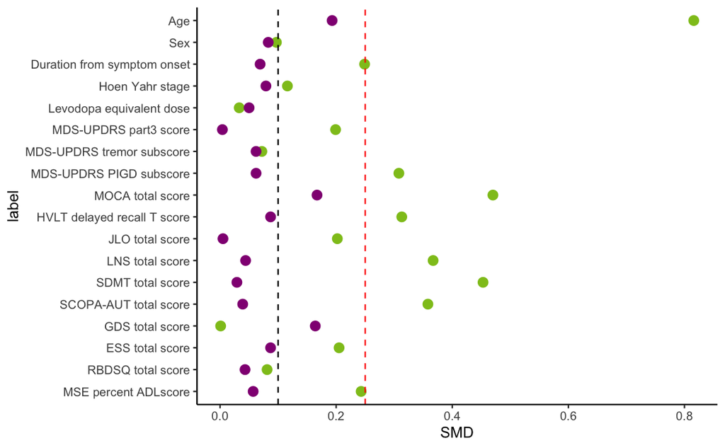

```r
Match_bef_SMD<-Match_bef_SMD %>% as_tibble() %>% cbind(label=rownames(Match_bef_SMD)) %>% as_tibble() ;Match_bef_SMD<-Match_bef_SMD[-1,];Match_bef_SMD$SMD<-as.numeric(Match_bef_SMD$SMD)
Match_SMD<-data.frame(label=Match_aft_SMD$label,BEF=Match_bef_SMD$SMD,AF=Match_aft_SMD$SMD);rm(Match_aft_SMD,Match_bef_SMD)
Match_SMD$label<-c("Age","Sex","Duration from symptom onset","Hoen Yahr stage","Levodopa equivalent dose","MDS-UPDRS part3 score","MDS-UPDRS tremor subscore","MDS-UPDRS PIGD subscore","MOCA total score","HVLT delayed recall T score","JLO total score","LNS total score","SDMT total score","SCOPA-AUT total score","GDS total score", "ESS total score","RBDSQ total score","MSE percent ADLscore")
Match_SMD$label<-factor(Match_SMD$label,level=rev(Match_SMD$label))
Match_SMD %>% tidyr::gather(key=PSM,value=SMD,BEF,AF) %>% ggplot(aes(x=SMD,y=label,colour=PSM)) + theme_classic() + geom_point(size=3) +scale_colour_discrete(name="",labels=c("After PSM","Before PSM"))+geom_vline(xintercept = 0.1,linetype="dashed", color = "black")  +geom_vline(xintercept = 0.25,linetype="dashed", color = "red") + scale_color_manual(values = c("#920783","#8FC31F"))+ theme(legend.position = "none")
```

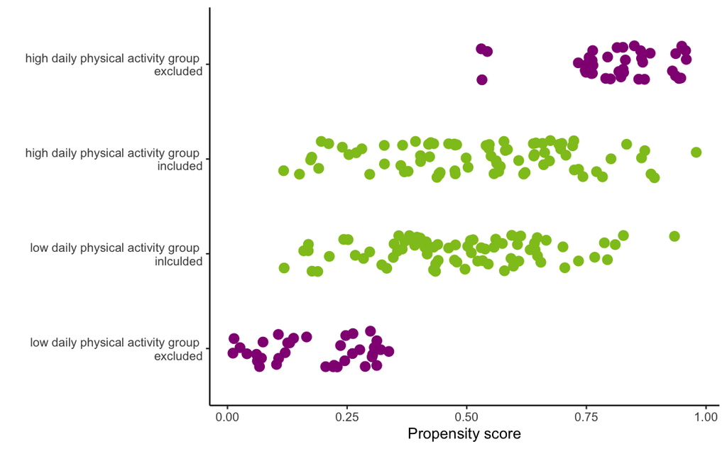

```r
Match_info <- data.frame(Match=match.obj$weights,Dichotomized=match.obj$treat,PS=match.obj$distance) %>% dplyr::mutate(Group=if_else(((Match==0)&(Dichotomized==1)),"above_discarded",if_else(((Match==0)&(Dichotomized==0)),"below_discarded",if_else(((Match==1)&(Dichotomized==1)),"above_adopted","below_adopted"))))  %>% as_tibble()
Match_info$Group<-factor(Match_info$Group,levels=c("below_discarded","below_adopted","above_adopted","above_discarded"))
Match_info$Match<-factor(Match_info$Match,levels=rev(unique(Match_info$Match)))
Match_info  %>% ggplot(aes(x=PS,y=Group,colour=Match)) + theme_classic() + geom_jitter(size=3,width=0.0,height=0.2)+scale_colour_discrete(name="",labels=c("After PSM","Before PSM"))+xlab("Propensity score")+scale_y_discrete(label=c("low daily physical activity group \n excluded","low daily physical activity group \n inlculded","high daily physical activity group \n included","high daily physical activity group \n excluded"))+ylab("")+ scale_color_manual(values = c("#920783","#8FC31F"),name="",label=c("",""))+ theme(legend.position = "none")
```

```r
d3<-d3 %>% dplyr::select(mean_PASE_Work_score_binary,Age,Sex,Disease_duration_symptom,NHY,LEDD_sum,sum_UPDRS_part3,sum_Tremor_score,sum_PIGD_score,MOCA_Total_score,HVLT_DELAYED_RECALL_T,JLO_RAW,LNS_RAW,SDMT_correct,SCOPA_total_score,GDS_total_score, ESS_total_score,RBDSQ_total_score,MSEADLG)
colnames(d3)<-c("mean PASE","Age","Sex","Duration from symptom onset","Hoen Yahr stage","Levodopa equivalent dose","MDS-UPDRS part3 score","MDS-UPDRS tremor subscore","MDS-UPDRS PIGD subscore","MOCA total score","HVLT delayed recall T score","JLO total score","LNS total score","SDMT total score","SCOPA-AUT total score","GDS total score", "ESS total score","RBDSQ total score","MSE percent ADLscore")
d3 %>% tbl_summary(by =`mean PASE`,type=list(`MDS-UPDRS PIGD subscore`~"continuous",`MSE percent ADLscore`~"continuous",`JLO total score`~"continuous",`Hoen Yahr stage`~"continuous",`Duration from symptom onset`~"continuous")) %>% add_p()
```

| **Characteristic** | **0-50**, N = 79<sup>1</sup> | **50-100**, N = 79<sup>1</sup> | **p-value**<sup>2</sup> |
| --- | --- | --- | --- |
| Age | 65 (60, 72) | 63 (58, 68) | 0.15 |
| Sex |  |  | 0.60 |
| Female | 22 (28%) | 25 (32%) |  |
| Male | 57 (72%) | 54 (68%) |  |
| Duration from symptom onset | 4.00 (3.00, 5.00) | 3.00 (3.00, 5.00) | 0.51 |
| Hoen Yahr stage | 2.00 (1.00, 2.00) | 2.00 (2.00, 2.00) | 0.61 |
| Levodopa equivalent dose | 100 (0, 300) | 100 (0, 281) | 0.88 |
| MDS-UPDRS part3 score | 26 (16, 35) | 26 (19, 36) | 0.98 |
| MDS-UPDRS tremor subscore | 6.0 (3.0, 10.5) | 7.0 (4.0, 10.0) | 0.51 |
| MDS-UPDRS PIGD subscore | 1.00 (1.00, 2.00) | 1.00 (1.00, 2.00) | 0.90 |
| MOCA total score | 27.00 (24.50, 28.00) | 27.00 (25.00, 28.00) | 0.37 |
| HVLT delayed recall T score | 47 (37, 53) | 47 (38, 55) | 0.63 |
| JLO total score | 28.0 (24.0, 30.0) | 28.0 (22.0, 28.0) | 0.80 |
| LNS total score | 11.00 (9.00, 12.00) | 11.00 (9.00, 12.00) | 0.73 |
| SDMT total score | 42 (34, 48) | 39 (35, 48) | 0.61 |
| SCOPA-AUT total score | 12 (7, 19) | 14 (9, 21) | 0.37 |
| GDS total score | 5.00 (5.00, 6.00) | 5.00 (5.00, 6.00) | 0.35 |
| ESS total score | 6.0 (4.0, 9.0) | 6.0 (4.0, 9.0) | 0.86 |
| RBDSQ total score | 4.00 (3.00, 8.00) | 5.00 (3.50, 7.00) | 0.41 |
| MSE percent ADLscore | 90 (90, 92) | 90 (90, 95) | 0.64 |

<sup>*1*</sup> Median (IQR); n (%) <sup>*2*</sup> Wilcoxon rank sum test; Pearson's Chi-squared test

```
 警告:  Removed 4 rows containing non-finite values (stat_smooth).
```

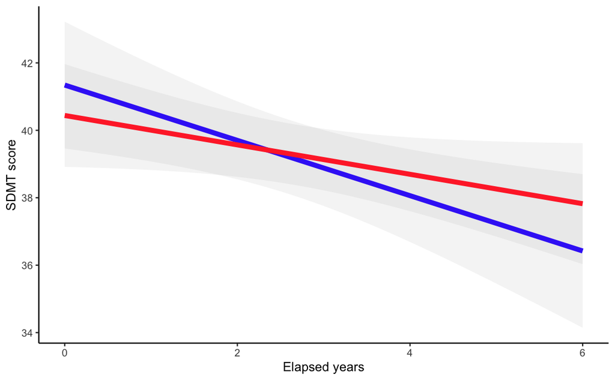

```r
d %>% filter(is.element(PATNO,d2$PATNO))->d4
d4 %>% filter(is.na(mean_PASE_Work_score_binary)==F) %>% ggplot(aes(x=Elapsed_months_2/12,y=SDMT_correct,colour=mean_PASE_Work_score_binary))+theme_classic()+stat_smooth(se=T,fullrange = T,level = 0.95,method=lm,alpha=0.1,size=2)+ylab("SDMT score")+xlab("Elapsed years")+scale_colour_discrete(labels=c("Below","Above"),name=expression(atop("Average PASE","total score")))+xlim(c(0,6))+scale_color_manual(values = c("#3232FF","#FF3232"))+ theme(legend.position = "none")
```

```r
a<-d4 %>% dplyr::select(Elapsed_months_2,Age,sum_PIGD_score,MSEADLG,mean_PASE_Work_score_binary,SDMT_correct,PATNO,Sex,LEDD_sum,Disease_duration_symptom)
c<-c()
p.value<-c()
Partner<-c()
Quantile<-c()
confint_sum<-c()
a$mean_PASE_Work_score_binary<-as.factor(a$mean_PASE_Work_score_binary)
for(i in colnames(a)){
  if((i!="Elapsed_months_2")&(i!="mean_PASE_Work_score_binary")&(i!="Age")&(i!="PATNO")&(i!="Sex")&(i!="LEDD_sum")&(i!="Disease_duration_symptom")){
    a %>% dplyr::select(i,Elapsed_months_2,mean_PASE_Work_score_binary,Age,PATNO,Sex,LEDD_sum,Disease_duration_symptom)->a1;
    colnames(a1)<-c("V1","Elapsed_months_2","mean_PASE_Work_score_categorize","Age","PATNO","Sex","LEDD_sum","Disease_duration_symptom");
    a1$V1<-scale(a1$V1,center=T,scale=T);
    a1$Age<-scale(a1$Age,center=T,scale=T);
    a1$Elapsed_months_2<-scale(a1$Elapsed_months_2,center=T,scale=T);
    a1$LEDD_sum<-scale(a1$LEDD_sum,center=T,scale=T);
    a1$Disease_duration_symptom<-scale(a1$Disease_duration_symptom,center=T,scale=T);
    with(a1,lmer(V1~Elapsed_months_2*mean_PASE_Work_score_categorize+Age+LEDD_sum+Disease_duration_symptom+Sex+(1+Elapsed_months_2|PATNO),REML=FALSE))->b;
    summary(b)->b.summary;confint(b,method="b",nsim=1000) %>% suppressMessages()->b.confint;
    b.summary$coefficients[8,]->d;
    bind_rows(c,d) %>% suppressMessages()->c;
    with(a1,lmer(V1~Elapsed_months_2+mean_PASE_Work_score_categorize+Age+LEDD_sum+Disease_duration_symptom+Sex+(1+Elapsed_months_2|PATNO),REML=FALSE))->b.null;
    anova(b,b.null)->d
    append(p.value,d$`Pr(>Chisq)`[2])->p.value;
    append(Partner,i)->Partner;
    confint_sum<-bind_rows(confint_sum,b.confint[10,]) %>% as_tibble()
  }}
cbind(Partner,confint_sum,p.value) %>% cbind(c)->interaction_effect_table_mean_PASE_Work_score_categorize

write_csv(interaction_effect_table_mean_PASE_Work_score_categorize,"interaction_effect_table_mean_PASE_Work_score_categorize.csv")
```

```r
##Work_0.75
d<-UPDRS_PASE_MOCA_ESS_MSEADL_RBDSQ_SCOPA_HVLT_JLO_LNS_SDMT_GDS_PD %>% filter(is.na(mean_PASE_Total_score)==F) %>% filter(Elapsed_months_2==0)
c<-c()
for(i in unique(UPDRS_PASE_MOCA_ESS_MSEADL_RBDSQ_SCOPA_HVLT_JLO_LNS_SDMT_GDS_PD$PATNO)){
  UPDRS_PASE_MOCA_ESS_MSEADL_RBDSQ_SCOPA_HVLT_JLO_LNS_SDMT_GDS_PD %>% filter(PATNO==i) -> a;
  if ((nrow(a)>=3)){
    if(mean(a$PASE_Work_score,na.rm = T)>=quantile(d$mean_PASE_Work_score,na.rm=T,0.75))(append(c,rep("75-100",nrow(a)))->c)else{
      if(mean(a$PASE_Work_score,na.rm = T)>=quantile(d$mean_PASE_Work_score,na.rm=T,0.5))(append(c,rep("0-75",nrow(a)))->c)else{
        if(mean(a$PASE_Work_score,na.rm = T)>=quantile(d$mean_PASE_Work_score,na.rm=T,0.25))(append(c,rep("0-75",nrow(a)))->c)else(append(c,rep("0-50",nrow(a)))->c)}}}
  else(append(c,rep(NA,nrow(a)))->c)
}
c->mean_PASE_Work_score_binary

d<-cbind(UPDRS_PASE_MOCA_ESS_MSEADL_RBDSQ_SCOPA_HVLT_JLO_LNS_SDMT_GDS_PD,mean_PASE_Work_score_binary)

d %>% filter(Elapsed_months_2==0) %>% filter(is.na(sum_UPDRS_part3)==F) %>% filter(is.na(mean_PASE_Work_score_binary)==F) ->d1
d1$mean_PASE_Work_score_binary<-as.factor(d1$mean_PASE_Work_score_binary)
d1$Sex<-as.factor(d1$Sex)
d1 %>% dplyr::select(PATNO,mean_PASE_Work_score_binary,Age,Sex,MOCA_Total_score,Disease_duration_symptom,sum_UPDRS_part3,sum_PIGD_score,LEDD_sum,MSEADLG,GDS_total_score,LNS_RAW,sum_Tremor_score,SDMT_correct,NHY,HVLT_DELAYED_RECALL_T,JLO_RAW,SCOPA_total_score) %>% na.omit() -> d1
MatchIt::matchit(mean_PASE_Work_score_binary ~ Age + Sex + MOCA_Total_score + Disease_duration_symptom + sum_UPDRS_part3 + sum_PIGD_score +LEDD_sum+MSEADLG+GDS_total_score+LNS_RAW+sum_Tremor_score+SDMT_correct+NHY+HVLT_DELAYED_RECALL_T+JLO_RAW+SCOPA_total_score, data=d1,  distance="logit", method = "nearest",replace=FALSE) %>% suppressMessages()->match.obj
d1$PS<-match.obj$distance
logitPS<-log(1/d1$PS-1)

MatchIt::matchit(mean_PASE_Work_score_binary ~ Age + Sex + MOCA_Total_score + Disease_duration_symptom + sum_UPDRS_part3 + sum_PIGD_score+LEDD_sum+MSEADLG+GDS_total_score+LNS_RAW+sum_Tremor_score+SDMT_correct+NHY+HVLT_DELAYED_RECALL_T+JLO_RAW+SCOPA_total_score, data=d1, distance="logit", method = "nearest",replace=FALSE,caliper =  0.25*sd(logitPS))->match.obj
d2<-match.data(match.obj)
d3 <- d %>% filter(Elapsed_months_2==0) %>% filter(is.element(PATNO,d2$PATNO))

Match_aft_SMD<-CreateTableOne(strata="mean_PASE_Work_score_binary",var=c("Age","Sex","Disease_duration_symptom","NHY","LEDD_sum","sum_UPDRS_part3","sum_Tremor_score","sum_PIGD_score","MOCA_Total_score","HVLT_DELAYED_RECALL_T","JLO_RAW","LNS_RAW","SDMT_correct","SCOPA_total_score","GDS_total_score", "ESS_total_score","RBDSQ_total_score","MSEADLG"),test=F,smd=T,data=d3) %>% print(smd=T)
```

```
                                      Stratified by mean_PASE_Work_score_binary
                                       0-75            75-100          SMD
  n                                        50              50
  Age (mean (SD))                       59.26 (10.64)   58.24 (8.47)    0.106
  Sex = Male (%)                           38 (76.0)       39 (78.0)    0.048
  Disease_duration_symptom (mean (SD))   3.48 (1.47)     3.26 (1.51)    0.147
  NHY (mean (SD))                        1.72 (0.45)     1.70 (0.46)    0.044
  LEDD_sum (mean (SD))                 221.60 (356.84) 224.21 (377.96)  0.007
  sum_UPDRS_part3 (mean (SD))           25.12 (10.57)   24.28 (10.03)   0.082
  sum_Tremor_score (mean (SD))           7.46 (4.47)     6.92 (4.13)    0.126
  sum_PIGD_score (mean (SD))             1.32 (0.94)     1.30 (1.25)    0.018
  MOCA_Total_score (mean (SD))          26.96 (2.37)    27.00 (2.30)    0.017
  HVLT_DELAYED_RECALL_T (mean (SD))     47.80 (11.61)   46.00 (9.91)    0.167
  JLO_RAW (mean (SD))                   26.60 (3.00)    25.76 (4.03)    0.236
  LNS_RAW (mean (SD))                   11.50 (2.37)    11.54 (2.43)    0.017
  SDMT_correct (mean (SD))              42.96 (9.63)    43.40 (7.87)    0.050
  SCOPA_total_score (mean (SD))         11.80 (8.42)    12.48 (8.26)    0.082
  GDS_total_score (mean (SD))            5.24 (1.42)     5.36 (1.14)    0.093
  ESS_total_score (mean (SD))            5.66 (3.51)     6.18 (3.55)    0.147
  RBDSQ_total_score (mean (SD))          4.94 (2.67)     5.20 (2.90)    0.093
  MSEADLG (mean (SD))                   89.70 (6.26)    90.40 (6.91)    0.106
```

```r
Match_aft_SMD<-Match_aft_SMD %>% as_tibble() %>% cbind(label=rownames(Match_aft_SMD)) %>% as_tibble() ;Match_aft_SMD<-Match_aft_SMD[-1,];Match_aft_SMD$SMD<-as.numeric(Match_aft_SMD$SMD) %>% suppressMessages()
d %>% filter(Elapsed_months_2==0) %>% filter(is.na(sum_UPDRS_part3)==F) %>% filter(is.na(mean_PASE_Work_score_binary)==F) ->d1
Match_bef_SMD<-CreateTableOne(strata="mean_PASE_Work_score_binary",var=c("Age","Sex","Disease_duration_symptom","NHY","LEDD_sum","sum_UPDRS_part3","sum_Tremor_score","sum_PIGD_score","MOCA_Total_score","HVLT_DELAYED_RECALL_T","JLO_RAW","LNS_RAW","SDMT_correct","SCOPA_total_score","GDS_total_score", "ESS_total_score","RBDSQ_total_score","MSEADLG"),test=F,smd=T,data=d1) %>% print(smd=T)
```

```
                                      Stratified by mean_PASE_Work_score_binary
                                       0-75            75-100          SMD
  n                                       177              60
  Age (mean (SD))                       65.04 (9.47)    56.90 (9.09)    0.877
  Sex = Male (%)                          116 (65.5)       48 (80.0)    0.329
  Disease_duration_symptom (mean (SD))   3.92 (2.31)     3.30 (1.63)    0.310
  NHY (mean (SD))                        1.81 (0.49)     1.67 (0.48)    0.303
  LEDD_sum (mean (SD))                 224.16 (354.73) 210.26 (352.21)  0.039
  sum_UPDRS_part3 (mean (SD))           27.46 (11.48)   23.52 (10.30)   0.362
  sum_Tremor_score (mean (SD))           6.59 (4.51)     6.63 (4.36)    0.009
  sum_PIGD_score (mean (SD))             1.79 (1.51)     1.18 (1.20)    0.442
  MOCA_Total_score (mean (SD))          25.95 (2.75)    27.28 (2.27)    0.527
  HVLT_DELAYED_RECALL_T (mean (SD))     44.73 (12.22)   46.55 (9.53)    0.166
  JLO_RAW (mean (SD))                   25.25 (4.81)    26.13 (3.84)    0.203
  LNS_RAW (mean (SD))                   10.33 (2.55)    11.80 (2.63)    0.569
  SDMT_correct (mean (SD))              39.99 (10.50)   44.07 (8.93)    0.418
  SCOPA_total_score (mean (SD))         15.32 (9.83)    12.07 (8.01)    0.363
  GDS_total_score (mean (SD))            5.49 (1.53)     5.27 (1.15)    0.168
  ESS_total_score (mean (SD))            6.43 (4.13)     6.13 (3.55)    0.077
  RBDSQ_total_score (mean (SD))          5.32 (2.97)     5.48 (2.88)    0.055
  MSEADLG (mean (SD))                   88.55 (7.37)    90.67 (6.73)    0.300
```

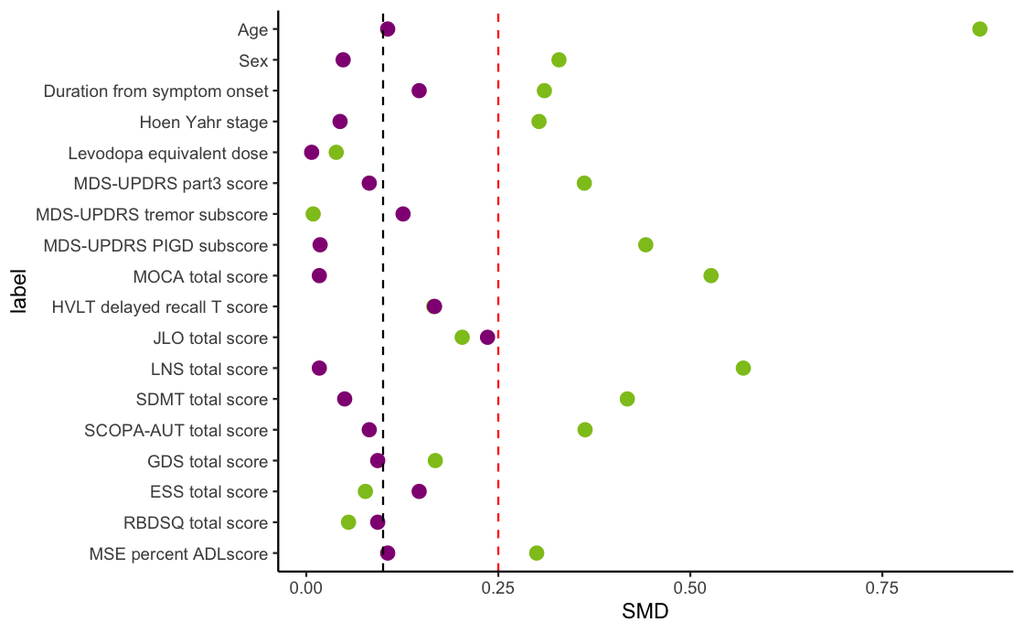

```r
Match_bef_SMD<-Match_bef_SMD %>% as_tibble() %>% cbind(label=rownames(Match_bef_SMD)) %>% as_tibble() ;Match_bef_SMD<-Match_bef_SMD[-1,];Match_bef_SMD$SMD<-as.numeric(Match_bef_SMD$SMD)
Match_SMD<-data.frame(label=Match_aft_SMD$label,BEF=Match_bef_SMD$SMD,AF=Match_aft_SMD$SMD);rm(Match_aft_SMD,Match_bef_SMD)
Match_SMD$label<-c("Age","Sex","Duration from symptom onset","Hoen Yahr stage","Levodopa equivalent dose","MDS-UPDRS part3 score","MDS-UPDRS tremor subscore","MDS-UPDRS PIGD subscore","MOCA total score","HVLT delayed recall T score","JLO total score","LNS total score","SDMT total score","SCOPA-AUT total score","GDS total score", "ESS total score","RBDSQ total score","MSE percent ADLscore")
Match_SMD$label<-factor(Match_SMD$label,level=rev(Match_SMD$label))
Match_SMD %>% tidyr::gather(key=PSM,value=SMD,BEF,AF) %>% ggplot(aes(x=SMD,y=label,colour=PSM)) + theme_classic() + geom_point(size=3) +scale_colour_discrete(name="",labels=c("After PSM","Before PSM"))+geom_vline(xintercept = 0.1,linetype="dashed", color = "black")  +geom_vline(xintercept = 0.25,linetype="dashed", color = "red") + scale_color_manual(values = c("#920783","#8FC31F"))+ theme(legend.position = "none")
```

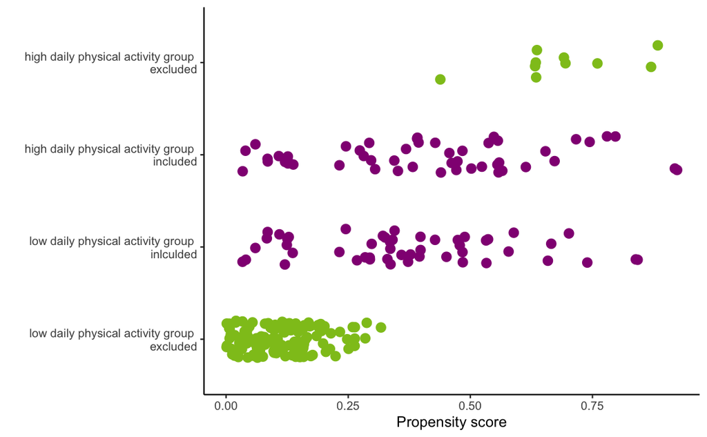

```r
Match_info <- data.frame(Match=match.obj$weights,Dichotomized=match.obj$treat,PS=match.obj$distance) %>% dplyr::mutate(Group=if_else(((Match==0)&(Dichotomized==1)),"above_discarded",if_else(((Match==0)&(Dichotomized==0)),"below_discarded",if_else(((Match==1)&(Dichotomized==1)),"above_adopted","below_adopted"))))  %>% as_tibble()
Match_info$Group<-factor(Match_info$Group,levels=c("below_discarded","below_adopted","above_adopted","above_discarded"))
Match_info$Match<-factor(Match_info$Match,levels=rev(unique(Match_info$Match)))
Match_info  %>% ggplot(aes(x=PS,y=Group,colour=Match)) + theme_classic() + geom_jitter(size=3,width=0.0,height=0.2)+scale_colour_discrete(name="",labels=c("After PSM","Before PSM"))+xlab("Propensity score")+scale_y_discrete(label=c("low daily physical activity group \n excluded","low daily physical activity group \n inlculded","high daily physical activity group \n included","high daily physical activity group \n excluded"))+ylab("")+ scale_color_manual(values = c("#920783","#8FC31F"),name="",label=c("",""))+ theme(legend.position = "none")
```

```r
d3<-d3 %>% dplyr::select(mean_PASE_Work_score_binary,Age,Sex,Disease_duration_symptom,NHY,LEDD_sum,sum_UPDRS_part3,sum_Tremor_score,sum_PIGD_score,MOCA_Total_score,HVLT_DELAYED_RECALL_T,JLO_RAW,LNS_RAW,SDMT_correct,SCOPA_total_score,GDS_total_score, ESS_total_score,RBDSQ_total_score,MSEADLG)
colnames(d3)<-c("mean PASE","Age","Sex","Duration from symptom onset","Hoen Yahr stage","Levodopa equivalent dose","MDS-UPDRS part3 score","MDS-UPDRS tremor subscore","MDS-UPDRS PIGD subscore","MOCA total score","HVLT delayed recall T score","JLO total score","LNS total score","SDMT total score","SCOPA-AUT total score","GDS total score", "ESS total score","RBDSQ total score","MSE percent ADLscore")
d3 %>% tbl_summary(by =`mean PASE`,type=list(`MDS-UPDRS PIGD subscore`~"continuous",`MSE percent ADLscore`~"continuous",`JLO total score`~"continuous",`Hoen Yahr stage`~"continuous",`Duration from symptom onset`~"continuous")) %>% add_p()
```

| **Characteristic** | **0-75**, N = 50<sup>1</sup> | **75-100**, N = 50<sup>1</sup> | **p-value**<sup>2</sup> |
| --- | --- | --- | --- |
| Age | 60 (52, 65) | 57 (53, 63) | 0.34 |
| Sex |  |  | 0.81 |
| Female | 12 (24%) | 11 (22%) |  |
| Male | 38 (76%) | 39 (78%) |  |
| Duration from symptom onset | 3.50 (2.00, 4.00) | 3.00 (2.00, 4.00) | 0.28 |
| Hoen Yahr stage | 2.00 (1.00, 2.00) | 2.00 (1.00, 2.00) | 0.83 |
| Levodopa equivalent dose | 110 (0, 300) | 100 (0, 221) | 0.61 |
| MDS-UPDRS part3 score | 25 (17, 34) | 22 (18, 28) | 0.45 |
| MDS-UPDRS tremor subscore | 8.0 (3.0, 10.8) | 6.0 (4.0, 10.0) | 0.64 |
| MDS-UPDRS PIGD subscore | 1.00 (1.00, 2.00) | 1.00 (0.25, 2.00) | 0.48 |
| MOCA total score | 27.00 (25.25, 29.00) | 27.00 (26.00, 29.00) | >0.99 |
| HVLT delayed recall T score | 50 (39, 58) | 47 (39, 55) | 0.30 |
| JLO total score | 28.0 (26.0, 28.0) | 28.0 (22.5, 28.0) | 0.52 |
| LNS total score | 11.00 (10.00, 13.00) | 11.00 (10.00, 13.75) | 0.78 |
| SDMT total score | 45 (38, 49) | 45 (38, 48) | 0.96 |
| SCOPA-AUT total score | 10 (5, 15) | 11 (6, 16) | 0.58 |
| GDS total score |  |  | 0.70 |
| 1 | 1 (2.0%) | 0 (0%) |  |
| 2 | 1 (2.0%) | 0 (0%) |  |
| 3 | 1 (2.0%) | 1 (2.0%) |  |
| 4 | 9 (18%) | 7 (14%) |  |
| 5 | 19 (38%) | 26 (52%) |  |
| 6 | 12 (24%) | 9 (18%) |  |
| 7 | 5 (10%) | 4 (8.0%) |  |
| 8 | 0 (0%) | 2 (4.0%) |  |
| 9 | 2 (4.0%) | 1 (2.0%) |  |
| ESS total score | 5.0 (3.0, 7.8) | 6.0 (3.2, 8.0) | 0.45 |
| RBDSQ total score | 4.00 (3.00, 7.00) | 5.00 (3.00, 7.00) | 0.68 |
| MSE percent ADLscore | 90 (86, 94) | 90 (90, 95) | 0.42 |

<sup>*1*</sup> Median (IQR); n (%) <sup>*2*</sup> Wilcoxon rank sum test; Pearson's Chi-squared test; Fisher's exact test

```
 警告:  Removed 3 rows containing non-finite values (stat_smooth).
```

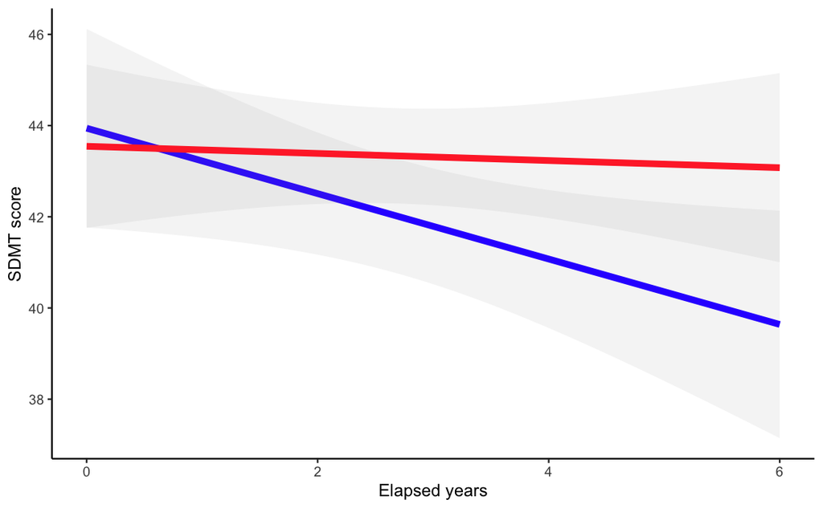

```r
d %>% filter(is.element(PATNO,d2$PATNO))->d4
d4 %>% filter(is.na(mean_PASE_Work_score_binary)==F) %>% ggplot(aes(x=Elapsed_months_2/12,y=SDMT_correct,colour=mean_PASE_Work_score_binary))+theme_classic()+stat_smooth(se=T,fullrange = T,level = 0.95,method=lm,alpha=0.1,size=2)+ylab("SDMT score")+xlab("Elapsed years")+scale_colour_discrete(labels=c("Below","Above"),name=expression(atop("Average PASE","total score")))+xlim(c(0,6))+scale_color_manual(values = c("#3232FF","#FF3232"))+ theme(legend.position = "none")
```

```r
a<-d4 %>% dplyr::select(Elapsed_months_2,Age,sum_PIGD_score,MSEADLG,mean_PASE_Work_score_binary,SDMT_correct,PATNO,Sex,LEDD_sum,Disease_duration_symptom)
c<-c()
p.value<-c()
Partner<-c()
Quantile<-c()
confint_sum<-c()
a$mean_PASE_Work_score_binary<-as.factor(a$mean_PASE_Work_score_binary)
for(i in colnames(a)){
  if((i!="Elapsed_months_2")&(i!="mean_PASE_Work_score_binary")&(i!="Age")&(i!="PATNO")&(i!="Sex")&(i!="LEDD_sum")&(i!="Disease_duration_symptom")){
    a %>% dplyr::select(i,Elapsed_months_2,mean_PASE_Work_score_binary,Age,PATNO,Sex,LEDD_sum,Disease_duration_symptom)->a1;
    colnames(a1)<-c("V1","Elapsed_months_2","mean_PASE_Work_score_categorize","Age","PATNO","Sex","LEDD_sum","Disease_duration_symptom");
    a1$V1<-scale(a1$V1,center=T,scale=T);
    a1$Age<-scale(a1$Age,center=T,scale=T);
    a1$Elapsed_months_2<-scale(a1$Elapsed_months_2,center=T,scale=T);
    a1$LEDD_sum<-scale(a1$LEDD_sum,center=T,scale=T);
    a1$Disease_duration_symptom<-scale(a1$Disease_duration_symptom,center=T,scale=T);
    with(a1,lmer(V1~Elapsed_months_2*mean_PASE_Work_score_categorize+Age+LEDD_sum+Disease_duration_symptom+Sex+(1+Elapsed_months_2|PATNO),REML=FALSE))->b;
    summary(b)->b.summary;confint(b,method="b",nsim=1000) %>% suppressMessages()->b.confint;
    b.summary$coefficients[8,]->d;
    bind_rows(c,d) %>% suppressMessages()->c;
    with(a1,lmer(V1~Elapsed_months_2+mean_PASE_Work_score_categorize+Age+LEDD_sum+Disease_duration_symptom+Sex+(1+Elapsed_months_2|PATNO),REML=FALSE))->b.null;
    anova(b,b.null)->d
    append(p.value,d$`Pr(>Chisq)`[2])->p.value;
    append(Partner,i)->Partner;
    confint_sum<-bind_rows(confint_sum,b.confint[10,]) %>% as_tibble()
  }}
cbind(Partner,confint_sum,p.value) %>% cbind(c)->interaction_effect_table_mean_PASE_Work_score_categorize_2

write_csv(interaction_effect_table_mean_PASE_Work_score_categorize_2,"interaction_effect_table_mean_PASE_Work_score_categorize_2.csv")
```

```r
##Household_median
d<-UPDRS_PASE_MOCA_ESS_MSEADL_RBDSQ_SCOPA_HVLT_JLO_LNS_SDMT_GDS_PD %>% filter(is.na(mean_PASE_Total_score)==F) %>% filter(Elapsed_months_2==0)

c<-c()
for(i in unique(UPDRS_PASE_MOCA_ESS_MSEADL_RBDSQ_SCOPA_HVLT_JLO_LNS_SDMT_GDS_PD$PATNO)){
  UPDRS_PASE_MOCA_ESS_MSEADL_RBDSQ_SCOPA_HVLT_JLO_LNS_SDMT_GDS_PD %>% filter(PATNO==i) -> a;
  if ((nrow(a)>=3)){
    if(mean(a$PASE_Household_score,na.rm = T)>=quantile(d$mean_PASE_Household_score,na.rm=T,0.75))(append(c,rep("50-100",nrow(a)))->c)else{
      if(mean(a$PASE_Household_score,na.rm = T)>=quantile(d$mean_PASE_Household_score,na.rm=T,0.5))(append(c,rep("50-100",nrow(a)))->c)else{
        if(mean(a$PASE_Household_score,na.rm = T)>=quantile(d$mean_PASE_Household_score,na.rm=T,0.25))(append(c,rep("0-50",nrow(a)))->c)else(append(c,rep("0-50",nrow(a)))->c)}}}
  else(append(c,rep(NA,nrow(a)))->c)
}
c->mean_PASE_Household_score_binary

d<-cbind(UPDRS_PASE_MOCA_ESS_MSEADL_RBDSQ_SCOPA_HVLT_JLO_LNS_SDMT_GDS_PD,mean_PASE_Household_score_binary)

d %>% filter(Elapsed_months_2==0) %>% filter(is.na(sum_UPDRS_part3)==F) %>% filter(is.na(mean_PASE_Household_score_binary)==F) ->d1
d1$mean_PASE_Household_score_binary<-as.factor(d1$mean_PASE_Household_score_binary)
d1$Sex<-as.factor(d1$Sex)
d1 %>% dplyr::select(PATNO,mean_PASE_Household_score_binary,Age,Sex,MOCA_Total_score,Disease_duration_symptom,sum_UPDRS_part3,sum_PIGD_score,LEDD_sum,MSEADLG,GDS_total_score,LNS_RAW,sum_Tremor_score,SDMT_correct,NHY,HVLT_DELAYED_RECALL_T,JLO_RAW,SCOPA_total_score) %>% na.omit() -> d1
MatchIt::matchit(mean_PASE_Household_score_binary ~ Age + Sex + MOCA_Total_score + Disease_duration_symptom + sum_UPDRS_part3 + sum_PIGD_score +LEDD_sum+MSEADLG+GDS_total_score+LNS_RAW+sum_Tremor_score+SDMT_correct+NHY+HVLT_DELAYED_RECALL_T+JLO_RAW+SCOPA_total_score, data=d1,  distance="logit", method = "nearest",replace=FALSE) %>% suppressMessages()->match.obj
d1$PS<-match.obj$distance
logitPS<-log(1/d1$PS-1)

MatchIt::matchit(mean_PASE_Household_score_binary ~ Age + Sex + MOCA_Total_score + Disease_duration_symptom + sum_UPDRS_part3 + sum_PIGD_score+LEDD_sum+MSEADLG+GDS_total_score+LNS_RAW+sum_Tremor_score+SDMT_correct+NHY+HVLT_DELAYED_RECALL_T+JLO_RAW+SCOPA_total_score, data=d1, distance="logit", method = "nearest",replace=FALSE,caliper =  0.2*sd(logitPS))->match.obj
d2<-match.data(match.obj)
d3 <- d %>% filter(Elapsed_months_2==0) %>% filter(is.element(PATNO,d2$PATNO))

Match_aft_SMD<-CreateTableOne(strata="mean_PASE_Household_score_binary",var=c("Age","Sex","Disease_duration_symptom","NHY","LEDD_sum","sum_UPDRS_part3","sum_Tremor_score","sum_PIGD_score","MOCA_Total_score","HVLT_DELAYED_RECALL_T","JLO_RAW","LNS_RAW","SDMT_correct","SCOPA_total_score","GDS_total_score", "ESS_total_score","RBDSQ_total_score","MSEADLG"),test=F,smd=T,data=d3) %>% print(smd=T)
```

```
                                      Stratified by mean_PASE_Household_score_binary
                                       0-50            50-100          SMD
  n                                        87              87
  Age (mean (SD))                       62.77 (9.13)    62.64 (10.26)   0.013
  Sex = Male (%)                           59 (67.8)       61 (70.1)    0.050
  Disease_duration_symptom (mean (SD))   3.70 (1.97)     3.93 (1.84)    0.121
  NHY (mean (SD))                        1.77 (0.47)     1.75 (0.55)    0.045
  LEDD_sum (mean (SD))                 217.26 (420.05) 208.71 (264.84)  0.024
  sum_UPDRS_part3 (mean (SD))           26.77 (10.83)   25.99 (11.40)   0.070
  sum_Tremor_score (mean (SD))           6.90 (4.27)     6.95 (4.53)    0.013
  sum_PIGD_score (mean (SD))             1.63 (1.46)     1.56 (1.29)    0.050
  MOCA_Total_score (mean (SD))          26.47 (2.38)    26.48 (2.46)    0.005
  HVLT_DELAYED_RECALL_T (mean (SD))     45.90 (12.31)   45.41 (10.91)   0.042
  JLO_RAW (mean (SD))                   25.72 (3.99)    25.79 (4.32)    0.017
  LNS_RAW (mean (SD))                   11.07 (2.59)    10.90 (2.69)    0.065
  SDMT_correct (mean (SD))              41.70 (9.39)    41.77 (9.32)    0.007
  SCOPA_total_score (mean (SD))         14.20 (8.39)    13.77 (10.30)   0.045
  GDS_total_score (mean (SD))            5.37 (1.50)     5.59 (1.39)    0.151
  ESS_total_score (mean (SD))            5.63 (3.61)     6.55 (4.21)    0.235
  RBDSQ_total_score (mean (SD))          5.05 (3.15)     5.46 (2.65)    0.142
  MSEADLG (mean (SD))                   89.37 (6.23)    89.66 (7.23)    0.043
```

```r
Match_aft_SMD<-Match_aft_SMD %>% as_tibble() %>% cbind(label=rownames(Match_aft_SMD)) %>% as_tibble() ;Match_aft_SMD<-Match_aft_SMD[-1,];Match_aft_SMD$SMD<-as.numeric(Match_aft_SMD$SMD) %>% suppressMessages()
d %>% filter(Elapsed_months_2==0) %>% filter(is.na(sum_UPDRS_part3)==F) %>% filter(is.na(mean_PASE_Household_score_binary)==F) ->d1
Match_bef_SMD<-CreateTableOne(strata="mean_PASE_Household_score_binary",var=c("Age","Sex","Disease_duration_symptom","NHY","LEDD_sum","sum_UPDRS_part3","sum_Tremor_score","sum_PIGD_score","MOCA_Total_score","HVLT_DELAYED_RECALL_T","JLO_RAW","LNS_RAW","SDMT_correct","SCOPA_total_score","GDS_total_score", "ESS_total_score","RBDSQ_total_score","MSEADLG"),test=F,smd=T,data=d1) %>% print(smd=T)
```

```
                                      Stratified by mean_PASE_Household_score_binary
                                       0-50            50-100          SMD
  n                                       118             119
  Age (mean (SD))                       64.62 (9.71)    61.35 (10.07)   0.330
  Sex = Male (%)                           76 (64.4)       88 (73.9)    0.208
  Disease_duration_symptom (mean (SD))   3.85 (2.55)     3.68 (1.72)    0.077
  NHY (mean (SD))                        1.81 (0.45)     1.74 (0.53)    0.151
  LEDD_sum (mean (SD))                 239.59 (426.88) 201.85 (261.50)  0.107
  sum_UPDRS_part3 (mean (SD))           28.40 (11.08)   24.55 (11.24)   0.345
  sum_Tremor_score (mean (SD))           6.60 (4.53)     6.61 (4.42)    0.001
  sum_PIGD_score (mean (SD))             1.86 (1.64)     1.40 (1.22)    0.320
  MOCA_Total_score (mean (SD))          25.69 (2.85)    26.88 (2.41)    0.450
  HVLT_DELAYED_RECALL_T (mean (SD))     44.19 (12.84)   46.18 (10.19)   0.172
  JLO_RAW (mean (SD))                   24.79 (5.02)    26.15 (4.04)    0.300
  LNS_RAW (mean (SD))                   10.59 (2.70)    10.81 (2.59)    0.081
  SDMT_correct (mean (SD))              39.13 (10.87)   42.91 (9.28)    0.374
  SCOPA_total_score (mean (SD))         16.26 (9.29)    12.76 (9.41)    0.375
  GDS_total_score (mean (SD))            5.46 (1.54)     5.41 (1.36)    0.034
  ESS_total_score (mean (SD))            6.36 (4.04)     6.34 (3.95)    0.005
  RBDSQ_total_score (mean (SD))          5.40 (3.23)     5.33 (2.65)    0.024
  MSEADLG (mean (SD))                   87.84 (7.32)    90.34 (7.00)    0.349
```

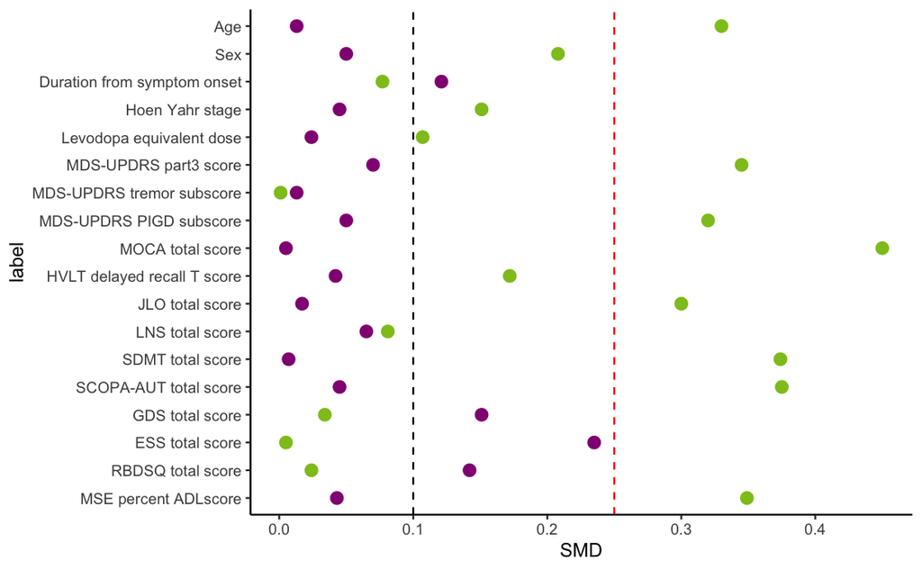

```r
Match_bef_SMD<-Match_bef_SMD %>% as_tibble() %>% cbind(label=rownames(Match_bef_SMD)) %>% as_tibble() ;Match_bef_SMD<-Match_bef_SMD[-1,];Match_bef_SMD$SMD<-as.numeric(Match_bef_SMD$SMD)
Match_SMD<-data.frame(label=Match_aft_SMD$label,BEF=Match_bef_SMD$SMD,AF=Match_aft_SMD$SMD);rm(Match_aft_SMD,Match_bef_SMD)
Match_SMD$label<-c("Age","Sex","Duration from symptom onset","Hoen Yahr stage","Levodopa equivalent dose","MDS-UPDRS part3 score","MDS-UPDRS tremor subscore","MDS-UPDRS PIGD subscore","MOCA total score","HVLT delayed recall T score","JLO total score","LNS total score","SDMT total score","SCOPA-AUT total score","GDS total score", "ESS total score","RBDSQ total score","MSE percent ADLscore")
Match_SMD$label<-factor(Match_SMD$label,level=rev(Match_SMD$label))
Match_SMD %>% tidyr::gather(key=PSM,value=SMD,BEF,AF) %>% ggplot(aes(x=SMD,y=label,colour=PSM)) + theme_classic() + geom_point(size=3) +scale_colour_discrete(name="",labels=c("After PSM","Before PSM"))+geom_vline(xintercept = 0.1,linetype="dashed", color = "black")  +geom_vline(xintercept = 0.25,linetype="dashed", color = "red") + scale_color_manual(values = c("#920783","#8FC31F"))+ theme(legend.position = "none")
```

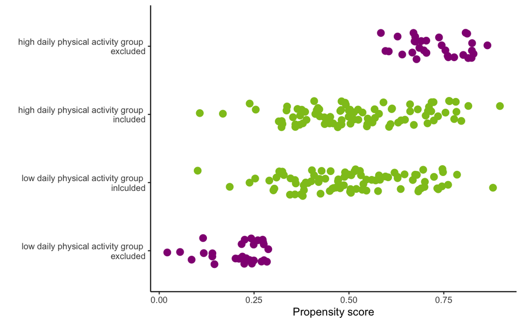

```r
Match_info <- data.frame(Match=match.obj$weights,Dichotomized=match.obj$treat,PS=match.obj$distance) %>% dplyr::mutate(Group=if_else(((Match==0)&(Dichotomized==1)),"above_discarded",if_else(((Match==0)&(Dichotomized==0)),"below_discarded",if_else(((Match==1)&(Dichotomized==1)),"above_adopted","below_adopted"))))  %>% as_tibble()
Match_info$Group<-factor(Match_info$Group,levels=c("below_discarded","below_adopted","above_adopted","above_discarded"))
Match_info$Match<-factor(Match_info$Match,levels=rev(unique(Match_info$Match)))
Match_info  %>% ggplot(aes(x=PS,y=Group,colour=Match)) + theme_classic() + geom_jitter(size=3,width=0.0,height=0.2)+scale_colour_discrete(name="",labels=c("After PSM","Before PSM"))+xlab("Propensity score")+scale_y_discrete(label=c("low daily physical activity group \n excluded","low daily physical activity group \n inlculded","high daily physical activity group \n included","high daily physical activity group \n excluded"))+ylab("")+ scale_color_manual(values = c("#920783","#8FC31F"),name="",label=c("",""))+ theme(legend.position = "none")
```

```r
d3<-d3 %>% dplyr::select(mean_PASE_Household_score_binary,Age,Sex,Disease_duration_symptom,NHY,LEDD_sum,sum_UPDRS_part3,sum_Tremor_score,sum_PIGD_score,MOCA_Total_score,HVLT_DELAYED_RECALL_T,JLO_RAW,LNS_RAW,SDMT_correct,SCOPA_total_score,GDS_total_score, ESS_total_score,RBDSQ_total_score,MSEADLG)
colnames(d3)<-c("mean PASE","Age","Sex","Duration from symptom onset","Hoen Yahr stage","Levodopa equivalent dose","MDS-UPDRS part3 score","MDS-UPDRS tremor subscore","MDS-UPDRS PIGD subscore","MOCA total score","HVLT delayed recall T score","JLO total score","LNS total score","SDMT total score","SCOPA-AUT total score","GDS total score", "ESS total score","RBDSQ total score","MSE percent ADLscore")
d3 %>% tbl_summary(by =`mean PASE`,type=list(`MDS-UPDRS PIGD subscore`~"continuous",`MSE percent ADLscore`~"continuous",`JLO total score`~"continuous",`Hoen Yahr stage`~"continuous",`Duration from symptom onset`~"continuous")) %>% add_p()
```

| **Characteristic** | **0-50**, N = 87<sup>1</sup> | **50-100**, N = 87<sup>1</sup> | **p-value**<sup>2</sup> |
| --- | --- | --- | --- |
| Age | 63 (58, 69) | 64 (55, 70) | 0.91 |
| Sex |  |  | 0.74 |
| Female | 28 (32%) | 26 (30%) |  |
| Male | 59 (68%) | 61 (70%) |  |
| Duration from symptom onset | 3.00 (3.00, 4.00) | 4.00 (3.00, 5.00) | 0.32 |
| Hoen Yahr stage | 2.00 (1.50, 2.00) | 2.00 (1.00, 2.00) | 0.67 |
| Levodopa equivalent dose | 100 (0, 272) | 150 (0, 300) | 0.36 |
| MDS-UPDRS part3 score | 25 (20, 34) | 24 (18, 34) | 0.49 |
| MDS-UPDRS tremor subscore | 7.0 (4.0, 10.0) | 7.0 (3.0, 11.0) | 0.97 |
| MDS-UPDRS PIGD subscore | 1.00 (1.00, 2.00) | 1.00 (1.00, 2.00) | 0.91 |
| MOCA total score | 27.00 (25.00, 28.00) | 26.00 (25.00, 29.00) | >0.99 |
| HVLT delayed recall T score | 48 (36, 56) | 47 (37, 54) | 0.64 |
| JLO total score | 26.0 (24.0, 28.0) | 28.0 (24.0, 30.0) | 0.70 |
| LNS total score | 11.00 (9.50, 12.50) | 11.00 (9.00, 13.00) | 0.59 |
| SDMT total score | 43 (36, 48) | 42 (36, 48) | 0.81 |
| SCOPA-AUT total score | 12 (9, 21) | 12 (6, 18) | 0.40 |
| GDS total score | 5.00 (5.00, 6.00) | 5.00 (5.00, 6.00) | 0.26 |
| ESS total score | 6.0 (3.0, 7.0) | 6.0 (4.0, 9.0) | 0.20 |
| RBDSQ total score | 4.00 (3.00, 6.00) | 5.00 (4.00, 7.00) | 0.069 |
| MSE percent ADLscore | 90 (88, 90) | 90 (88, 95) | 0.51 |

<sup>*1*</sup> Median (IQR); n (%) <sup>*2*</sup> Wilcoxon rank sum test; Pearson's Chi-squared test

```
 警告:  Removed 5 rows containing non-finite values (stat_smooth).
```

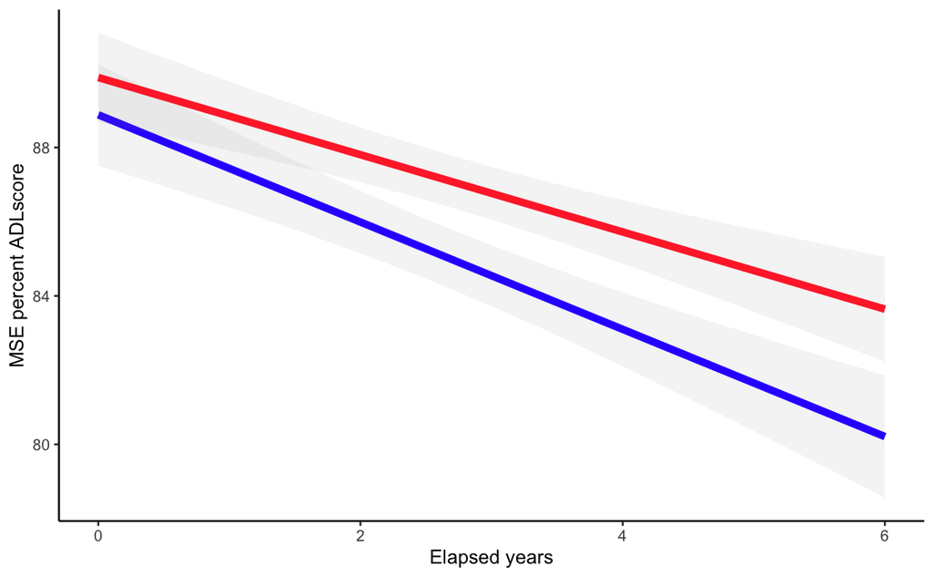

```r
d %>% filter(is.element(PATNO,d2$PATNO))->d4
d4 %>% filter(is.na(mean_PASE_Household_score_binary)==F) %>% ggplot(aes(x=Elapsed_months_2/12,y=MSEADLG,colour=mean_PASE_Household_score_binary))+theme_classic()+stat_smooth(se=T,fullrange = T,level = 0.95,method=lm,alpha=0.1,size=2)+ylab("MSE percent ADLscore")+xlab("Elapsed years")+scale_colour_discrete(labels=c("Below","Above"),name=expression(atop("Average PASE","total score")))+xlim(c(0,6))+scale_color_manual(values = c("#3232FF","#FF3232"))+ theme(legend.position = "none")
```

```r
a<-d4 %>% dplyr::select(Elapsed_months_2,Age,sum_PIGD_score,MSEADLG,mean_PASE_Household_score_binary,SDMT_correct,PATNO,Sex,LEDD_sum,Disease_duration_symptom)
c<-c()
p.value<-c()
Partner<-c()
Quantile<-c()
confint_sum<-c()
a$mean_PASE_Household_score_binary<-as.factor(a$mean_PASE_Household_score_binary)
for(i in colnames(a)){
  if((i!="Elapsed_months_2")&(i!="mean_PASE_Household_score_binary")&(i!="Age")&(i!="PATNO")&(i!="Sex")&(i!="LEDD_sum")&(i!="Disease_duration_symptom")){
    a %>% dplyr::select(i,Elapsed_months_2,mean_PASE_Household_score_binary,Age,PATNO,Sex,LEDD_sum,Disease_duration_symptom)->a1;
    colnames(a1)<-c("V1","Elapsed_months_2","mean_PASE_Household_score_categorize","Age","PATNO","Sex","LEDD_sum","Disease_duration_symptom");
    a1$V1<-scale(a1$V1,center=T,scale=T);
    a1$Age<-scale(a1$Age,center=T,scale=T);
    a1$Elapsed_months_2<-scale(a1$Elapsed_months_2,center=T,scale=T);
    a1$LEDD_sum<-scale(a1$LEDD_sum,center=T,scale=T);
    a1$Disease_duration_symptom<-scale(a1$Disease_duration_symptom,center=T,scale=T);
    with(a1,lmer(V1~Elapsed_months_2*mean_PASE_Household_score_categorize+Age+LEDD_sum+Disease_duration_symptom+Sex+(1+Elapsed_months_2|PATNO),REML=FALSE))->b;
    summary(b)->b.summary;confint(b,method="b",nsim=1000) %>% suppressMessages()->b.confint;
    b.summary$coefficients[8,]->d;
    bind_rows(c,d) %>% suppressMessages()->c;
    with(a1,lmer(V1~Elapsed_months_2+mean_PASE_Household_score_categorize+Age+LEDD_sum+Disease_duration_symptom+Sex+(1+Elapsed_months_2|PATNO),REML=FALSE))->b.null;
    anova(b,b.null)->d
    append(p.value,d$`Pr(>Chisq)`[2])->p.value;
    append(Partner,i)->Partner;
    confint_sum<-bind_rows(confint_sum,b.confint[10,]) %>% as_tibble()
  }}
cbind(Partner,confint_sum,p.value) %>% cbind(c)->interaction_effect_table_mean_PASE_Household_score_categorize
write_csv(interaction_effect_table_mean_PASE_Household_score_categorize,"interaction_effect_table_mean_PASE_Household_score_categorize.csv")
```

## Sensitivity analysis (2): Missing data imputation

The following code describes the sensitivity analyses after missing data imputation. The following csvs are obtained: **“imp_mean_PASE_Total_score.csv”**, **“imp_mean_PASE_Household_score.csv”**, **“imp_mean_PASE_Work_score.csv”**, **“imp_mean_PASE_Leisure_score.csv”**, **“imp_mean_AE.csv”**.

```r
UPDRS_PASE_MOCA_ESS_MSEADL_RBDSQ_SCOPA_HVLT_JLO_LNS_SDMT_GDS_PD_2<-UPDRS_PASE_MOCA_ESS_MSEADL_RBDSQ_SCOPA_HVLT_JLO_LNS_SDMT_GDS %>% filter(Group=="PD")
imp<-UPDRS_PASE_MOCA_ESS_MSEADL_RBDSQ_SCOPA_HVLT_JLO_LNS_SDMT_GDS_PD_2 %>% dplyr::select(PATNO,Sex,Elapsed_months_2,Age,LEDD_sum,sum_UPDRS_part3,sum_Tremor_score,sum_PIGD_score,MOCA_Total_score,HVLT_DELAYED_RECALL_T,JLO_RAW,LNS_RAW,SDMT_correct,SCOPA_total_score,GDS_total_score, ESS_total_score,RBDSQ_total_score,MSEADLG,Disease_duration_symptom)

IDS <- c("PATNO","Elapsed_months_2")
varIndex <- colnames(imp)

impute.out <- amelia(as.data.frame(imp[, varIndex]), idvars = IDS,noms = c("Sex"),m = 100)
names(impute.out$imputations)<-c(1:100)

Partner<-c()
c<-c()
imp_num<-c()
for(s in seq(1,100)){
  a<-impute.out$imputations[s] %>% as.data.frame();colnames(a)<-colnames(imp);
  a<-cbind(a,mean_PASE_Total_score) %>% as_tibble() %>% na.omit();
  a %>% dplyr::select(PATNO,Sex,Elapsed_months_2,mean_PASE_Total_score,Age,LEDD_sum,sum_UPDRS_part3,sum_Tremor_score,sum_PIGD_score,MOCA_Total_score,HVLT_DELAYED_RECALL_T,JLO_RAW,LNS_RAW,SDMT_correct,SCOPA_total_score,GDS_total_score, ESS_total_score,RBDSQ_total_score,MSEADLG,Disease_duration_symptom)
  for(i in colnames(a)){
    if((i!="Elapsed_months_2")&(i!="mean_PASE_Total_score")&(i!="Age")&(i!="PATNO")&(i!="LEDD_sum")&(i!="Disease_duration_symptom")&(i!="Sex")){
      a %>% dplyr::select(i,Elapsed_months_2,mean_PASE_Total_score,Age,PATNO,LEDD_sum,Disease_duration_symptom,Sex)->a1;
      colnames(a1)<-c("V1","Elapsed_months_2","mean_PASE_Total_score","Age","PATNO","LEDD_sum","Disease_duration_symptom","Sex");
      a1$V1<-scale(a1$V1,center=T,scale=T);
      a1$mean_PASE_Total_score<-scale(a1$mean_PASE_Total_score,center=T,scale=T);
      a1$Age<-scale(a1$Age,center=T,scale=T);
      a1$Elapsed_months_2<-scale(a1$Elapsed_months_2,center=T,scale=T);
      a1$LEDD_sum<-scale(a1$LEDD_sum,center=T,scale=T);
      a1$Disease_duration_symptom<-scale(a1$Disease_duration_symptom,center=T,scale=T);
      with(a1,lmer(V1~Elapsed_months_2*mean_PASE_Total_score+Age+LEDD_sum+Disease_duration_symptom+Sex+(1+Elapsed_months_2|PATNO),REML=FALSE))->b;
      summary(b)->b.summary;confint(b,method="b",nsim=1000) %>% suppressMessages()->b.confint;b.confint[10,]->f;
      b.summary$coefficients[8,]->e;
      c(e[1],e[2],f[1],f[2])->d;
      bind_rows(c,d)->c;
      append(Partner,i)->Partner;
      imp_num<-append(imp_num,s)
    }}
}

imp_mean_PASE_Total_score<-cbind(imp_num,Partner,c)

estimate_lowconf<-c();estimate_highconf<-c();Partner_conf<-c();estimate_mean<-c();CI_low_mean<-c();CI_low_lowconf<-c();CI_low_highconf<-c();CI_high_mean<-c();CI_high_lowconf<-c();CI_high_highconf<-c()
for (i in unique(Partner)){
  imp_mean_PASE_Total_score %>% dplyr::filter(Partner==i) ->a;estimate_mean<-append(estimate_mean,mean(a$Estimate));CI_high_mean<-append(CI_high_mean,mean(a$`97.5 %`));CI_low_mean<-append(CI_low_mean,mean(a$`2.5 %`))
  t.test(a$Estimate)->b;b$conf.int->b;estimate_lowconf<-append(estimate_lowconf,b[1]);estimate_highconf<-append(estimate_highconf,b[2]);Partner_conf<-append(Partner_conf,i);t.test(a$`2.5 %`)->b;b$conf.int->b;CI_low_lowconf<-append(CI_low_lowconf,b[1]);CI_low_highconf<-append(CI_low_highconf,b[2]);t.test(a$`97.5 %`)->b;b$conf.int->b;CI_high_lowconf<-append(CI_high_lowconf,b[1]);CI_high_highconf<-append(CI_high_highconf,b[2])
}

imp_mean_PASE_Total_score<-data.frame(Partner=Partner_conf,`mean_PASE_Total_estimate_mean`=estimate_mean,`mean_PASE_Total_estimate_95%CI_low`=estimate_lowconf,`mean_PASE_Total_estimate_95%CI_high`=estimate_highconf,`mean_PASE_Total_CI_low_mean`=CI_low_mean,`mean_PASE_Total_CI_low_95%CI_low`=CI_low_lowconf,`mean_PASE_Total_CI_low_95%CI_high`=CI_low_highconf,`mean_PASE_Total_CI_high_mean`=CI_high_mean,`mean_PASE_Total_CI_high_95%CI_low`=CI_high_lowconf,`mean_PASE_Total_CI_high_95%CI_high`=CI_high_highconf)
imp_mean_PASE_Total_score<-interaction_effect_table_mean_final %>% dplyr::filter(class=="mean_PASE_Total_score") %>% dplyr::select(Partner,Estimate,`2.5 %`,`97.5 %`) %>% dplyr::left_join(imp_mean_PASE_Total_score,by = "Partner")


Partner<-c()
c<-c()
imp_num<-c()
for(s in seq(1,100)){
  a<-impute.out$imputations[s] %>% as.data.frame();colnames(a)<-colnames(imp);
  a<-cbind(a,mean_AE) %>% as_tibble() %>% na.omit();
  a %>% dplyr::select(PATNO,Sex,Elapsed_months_2,mean_AE,Age,LEDD_sum,sum_UPDRS_part3,sum_Tremor_score,sum_PIGD_score,MOCA_Total_score,HVLT_DELAYED_RECALL_T,JLO_RAW,LNS_RAW,SDMT_correct,SCOPA_total_score,GDS_total_score, ESS_total_score,RBDSQ_total_score,MSEADLG,Disease_duration_symptom)
  for(i in colnames(a)){
    if((i!="Elapsed_months_2")&(i!="mean_AE")&(i!="Age")&(i!="PATNO")&(i!="LEDD_sum")&(i!="Disease_duration_symptom")&(i!="Sex")){
      a %>% dplyr::select(i,Elapsed_months_2,mean_AE,Age,PATNO,LEDD_sum,Disease_duration_symptom,Sex)->a1;
      colnames(a1)<-c("V1","Elapsed_months_2","mean_AE","Age","PATNO","LEDD_sum","Disease_duration_symptom","Sex");
      a1$V1<-scale(a1$V1,center=T,scale=T);
      a1$mean_AE<-scale(a1$mean_AE,center=T,scale=T);
      a1$Age<-scale(a1$Age,center=T,scale=T);
      a1$Elapsed_months_2<-scale(a1$Elapsed_months_2,center=T,scale=T);
      a1$LEDD_sum<-scale(a1$LEDD_sum,center=T,scale=T);
      a1$Disease_duration_symptom<-scale(a1$Disease_duration_symptom,center=T,scale=T);
      with(a1,lmer(V1~Elapsed_months_2*mean_AE+Age+LEDD_sum+Disease_duration_symptom+Sex+(1+Elapsed_months_2|PATNO),REML=FALSE))->b;
      summary(b)->b.summary;confint(b,method="b",nsim=1000) %>% suppressMessages()->b.confint;b.confint[10,]->f;
      b.summary$coefficients[8,]->e;
      c(e[1],e[2],f[1],f[2])->d;
      bind_rows(c,d)->c;
      append(Partner,i)->Partner;
      imp_num<-append(imp_num,s)
    }}
}

imp_mean_AE<-cbind(imp_num,Partner,c)

estimate_lowconf<-c();estimate_highconf<-c();Partner_conf<-c();estimate_mean<-c();CI_low_mean<-c();CI_low_lowconf<-c();CI_low_highconf<-c();CI_high_mean<-c();CI_high_lowconf<-c();CI_high_highconf<-c()
for (i in unique(Partner)){
  imp_mean_AE %>% dplyr::filter(Partner==i) ->a;estimate_mean<-append(estimate_mean,mean(a$Estimate));CI_high_mean<-append(CI_high_mean,mean(a$`97.5 %`));CI_low_mean<-append(CI_low_mean,mean(a$`2.5 %`))
  t.test(a$Estimate)->b;b$conf.int->b;estimate_lowconf<-append(estimate_lowconf,b[1]);estimate_highconf<-append(estimate_highconf,b[2]);Partner_conf<-append(Partner_conf,i);t.test(a$`2.5 %`)->b;b$conf.int->b;CI_low_lowconf<-append(CI_low_lowconf,b[1]);CI_low_highconf<-append(CI_low_highconf,b[2]);t.test(a$`97.5 %`)->b;b$conf.int->b;CI_high_lowconf<-append(CI_high_lowconf,b[1]);CI_high_highconf<-append(CI_high_highconf,b[2])
}
```

```r
imp_mean_AE<-data.frame(Partner=Partner_conf,`mean_AE_estimate_mean`=estimate_mean,`mean_AE_estimate_95%CI_low`=estimate_lowconf,`mean_AE_estimate_95%CI_high`=estimate_highconf,`mean_AE_CI_low_mean`=CI_low_mean,`mean_AE_CI_low_95%CI_low`=CI_low_lowconf,`mean_AE_CI_low_95%CI_high`=CI_low_highconf,`mean_AE_CI_high_mean`=CI_high_mean,`mean_AE_CI_high_95%CI_low`=CI_high_lowconf,`mean_AE_CI_high_95%CI_high`=CI_high_highconf)
imp_mean_AE<-interaction_effect_table_mean_final %>% dplyr::filter(class=="mean_AE") %>% dplyr::select(Partner,Estimate,`2.5 %`,`97.5 %`) %>% dplyr::left_join(imp_mean_AE,by = "Partner")



Partner<-c()
c<-c()
imp_num<-c()

for(s in seq(1,100)){
  a<-impute.out$imputations[s] %>% as.data.frame();colnames(a)<-colnames(imp);
  a<-cbind(a,mean_PASE_Household_score) %>% as_tibble() %>% na.omit();
  a %>% dplyr::select(PATNO,Sex,Elapsed_months_2,mean_PASE_Household_score,Age,LEDD_sum,sum_UPDRS_part3,sum_Tremor_score,sum_PIGD_score,MOCA_Total_score,HVLT_DELAYED_RECALL_T,JLO_RAW,LNS_RAW,SDMT_correct,SCOPA_total_score,GDS_total_score, ESS_total_score,RBDSQ_total_score,MSEADLG,Disease_duration_symptom)
  for(i in colnames(a)){
    if((i!="Elapsed_months_2")&(i!="mean_PASE_Household_score")&(i!="Age")&(i!="PATNO")&(i!="LEDD_sum")&(i!="Disease_duration_symptom")&(i!="Sex")){
      a %>% dplyr::select(i,Elapsed_months_2,mean_PASE_Household_score,Age,PATNO,LEDD_sum,Disease_duration_symptom,Sex)->a1;
      colnames(a1)<-c("V1","Elapsed_months_2","mean_PASE_Household_score","Age","PATNO","LEDD_sum","Disease_duration_symptom","Sex");
      a1$V1<-scale(a1$V1,center=T,scale=T);
      a1$mean_PASE_Household_score<-scale(a1$mean_PASE_Household_score,center=T,scale=T);
      a1$Age<-scale(a1$Age,center=T,scale=T);
      a1$Elapsed_months_2<-scale(a1$Elapsed_months_2,center=T,scale=T);
      a1$LEDD_sum<-scale(a1$LEDD_sum,center=T,scale=T);
      a1$Disease_duration_symptom<-scale(a1$Disease_duration_symptom,center=T,scale=T);
      with(a1,lmer(V1~Elapsed_months_2*mean_PASE_Household_score+Age+LEDD_sum+Disease_duration_symptom+Sex+(1+Elapsed_months_2|PATNO),REML=FALSE))->b;
      summary(b)->b.summary;confint(b,method="b",nsim=1000) %>% suppressMessages()->b.confint;b.confint[10,]->f;
      b.summary$coefficients[8,]->e;
      c(e[1],e[2],f[1],f[2])->d;
      bind_rows(c,d)->c;
      append(Partner,i)->Partner;
      imp_num<-append(imp_num,s)
    }}
}

imp_mean_PASE_Household_score<-cbind(imp_num,Partner,c)

estimate_lowconf<-c();estimate_highconf<-c();Partner_conf<-c();estimate_mean<-c();CI_low_mean<-c();CI_low_lowconf<-c();CI_low_highconf<-c();CI_high_mean<-c();CI_high_lowconf<-c();CI_high_highconf<-c()
for (i in unique(Partner)){
  imp_mean_PASE_Household_score %>% dplyr::filter(Partner==i) ->a;estimate_mean<-append(estimate_mean,mean(a$Estimate));CI_high_mean<-append(CI_high_mean,mean(a$`97.5 %`));CI_low_mean<-append(CI_low_mean,mean(a$`2.5 %`))
  t.test(a$Estimate)->b;b$conf.int->b;estimate_lowconf<-append(estimate_lowconf,b[1]);estimate_highconf<-append(estimate_highconf,b[2]);Partner_conf<-append(Partner_conf,i);t.test(a$`2.5 %`)->b;b$conf.int->b;CI_low_lowconf<-append(CI_low_lowconf,b[1]);CI_low_highconf<-append(CI_low_highconf,b[2]);t.test(a$`97.5 %`)->b;b$conf.int->b;CI_high_lowconf<-append(CI_high_lowconf,b[1]);CI_high_highconf<-append(CI_high_highconf,b[2])
}

imp_mean_PASE_Household_score<-data.frame(Partner=Partner_conf,`mean_PASE_Household_estimate_mean`=estimate_mean,`mean_PASE_Household_estimate_95%CI_low`=estimate_lowconf,`mean_PASE_Household_estimate_95%CI_high`=estimate_highconf,`mean_PASE_Household_CI_low_mean`=CI_low_mean,`mean_PASE_Household_CI_low_95%CI_low`=CI_low_lowconf,`mean_PASE_Household_CI_low_95%CI_high`=CI_low_highconf,`mean_PASE_Household_CI_high_mean`=CI_high_mean,`mean_PASE_Household_CI_high_95%CI_low`=CI_high_lowconf,`mean_PASE_Household_CI_high_95%CI_high`=CI_high_highconf)
imp_mean_PASE_Household_score<-interaction_effect_table_mean_final %>% dplyr::filter(class=="mean_PASE_Household_score") %>% dplyr::select(Partner,Estimate,`2.5 %`,`97.5 %`) %>% dplyr::left_join(imp_mean_PASE_Household_score,by = "Partner")



Partner<-c()
c<-c()
imp_num<-c()

for(s in seq(1,100)){
  a<-impute.out$imputations[s] %>% as.data.frame();colnames(a)<-colnames(imp);
  a<-cbind(a,mean_PASE_Work_score) %>% as_tibble() %>% na.omit();
  a %>% dplyr::select(PATNO,Sex,Elapsed_months_2,mean_PASE_Work_score,Age,LEDD_sum,sum_UPDRS_part3,sum_Tremor_score,sum_PIGD_score,MOCA_Total_score,HVLT_DELAYED_RECALL_T,JLO_RAW,LNS_RAW,SDMT_correct,SCOPA_total_score,GDS_total_score, ESS_total_score,RBDSQ_total_score,MSEADLG,Disease_duration_symptom)
  for(i in colnames(a)){
    if((i!="Elapsed_months_2")&(i!="mean_PASE_Work_score")&(i!="Age")&(i!="PATNO")&(i!="LEDD_sum")&(i!="Disease_duration_symptom")&(i!="Sex")){
      a %>% dplyr::select(i,Elapsed_months_2,mean_PASE_Work_score,Age,PATNO,LEDD_sum,Disease_duration_symptom,Sex)->a1;
      colnames(a1)<-c("V1","Elapsed_months_2","mean_PASE_Work_score","Age","PATNO","LEDD_sum","Disease_duration_symptom","Sex");
      a1$V1<-scale(a1$V1,center=T,scale=T);
      a1$mean_PASE_Work_score<-scale(a1$mean_PASE_Work_score,center=T,scale=T);
      a1$Age<-scale(a1$Age,center=T,scale=T);
      a1$Elapsed_months_2<-scale(a1$Elapsed_months_2,center=T,scale=T);
      a1$LEDD_sum<-scale(a1$LEDD_sum,center=T,scale=T);
      a1$Disease_duration_symptom<-scale(a1$Disease_duration_symptom,center=T,scale=T);
      with(a1,lmer(V1~Elapsed_months_2*mean_PASE_Work_score+Age+LEDD_sum+Disease_duration_symptom+Sex+(1+Elapsed_months_2|PATNO),REML=FALSE))->b;
      summary(b)->b.summary;confint(b,method="b",nsim=1000) %>% suppressMessages()->b.confint;b.confint[10,]->f;
      b.summary$coefficients[8,]->e;
      c(e[1],e[2],f[1],f[2])->d;
      bind_rows(c,d)->c;
      append(Partner,i)->Partner;
      imp_num<-append(imp_num,s)
    }}
}

imp_mean_PASE_Work_score<-cbind(imp_num,Partner,c)

estimate_lowconf<-c();estimate_highconf<-c();Partner_conf<-c();estimate_mean<-c();CI_low_mean<-c();CI_low_lowconf<-c();CI_low_highconf<-c();CI_high_mean<-c();CI_high_lowconf<-c();CI_high_highconf<-c()
for (i in unique(Partner)){
  imp_mean_PASE_Work_score %>% dplyr::filter(Partner==i) ->a;estimate_mean<-append(estimate_mean,mean(a$Estimate));CI_high_mean<-append(CI_high_mean,mean(a$`97.5 %`));CI_low_mean<-append(CI_low_mean,mean(a$`2.5 %`))
  t.test(a$Estimate)->b;b$conf.int->b;estimate_lowconf<-append(estimate_lowconf,b[1]);estimate_highconf<-append(estimate_highconf,b[2]);Partner_conf<-append(Partner_conf,i);t.test(a$`2.5 %`)->b;b$conf.int->b;CI_low_lowconf<-append(CI_low_lowconf,b[1]);CI_low_highconf<-append(CI_low_highconf,b[2]);t.test(a$`97.5 %`)->b;b$conf.int->b;CI_high_lowconf<-append(CI_high_lowconf,b[1]);CI_high_highconf<-append(CI_high_highconf,b[2])
}
```

```r
imp_mean_PASE_Work_score<-data.frame(Partner=Partner_conf,`mean_PASE_Work_estimate_mean`=estimate_mean,`mean_PASE_Work_estimate_95%CI_low`=estimate_lowconf,`mean_PASE_Work_estimate_95%CI_high`=estimate_highconf,`mean_PASE_Work_CI_low_mean`=CI_low_mean,`mean_PASE_Work_CI_low_95%CI_low`=CI_low_lowconf,`mean_PASE_Work_CI_low_95%CI_high`=CI_low_highconf,`mean_PASE_Work_CI_high_mean`=CI_high_mean,`mean_PASE_Work_CI_high_95%CI_low`=CI_high_lowconf,`mean_PASE_Work_CI_high_95%CI_high`=CI_high_highconf)
imp_mean_PASE_Work_score<-interaction_effect_table_mean_final %>% dplyr::filter(class=="mean_PASE_Work_score") %>% dplyr::select(Partner,Estimate,`2.5 %`,`97.5 %`) %>% dplyr::left_join(imp_mean_PASE_Work_score,by = "Partner")




Partner<-c()
c<-c()
imp_num<-c()

for(s in seq(1,100)){
  a<-impute.out$imputations[s] %>% as.data.frame();colnames(a)<-colnames(imp);
  a<-cbind(a,mean_PASE_Leisure_score) %>% as_tibble() %>% na.omit();
  a %>% dplyr::select(PATNO,Sex,Elapsed_months_2,mean_PASE_Leisure_score,Age,LEDD_sum,sum_UPDRS_part3,sum_Tremor_score,sum_PIGD_score,MOCA_Total_score,HVLT_DELAYED_RECALL_T,JLO_RAW,LNS_RAW,SDMT_correct,SCOPA_total_score,GDS_total_score, ESS_total_score,RBDSQ_total_score,MSEADLG,Disease_duration_symptom)
  for(i in colnames(a)){
    if((i!="Elapsed_months_2")&(i!="mean_PASE_Leisure_score")&(i!="Age")&(i!="PATNO")&(i!="LEDD_sum")&(i!="Disease_duration_symptom")&(i!="Sex")){
      a %>% dplyr::select(i,Elapsed_months_2,mean_PASE_Leisure_score,Age,PATNO,LEDD_sum,Disease_duration_symptom,Sex)->a1;
      colnames(a1)<-c("V1","Elapsed_months_2","mean_PASE_Leisure_score","Age","PATNO","LEDD_sum","Disease_duration_symptom","Sex");
      a1$V1<-scale(a1$V1,center=T,scale=T);
      a1$mean_PASE_Leisure_score<-scale(a1$mean_PASE_Leisure_score,center=T,scale=T);
      a1$Age<-scale(a1$Age,center=T,scale=T);
      a1$Elapsed_months_2<-scale(a1$Elapsed_months_2,center=T,scale=T);
      a1$LEDD_sum<-scale(a1$LEDD_sum,center=T,scale=T);
      a1$Disease_duration_symptom<-scale(a1$Disease_duration_symptom,center=T,scale=T);
      with(a1,lmer(V1~Elapsed_months_2*mean_PASE_Leisure_score+Age+LEDD_sum+Disease_duration_symptom+Sex+(1+Elapsed_months_2|PATNO),REML=FALSE))->b;
      summary(b)->b.summary;confint(b,method="b",nsim=1000) %>% suppressMessages()->b.confint;b.confint[10,]->f;
      b.summary$coefficients[8,]->e;
      c(e[1],e[2],f[1],f[2])->d;
      bind_rows(c,d)->c;
      append(Partner,i)->Partner;
      imp_num<-append(imp_num,s)
    }}
}

imp_mean_PASE_Leisure_score<-cbind(imp_num,Partner,c)

estimate_lowconf<-c();estimate_highconf<-c();Partner_conf<-c();estimate_mean<-c();CI_low_mean<-c();CI_low_lowconf<-c();CI_low_highconf<-c();CI_high_mean<-c();CI_high_lowconf<-c();CI_high_highconf<-c()
for (i in unique(Partner)){
  imp_mean_PASE_Leisure_score %>% dplyr::filter(Partner==i) ->a;estimate_mean<-append(estimate_mean,mean(a$Estimate));CI_high_mean<-append(CI_high_mean,mean(a$`97.5 %`));CI_low_mean<-append(CI_low_mean,mean(a$`2.5 %`))
  t.test(a$Estimate)->b;b$conf.int->b;estimate_lowconf<-append(estimate_lowconf,b[1]);estimate_highconf<-append(estimate_highconf,b[2]);Partner_conf<-append(Partner_conf,i);t.test(a$`2.5 %`)->b;b$conf.int->b;CI_low_lowconf<-append(CI_low_lowconf,b[1]);CI_low_highconf<-append(CI_low_highconf,b[2]);t.test(a$`97.5 %`)->b;b$conf.int->b;CI_high_lowconf<-append(CI_high_lowconf,b[1]);CI_high_highconf<-append(CI_high_highconf,b[2])
}

imp_mean_PASE_Leisure_score<-data.frame(Partner=Partner_conf,`mean_PASE_Leisure_estimate_mean`=estimate_mean,`mean_PASE_Leisure_estimate_95%CI_low`=estimate_lowconf,`mean_PASE_Leisure_estimate_95%CI_high`=estimate_highconf,`mean_PASE_Leisure_CI_low_mean`=CI_low_mean,`mean_PASE_Leisure_CI_low_95%CI_low`=CI_low_lowconf,`mean_PASE_Leisure_CI_low_95%CI_high`=CI_low_highconf,`mean_PASE_Leisure_CI_high_mean`=CI_high_mean,`mean_PASE_Leisure_CI_high_95%CI_low`=CI_high_lowconf,`mean_PASE_Leisure_CI_high_95%CI_high`=CI_high_highconf)
imp_mean_PASE_Leisure_score<-interaction_effect_table_mean_final %>% dplyr::filter(class=="mean_PASE_Leisure_score") %>% dplyr::select(Partner,Estimate,`2.5 %`,`97.5 %`) %>% dplyr::left_join(imp_mean_PASE_Leisure_score,by = "Partner")

write_csv(imp_mean_PASE_Total_score,"imp_mean_PASE_Total_score.csv")
write_csv(imp_mean_PASE_Household_score,"imp_mean_PASE_Household_score.csv")
write_csv(imp_mean_PASE_Work_score,"imp_mean_PASE_Work_score.csv")
write_csv(imp_mean_PASE_Leisure_score,"imp_mean_PASE_Leisure_score.csv")
write_csv(imp_mean_AE,"imp_mean_AE.csv")
```